# Richter's Predictor: Modeling Earthquake Damage

#### `height_percentage`

**Description:** Normalized height of the building footprint. *(int)*

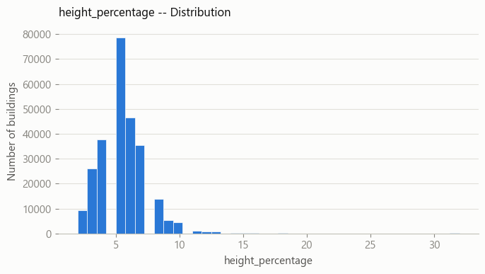

```python
fig, ax = plt.subplots(figsize=(7, 4))
ax.hist(train_values["height_percentage"], bins=40, color=CAT["blue"], edgecolor=SURFACE, linewidth=0.5)
ax.set_title("height_percentage -- Distribution", color=INK_PRIMARY, fontsize=12, loc="left", pad=12)
ax.set_xlabel("height_percentage")
ax.set_ylabel("Number of buildings")
style_ax(ax)
ax.grid(axis="x", visible=False)
plt.tight_layout()
plt.savefig(OUT / "value_counts_height_percentage.png", dpi=150)
plt.show()
```

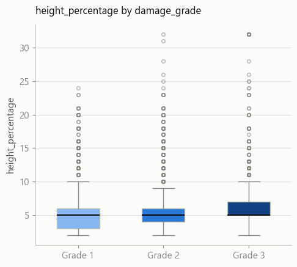

```python
data_by_grade = [df.loc[df[TARGET_COL] == g, "height_percentage"].values for g in [1, 2, 3]]
fig, ax = plt.subplots(figsize=(5, 4.5))
bp = ax.boxplot(data_by_grade, vert=True, widths=0.5, patch_artist=True, showfliers=True,
                 flierprops=dict(marker="o", markersize=4, markerfacecolor="none", markeredgecolor=INK_MUTED, alpha=0.6),
                 medianprops=dict(color=INK_PRIMARY, linewidth=1.5),
                 whiskerprops=dict(color=INK_MUTED),
                 capprops=dict(color=INK_MUTED))
for patch, grade in zip(bp["boxes"], [1, 2, 3]):
    patch.set_facecolor(GRADE_COLORS[grade])
    patch.set_edgecolor(BASELINE)
ax.set_xticks([1, 2, 3])
ax.set_xticklabels(["Grade 1", "Grade 2", "Grade 3"])
ax.set_ylabel("height_percentage")
ax.set_title("height_percentage by damage_grade", color=INK_PRIMARY, fontsize=12, loc="left", pad=12)
style_ax(ax, hide_spines=("top", "right"))
ax.grid(axis="x", visible=False)
plt.tight_layout()
plt.savefig(OUT / "damage_by_height_percentage_box.png", dpi=160)
plt.show()
```

**Interpretation:** Height percentage shows the same pattern as floor count -- medians look similar but the interquartile range shifts upward with damage severity (grade 3's IQR reaches 5-7 vs. grade 1's 3-6). Relatively taller buildings are mildly more vulnerable, consistent with the weak positive correlation (+0.048) seen earlier.

#### `count_families`

**Description:** Number of families that live in the building. *(int)*

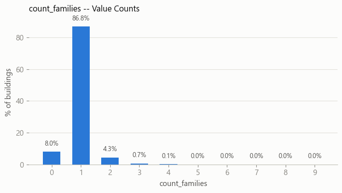

```python
vc = train_values["count_families"].value_counts().sort_index()
pct = vc / vc.sum() * 100
fig, ax = plt.subplots(figsize=(7, 4))
bars = ax.bar(pct.index.astype(str), pct.values, color=CAT["blue"], width=0.6)
bar_labels(ax, bars, fmt="{:.1f}%")
ax.set_title("count_families -- Value Counts", color=INK_PRIMARY, fontsize=12, loc="left", pad=12)
ax.set_xlabel("count_families")
ax.set_ylabel("% of buildings")
style_ax(ax)
ax.grid(axis="x", visible=False)
plt.tight_layout()
plt.savefig(OUT / "value_counts_count_families.png", dpi=150)
plt.show()
```

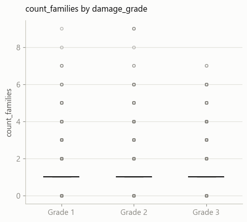

```python
data_by_grade = [df.loc[df[TARGET_COL] == g, "count_families"].values for g in [1, 2, 3]]
fig, ax = plt.subplots(figsize=(5, 4.5))
bp = ax.boxplot(data_by_grade, vert=True, widths=0.5, patch_artist=True, showfliers=True,
                 flierprops=dict(marker="o", markersize=4, markerfacecolor="none", markeredgecolor=INK_MUTED, alpha=0.6),
                 medianprops=dict(color=INK_PRIMARY, linewidth=1.5),
                 whiskerprops=dict(color=INK_MUTED),
                 capprops=dict(color=INK_MUTED))
for patch, grade in zip(bp["boxes"], [1, 2, 3]):
    patch.set_facecolor(GRADE_COLORS[grade])
    patch.set_edgecolor(BASELINE)
ax.set_xticks([1, 2, 3])
ax.set_xticklabels(["Grade 1", "Grade 2", "Grade 3"])
ax.set_ylabel("count_families")
ax.set_title("count_families by damage_grade", color=INK_PRIMARY, fontsize=12, loc="left", pad=12)
style_ax(ax, hide_spines=("top", "right"))
ax.grid(axis="x", visible=False)
plt.tight_layout()
plt.savefig(OUT / "damage_by_count_families_box.png", dpi=160)
plt.show()
```

**Interpretation:** `count_families` is nearly constant across all three grades (median 1 family in every group, mean drifting only from 0.92 to 1.01). This feature carries almost no standalone signal for damage grade, consistent with its near-zero correlation (+0.056) computed earlier.

#### Relationship between Superstructure Material Prevalence and Damage grade

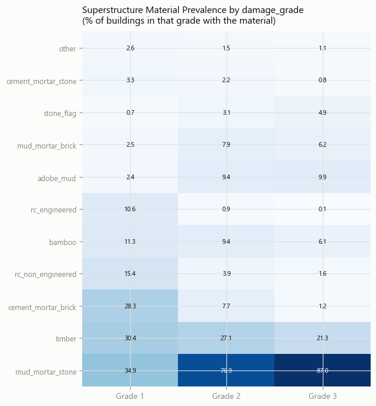

```python
superstructure_by_grade = (df.groupby(TARGET_COL)[SUPERSTRUCTURE_COLS].mean() * 100).T
superstructure_by_grade = superstructure_by_grade.loc[
    superstructure_by_grade.max(axis=1).sort_values(ascending=True).index
]
short_idx = [c.replace("has_superstructure_", "") for c in superstructure_by_grade.index]

fig, ax = plt.subplots(figsize=(6.5, 7))
ax.imshow(superstructure_by_grade.values, aspect="auto", cmap="Blues",
          vmin=0, vmax=superstructure_by_grade.values.max())
ax.set_yticks(range(len(short_idx)))
ax.set_yticklabels(short_idx, fontsize=9)
ax.set_xticks(range(3))
ax.set_xticklabels(["Grade 1", "Grade 2", "Grade 3"], fontsize=10)
ax.set_title("Superstructure Material Prevalence by damage_grade\n(% of buildings in that grade with the material)",
             color=INK_PRIMARY, fontsize=11.5, loc="left", pad=10)
for i in range(superstructure_by_grade.shape[0]):
    for j in range(superstructure_by_grade.shape[1]):
        v = superstructure_by_grade.values[i, j]
        ax.text(j, i, f"{v:.1f}", ha="center", va="center", fontsize=8,
                color="white" if v > superstructure_by_grade.values.max() * 0.5 else INK_PRIMARY)
for s in ax.spines.values():
    s.set_visible(False)
plt.tight_layout()
plt.savefig(OUT / "superstructure_prevalence_by_damage.png", dpi=160)
plt.show()
```

**Interpretation:** `mud_mortar_stone` is common across all three grades but its share rises from grade 1 to grade 3, marking it as a vulnerability indicator rather than a neutral default. Conversely, engineered materials (`rc_engineered`, `cement_mortar_brick`, `cement_mortar_stone`) are noticeably more concentrated in grade 1, consistent with the intuition that reinforced/engineered construction withstands shaking better than mud-mortar construction. This lines up with the `foundation_type` finding above -- construction method, not just geography, is a first-order driver of damage.

#### Correlation heatmap

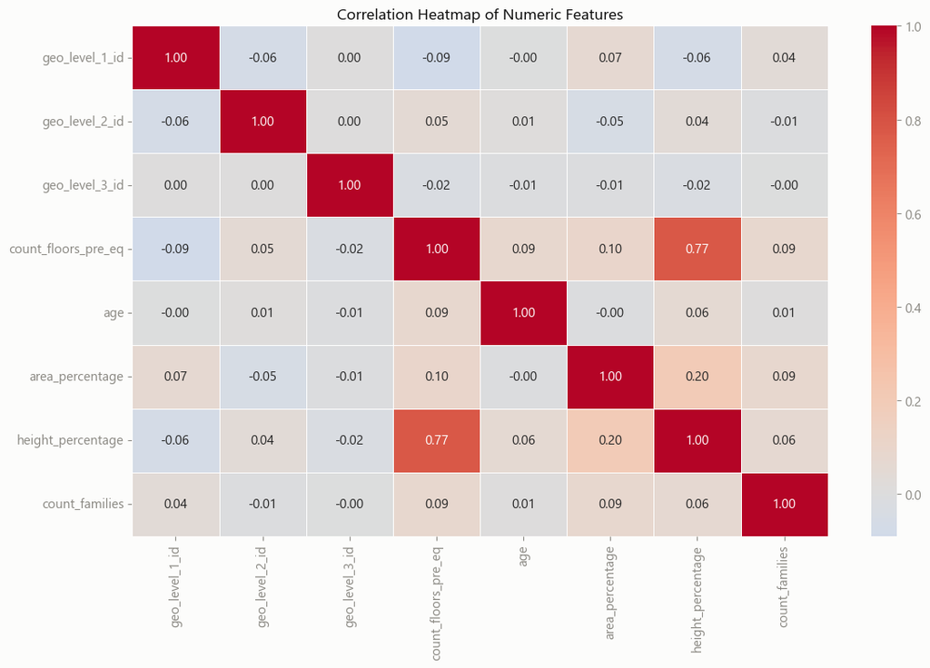

```python
plt.figure(figsize=(12, 8))

corr = train_values[NUMERIC_COLS].corr()

sns.heatmap(
    corr,
    annot=True,
    cmap="coolwarm",
    fmt=".2f",
    linewidths=0.5,
    center=0
)

plt.title("Correlation Heatmap of Numeric Features")
plt.tight_layout()
plt.show()
```

#### Feature Importance Summary: what drives `damage_grade`?

Sections 4-9 looked at each feature group in isolation. To close out the EDA, this puts every feature examined so far on one comparable scale of **association strength with `damage_grade`**: **Cramer's V** for categorical and binary features (foundation type, roof/floor type, geo level, superstructure and secondary-use flags), and **|Pearson r|** for the five continuous numeric features. Both statistics are bounded in [0, 1], so higher always means a stronger relationship with the target, even though the two are computed differently and aren't directly interchangeable -- the chart below is meant to rank features, not to claim two different metrics measure identically the same thing.

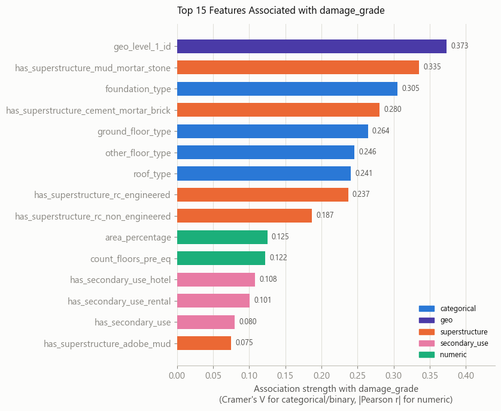

```python
CATEGORICAL_PLUS_GEO = CATEGORICAL_COLS + ["geo_level_1_id"]


def cramers_v(col):
    ct = pd.crosstab(df[col], df[TARGET_COL])
    chi2 = chi2_contingency(ct)[0]
    n = ct.sum().sum()
    k = min(ct.shape) - 1
    return np.sqrt(chi2 / (n * k))


importance_rows = []
for col in CATEGORICAL_PLUS_GEO:
    group = "geo" if col == "geo_level_1_id" else "categorical"
    importance_rows.append((col, group, cramers_v(col)))
for col in SUPERSTRUCTURE_COLS:
    importance_rows.append((col, "superstructure", cramers_v(col)))
for col in SECONDARY_USE_COLS:
    importance_rows.append((col, "secondary_use", cramers_v(col)))
for col in ["count_floors_pre_eq", "age", "area_percentage", "height_percentage", "count_families"]:
    importance_rows.append((col, "numeric", abs(df[[col, TARGET_COL]].corr().iloc[0, 1])))

importance = (
    pd.DataFrame(importance_rows, columns=["feature", "group", "value"])
    .sort_values("value", ascending=False)
    .head(15)
    .iloc[::-1]
)

group_colors = {
    "categorical": CAT["blue"],
    "geo": CAT["violet"],
    "superstructure": CAT["orange"],
    "secondary_use": CAT["magenta"],
    "numeric": CAT["aqua"],
}
bar_colors = importance["group"].map(group_colors)

fig, ax = plt.subplots(figsize=(8.5, 7))
bars = ax.barh(importance["feature"], importance["value"], color=bar_colors, height=0.65)
for b, v in zip(bars, importance["value"].values):
    ax.text(v + 0.006, b.get_y() + b.get_height() / 2, f"{v:.3f}",
            va="center", ha="left", fontsize=9, color=INK_SECONDARY)
ax.set_xlim(0, importance["value"].max() * 1.18)
ax.set_xlabel("Association strength with damage_grade\n(Cramer's V for categorical/binary, |Pearson r| for numeric)")
ax.set_title("Top 15 Features Associated with damage_grade", color=INK_PRIMARY, fontsize=12, loc="left", pad=12)
style_ax(ax, hide_spines=("top", "right", "left"))
ax.grid(axis="y", visible=False)

legend_handles = [plt.Rectangle((0, 0), 1, 1, color=c) for c in group_colors.values()]
ax.legend(legend_handles, group_colors.keys(), loc="lower right", frameon=False, fontsize=9)

plt.tight_layout()
plt.savefig(OUT / "feature_importance_summary.png", dpi=160)
plt.show()
```

**Interpretation:** Ranked on one comparable scale, the strongest drivers of `damage_grade` are **geo_level_1_id** (Cramer's V = 0.373, confirming location/seismic-intensity is the single biggest factor), followed closely by **superstructure material** -- `has_superstructure_mud_mortar_stone` (0.335) and `has_superstructure_cement_mortar_brick` (0.280) -- and then the construction-type categoricals: `foundation_type` (0.305), `ground_floor_type` (0.264), `other_floor_type` (0.246), and `roof_type` (0.241). Engineered-concrete flags (`rc_engineered`, `rc_non_engineered`) also rank highly (0.19-0.24), reinforcing the Section 8/9 finding that construction material is nearly as important as location.

The five continuous numeric features trail well behind -- `area_percentage` (0.125) and `count_floors_pre_eq` (0.122) are the strongest of the group, consistent with their (still weak) Pearson correlations from Section 9. A couple of secondary-use flags (`hotel`, `rental`) show up in the top 15 despite very low prevalence (3.4% and 0.8% of buildings); take those two with some caution, since Cramer's V can look inflated on small, unbalanced categories -- they're included here for completeness, not as reliable standalone predictors.

**Practical takeaway:** location (`geo_level_*`), superstructure material, and the foundation/floor/roof-type categoricals should be prioritized as the primary predictive features going into modeling, with the continuous numeric features contributing smaller, non-linear adjustments -- reinforcing the earlier recommendation to use tree-based models that can capture interactions between these feature groups rather than relying on any single feature's raw correlation with the target.

#### Feature Importance Summary: Mutual Information for all features

As a complement to the Cramer's V / |Pearson r| ranking above, this section scores **every one of the 38 features** with a single, consistent metric: **mutual information (MI)** with `damage_grade`. Unlike Cramer's V and Pearson correlation, MI is estimator-agnostic and captures non-linear/non-monotonic dependence, so it acts as a useful cross-check on the earlier ranking rather than a replacement for it. Categorical columns are label-encoded (MI is invariant to the encoding used for discrete features), and geo IDs / binary flags are scored as discrete features while the five continuous numeric columns are scored as continuous.

```
                               feature          group  mi_score
                        geo_level_3_id            geo  0.334123
                        geo_level_2_id            geo  0.240002
                        geo_level_1_id            geo  0.131877
                       foundation_type    categorical  0.071000
                     ground_floor_type    categorical  0.053564
   has_superstructure_mud_mortar_stone superstructure  0.049215
                      other_floor_type    categorical  0.047697
                             roof_type    categorical  0.040643
                   count_floors_pre_eq        numeric  0.035713
has_superstructure_cement_mortar_brick superstructure  0.032731
                                   age        numeric  0.030914
                        count_families        numeric  0.028637
                     height_percentage        numeric  0.024463
      has_superstructure_rc_engineered superstructure  0.016171
                       area_percentage        numeric  0.015575
  has_superstructure_rc_non_engineered superstructure  0.012727
               has_secondary_use_hotel  secondary_use  0.004806
                legal_ownership_status    categorical  0.003991
          has_superstructure_adobe_mud superstructure  0.003765
              has_secondary_use_rental  secondary_use  0.003471
                    plan_configuration    categorical  0.003278
                     has_secondary_use  secondary_use  0.003147
         has_superstructure_stone_flag superstructure  0.002589
             has_superstructure_timber superstructure  0.002548
   has_superstructure_mud_mortar_brick superstructure  0.002443
             has_superstructure_bamboo superstructure  0.002132
                              position    categorical  0.002063
has_superstructure_cement_mortar_stone superstructure  0.001987
         has_secondary_use_agriculture  secondary_use  0.001261
                land_surface_condition    categorical  0.000908
              has_superstructure_other superstructure  0.000484
         has_secondary_use_institution  secondary_use  0.000404
               has_secondary_use_other  secondary_use  0.000145
              has_secondary_use_school  secondary_use  0.000074
            has_secondary_use_industry  secondary_use  0.000070
          has_secondary_use_gov_office  secondary_use  0.000043
         has_secondary_use_health_post  secondary_use  0.000037
          has_secondary_use_use_police  secondary_use  0.000003
```

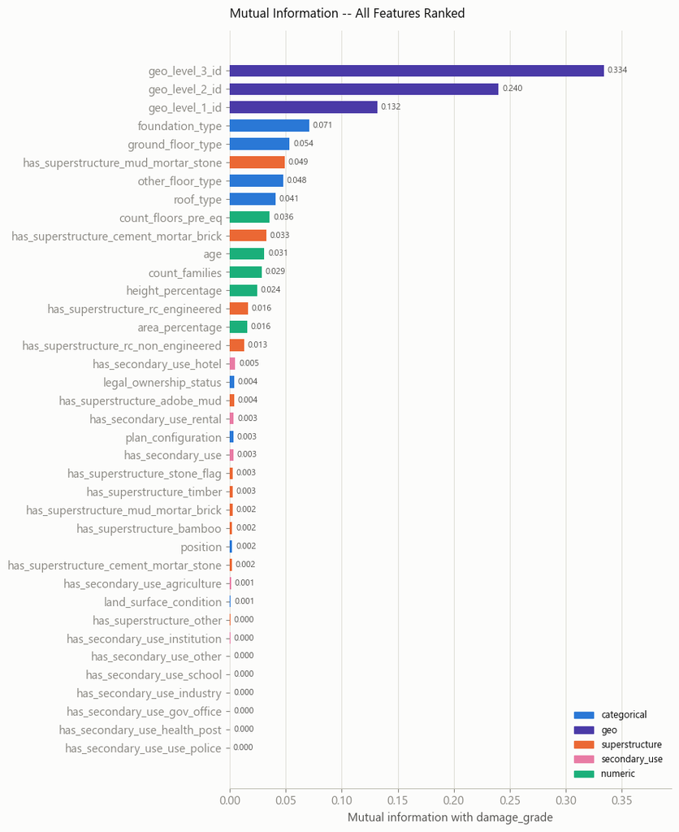

```python
from sklearn.feature_selection import mutual_info_classif
from sklearn.preprocessing import LabelEncoder

MI_FEATURE_GROUPS = {
    "geo": GEO_COLS,
    "categorical": CATEGORICAL_COLS,
    "superstructure": SUPERSTRUCTURE_COLS,
    "secondary_use": SECONDARY_USE_COLS,
    "numeric": ["count_floors_pre_eq", "age", "area_percentage", "height_percentage", "count_families"],
}

ALL_MI_COLS = [col for cols in MI_FEATURE_GROUPS.values() for col in cols]
col_to_group = {col: group for group, cols in MI_FEATURE_GROUPS.items() for col in cols}

mi_input = df[ALL_MI_COLS].copy()
discrete_features = []
for col in ALL_MI_COLS:
    if mi_input[col].dtype == object:
        mi_input[col] = LabelEncoder().fit_transform(mi_input[col])
        discrete_features.append(True)
    else:
        # geo IDs and binary flags are discrete; the 5 continuous numeric cols are not
        discrete_features.append(col in GEO_COLS or col in BINARY_COLS)

mi_scores = mutual_info_classif(
    mi_input,
    df[TARGET_COL],
    discrete_features=discrete_features,
    random_state=RANDOM_STATE,
)

mi_importance = (
    pd.DataFrame({
        "feature": ALL_MI_COLS,
        "group": [col_to_group[c] for c in ALL_MI_COLS],
        "mi_score": mi_scores,
    })
    .sort_values("mi_score", ascending=False)
    .reset_index(drop=True)
)

print(mi_importance.to_string(index=False))

plot_data = mi_importance.sort_values("mi_score", ascending=True)
bar_colors = plot_data["group"].map(group_colors)

fig, ax = plt.subplots(figsize=(9, 11))
bars = ax.barh(plot_data["feature"], plot_data["mi_score"], color=bar_colors, height=0.65)
for b, v in zip(bars, plot_data["mi_score"].values):
    ax.text(v + plot_data["mi_score"].max() * 0.01, b.get_y() + b.get_height() / 2, f"{v:.3f}",
            va="center", ha="left", fontsize=8, color=INK_SECONDARY)
ax.set_xlim(0, plot_data["mi_score"].max() * 1.18)
ax.set_xlabel("Mutual information with damage_grade")
ax.set_title("Mutual Information -- All Features Ranked", color=INK_PRIMARY, fontsize=12, loc="left", pad=12)
style_ax(ax, hide_spines=("top", "right", "left"))
ax.grid(axis="y", visible=False)

legend_handles = [plt.Rectangle((0, 0), 1, 1, color=c) for c in group_colors.values()]
ax.legend(legend_handles, group_colors.keys(), loc="lower right", frameon=False, fontsize=9)

plt.tight_layout()
plt.savefig(OUT / "feature_importance_mutual_information.png", dpi=160)
plt.show()
```

### Summary of Key Takeaways

#### Data Retention Decision

- `age == 995` is very likely a placeholder/sentinel rather than a measurement error, but it's a real code that appears in *both* train and test. Dropping it from train only would bias the training distribution away from what the model actually sees at inference time. It's turned into a binary flag and its own age-bucket category instead (see Feature Engineering, below) rather than removed.
- The feature-level duplicates are genuinely different buildings that happen to share a feature profile (Section 3) -- removing them would discard real observations, not noise.
- `area_percentage` / `height_percentage` outliers are large-but-plausible buildings, not data-entry errors, and the intended model family (tree ensembles, per the EDA's non-linear-relationship finding) is far less sensitive to unscaled outliers than a linear model would be.

The counts below are reported for transparency only -- no rows are removed.

```python
print_header("DATA RETENTION CHECK (no rows removed)")

age_995_count = (df["age"] == 995).sum()
print(f"age == 995 rows                 : {age_995_count:,} ({age_995_count / len(df):.2%}) -- retained")

feature_cols = [c for c in df.columns if c != ID_COL]
dup_count = df.duplicated(subset=feature_cols, keep="first").sum()
print(f"Duplicate feature rows          : {dup_count:,} ({dup_count / len(df):.2%}) -- retained")

for col in ["area_percentage", "height_percentage"]:
    q1, q3 = df[col].quantile([0.25, 0.75])
    iqr = q3 - q1
    lower, upper = q1 - 1.5 * iqr, q3 + 1.5 * iqr
    n_outliers = ((df[col] < lower) | (df[col] > upper)).sum()
    print(f"{col:24s} IQR outliers : {n_outliers:,} ({n_outliers / len(df):.2%}) "
          f"outside [{lower:.1f}, {upper:.1f}] -- retained")

print(f"\nRows carried into preprocessing: {len(df):,} (unchanged from train_values)")
```

```
================================================================================
DATA RETENTION CHECK (no rows removed)
================================================================================
age == 995 rows                 : 1,390 (0.53%) -- retained
Duplicate feature rows          : 12,319 (4.73%) -- retained
area_percentage          IQR outliers : 13,557 (5.20%) outside [-1.0, 15.0] -- retained
height_percentage        IQR outliers : 7,843 (3.01%) outside [1.0, 9.0] -- retained

Rows carried into preprocessing: 260,601 (unchanged from train_values)
```

## Preprocessing

#### Train / Test Preparation

No rows are dropped (see the Data Retention Decision above), so this step only aligns `train_values` with `train_labels` into a single (values, labels) pair -- `train_values_clean` / `train_labels_clean` -- keeping the same naming convention the rest of the pipeline expects. `test_values_clean` is an untouched copy of `test_values` (there is no capping step).

```python
def prepare_data(train_values, train_labels):
    """No-op cleaning: aligns train_values/train_labels index-for-index.
    Kept as a named step (rather than using train_values/train_labels directly)
    so the rest of the pipeline reads the same if this decision is revisited.
    """
    merged = train_values.merge(train_labels, on=ID_COL)
    values = merged.drop(columns=[TARGET_COL])
    labels = merged[[ID_COL, TARGET_COL]]
    assert len(values) == len(train_values), "row count changed unexpectedly"
    return values, labels


train_values_clean, train_labels_clean = prepare_data(train_values, train_labels)
test_values_clean = test_values.copy()

print(f"train_values_clean: {train_values_clean.shape}")
print(f"test_values_clean : {test_values_clean.shape}")
```

```
train_values_clean: (260601, 39)
test_values_clean : (86868, 39)
```

##### Separate Features and Target

```python
# Features and target
X = train_values.drop(columns=[ID_COL])
y = train_labels[TARGET_COL]

# Test features
X_test = test_values.drop(columns=[ID_COL])

print("Training features :", X.shape)
print("Target            :", y.shape)
print("Test features     :", X_test.shape)
```

```
Training features : (260601, 38)
Target            : (260601,)
Test features     : (86868, 38)
```

##### Validate Feature Groups

```python
# Combine all feature groups
FEATURE_COLS = (
    GEO_COLS
    + NUMERIC_COLS
    + CATEGORICAL_COLS
    + BINARY_COLS
)

# Check for duplicated assignments
duplicate_features = {
    col for col in FEATURE_COLS
    if FEATURE_COLS.count(col) > 1
}

# Check for features that haven't been assigned to any group
unassigned_features = (
    set(X.columns) - set(FEATURE_COLS)
)

# Check for columns in feature groups that don't exist in X
invalid_features = (
    set(FEATURE_COLS) - set(X.columns)
)

print("Total features in X       :", len(X.columns))
print("Total grouped features    :", len(FEATURE_COLS))

print("\nDuplicated features       :", duplicate_features)
print("Unassigned features      :", unassigned_features)
print("Invalid feature names    :", invalid_features)
```

```
Total features in X       : 38
Total grouped features    : 38

Duplicated features       : set()
Unassigned features      : set()
Invalid feature names    : set()
```

#### Create Training and Validation Sets

Although train_values and test_values have already been provided separately, we still need a validation set to evaluate our models during development.

We will create the validation set only from the training data. The official X_test remains untouched.

Because the target is imbalanced, we use stratify=y so that Grades 1, 2, and 3 maintain approximately the same proportions in both sets.

```python
from sklearn.model_selection import train_test_split

X_train, X_valid, y_train, y_valid = train_test_split(
    X,
    y,
    test_size=0.20,
    stratify=y,
    random_state=RANDOM_STATE
)

print("X_train:", X_train.shape)
print("X_valid:", X_valid.shape)
print("y_train:", y_train.shape)
print("y_valid:", y_valid.shape)
```

```
X_train: (208480, 38)
X_valid: (52121, 38)
y_train: (208480,)
y_valid: (52121,)
```

##### Verify the Stratified Split

```python
distribution = pd.DataFrame({
    "Full Dataset": y.value_counts(normalize=True),
    "Training": y_train.value_counts(normalize=True),
    "Validation": y_valid.value_counts(normalize=True)
}).sort_index()

distribution
```

| damage_grade | Full Dataset | Training | Validation |
| --- | --- | --- | --- |
| 1 | 0.096408 | 0.096407 | 0.096410 |
| 2 | 0.568912 | 0.568913 | 0.568907 |
| 3 | 0.334680 | 0.334680 | 0.334683 |

### Preprocessing

```python
from sklearn.compose import ColumnTransformer
from sklearn.preprocessing import StandardScaler, OneHotEncoder


# Preprocessing for each feature group
'''Why use ColumnTransformer?

It allows us to apply different transformations to different columns while keeping everything inside one preprocessing object.'''

preprocessor = ColumnTransformer(
    transformers=[
        # Numerical features
        (
            "numeric",
            StandardScaler(),
            NUMERIC_COLS
        ),

        # Low-cardinality categorical features
        (
            "categorical",
            OneHotEncoder(
                handle_unknown="ignore"
            ),
            CATEGORICAL_COLS
        ),

        # Geographic IDs treated as categorical
        (
            "geo",
            OneHotEncoder(
                handle_unknown="ignore"
            ),
            GEO_COLS
        ),

        # Binary 0/1 features
        (
            "binary",
            "passthrough",
            BINARY_COLS
        )
    ],
    remainder="drop"
)

# Fit preprocessing only on the training data
preprocessor.fit(X_train)

print("Preprocessor fitted successfully.")
```

```
Preprocessor fitted successfully.
```

```python
## Transform Training and Validation Data

X_train_processed = preprocessor.transform(X_train)
X_valid_processed = preprocessor.transform(X_valid)

print("Original X_train shape   :", X_train.shape)
print("Processed X_train shape :", X_train_processed.shape)

print("\nOriginal X_valid shape   :", X_valid.shape)
print("Processed X_valid shape :", X_valid_processed.shape)



## ***** The number of columns will increase because the categorical and geographic variables are one-hot encoded
```

```
Original X_train shape   : (208480, 38)
Processed X_train shape : (208480, 12885)

Original X_valid shape   : (52121, 38)
Processed X_valid shape : (52121, 12885)
```

```python
print(X_valid_processed.nnz)                 # number of stored (non-zero) entries
print(X_valid_processed.nnz / (X_valid_processed.shape[0] * X_valid_processed.shape[1]))

# Inspect the Transformation
for name, transformer, columns in preprocessor.transformers_:
    if name != "remainder":
        print(f"{name:15} → {len(columns):2} input columns")

#To see the actual number of generated features
feature_names = preprocessor.get_feature_names_out()

print("Total processed features:", len(feature_names))
print("\nFirst 20 features:")
print(feature_names[:20])
```

```
921611
0.001372304499327879
numeric         →  5 input columns
categorical     →  8 input columns
geo             →  3 input columns
binary          → 22 input columns
Total processed features: 12885

First 20 features:
['numeric__count_floors_pre_eq' 'numeric__age' 'numeric__area_percentage'
 'numeric__height_percentage' 'numeric__count_families'
 'categorical__land_surface_condition_n'
 'categorical__land_surface_condition_o'
 'categorical__land_surface_condition_t' 'categorical__foundation_type_h'
 'categorical__foundation_type_i' 'categorical__foundation_type_r'
 'categorical__foundation_type_u' 'categorical__foundation_type_w'
 'categorical__roof_type_n' 'categorical__roof_type_q'
 'categorical__roof_type_x' 'categorical__ground_floor_type_f'
 'categorical__ground_floor_type_m' 'categorical__ground_floor_type_v'
 'categorical__ground_floor_type_x']
```

### Build the Logistic Regression Pipeline

```python
from sklearn.pipeline import Pipeline
from sklearn.linear_model import LogisticRegression

logistic_pipeline = Pipeline(
    steps=[
        ("preprocessor", preprocessor),
        (
            "classifier",
            LogisticRegression(
                max_iter=1000,
                class_weight="balanced",
                random_state=RANDOM_STATE
            )
        )
    ]
)

#print(logistic_pipeline)
```

#### Train the Baseline Model

```python
logistic_pipeline.fit(X_train, y_train)

print("Logistic Regression training completed.")
```

```
Logistic Regression training completed.
```

#### Generate Validation Predictions

```python
y_valid_pred = logistic_pipeline.predict(X_valid)

print("Predictions generated:", len(y_valid_pred))
print("First 20 predictions:")
print(y_valid_pred[:20])
```

```
Predictions generated: 52121
First 20 predictions:
[2 3 1 2 3 2 2 1 3 3 3 2 3 1 3 2 2 3 1 2]
```

### Evaluate the Baseline

```python
from sklearn.metrics import accuracy_score, f1_score

accuracy = accuracy_score(y_valid, y_valid_pred)

micro_f1 = f1_score(
    y_valid,
    y_valid_pred,
    average="micro"
)

print(f"Accuracy : {accuracy:.4f}")
print(f"Micro-F1 : {micro_f1:.4f}")
```

```
Accuracy : 0.6966
Micro-F1 : 0.6966
```

```python
from sklearn.metrics import classification_report

print(
    classification_report(
        y_valid,
        y_valid_pred,
        digits=4
    )
)
```

```
              precision    recall  f1-score   support

           1     0.4428    0.8529    0.5830      5025
           2     0.8121    0.6385    0.7149     29652
           3     0.6844    0.7504    0.7159     17444

    accuracy                         0.6966     52121
   macro avg     0.6464    0.7473    0.6713     52121
weighted avg     0.7337    0.6966    0.7025     52121
```

### Confusion Matrix

The confusion matrix shows how the model's predictions are distributed across the three damage grades.

Rows represent the actual damage grade, while columns represent the predicted grade. This allows us to identify which classes are most frequently confused with each other.

```
[[ 4286   617   122]
 [ 4803 18934  5915]
 [  590  3764 13090]]
```

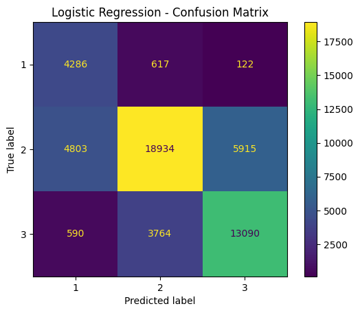

```python
from sklearn.metrics import confusion_matrix, ConfusionMatrixDisplay
import matplotlib.pyplot as plt

cm = confusion_matrix(
    y_valid,
    y_valid_pred,
    labels=[1, 2, 3]
)

print(cm)

disp = ConfusionMatrixDisplay(
    confusion_matrix=cm,
    display_labels=[1, 2, 3]
)

disp.plot()
plt.title("Logistic Regression - Confusion Matrix")
plt.show()
```

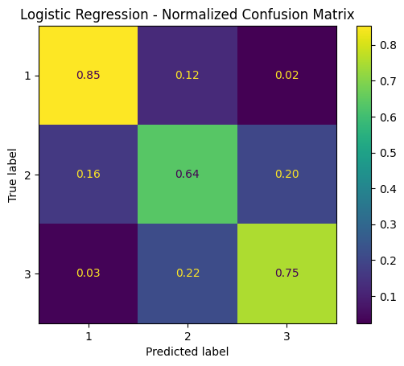

```python
#The raw counts are useful, but because the classes have different sizes, a row-normalized confusion matrix is also useful.
cm_normalized = confusion_matrix(
    y_valid,
    y_valid_pred,
    labels=[1, 2, 3],
    normalize="true"
)

disp = ConfusionMatrixDisplay(
    confusion_matrix=cm_normalized,
    display_labels=[1, 2, 3]
)

disp.plot(values_format=".2f")
plt.title("Logistic Regression - Normalized Confusion Matrix")
plt.show()
```

#### Create a Small Model Results Table

```python
results = []

results.append({
    "Model": "Logistic Regression",
    "Accuracy": accuracy,
    "Micro-F1": micro_f1
})

results_df = pd.DataFrame(results)

results_df
```

|  | Model | Accuracy | Micro-F1 |
| --- | --- | --- | --- |
| 0 | Logistic Regression | 0.696648 | 0.696648 |

### Random Forest Baseline

Logistic Regression achieved a validation micro-F1 of approximately 0.6966. The confusion matrix showed substantial confusion between adjacent damage grades, suggesting that nonlinear relationships and feature interactions may be important.

We therefore train a Random Forest classifier as the next baseline. Unlike Logistic Regression, Random Forest does not require feature scaling and can capture nonlinear relationships between building characteristics.

For this initial experiment, the geographic IDs are passed through directly. Their encoding will be investigated separately in later experiments.

```python
from sklearn.compose import ColumnTransformer
from sklearn.preprocessing import OneHotEncoder

rf_preprocessor = ColumnTransformer(
    transformers=[
        (
            "categorical",
            OneHotEncoder(handle_unknown="ignore"),
            CATEGORICAL_COLS
        ),
        (
            "geo",
            "passthrough",
            GEO_COLS
        ),
        (
            "numeric",
            "passthrough",
            NUMERIC_COLS
        ),
        (
            "binary",
            "passthrough",
            BINARY_COLS
        )
    ],
    remainder="drop"
)
```

```python
# Train Random Forest

from sklearn.ensemble import RandomForestClassifier
from sklearn.pipeline import Pipeline

rf_pipeline = Pipeline(
    steps=[
        ("preprocessor", rf_preprocessor),
        (
            "classifier",
            RandomForestClassifier(
                n_estimators=200,
                random_state=RANDOM_STATE,
                n_jobs=-1,
                class_weight="balanced"
            )
        )
    ]
)

rf_pipeline.fit(X_train, y_train)

print("Random Forest training completed.")
```

```
Random Forest training completed.
```

```python
# Evaluate Random Forest
from sklearn.metrics import accuracy_score, f1_score

y_valid_pred_rf = rf_pipeline.predict(X_valid)

rf_accuracy = accuracy_score(
    y_valid,
    y_valid_pred_rf
)

rf_micro_f1 = f1_score(
    y_valid,
    y_valid_pred_rf,
    average="micro"
)

print(f"Random Forest Accuracy : {rf_accuracy:.4f}")
print(f"Random Forest Micro-F1 : {rf_micro_f1:.4f}")
```

```
Random Forest Accuracy : 0.6997
Random Forest Micro-F1 : 0.6997
```

```python
from sklearn.metrics import classification_report

print(
    classification_report(
        y_valid,
        y_valid_pred_rf,
        digits=4
    )
)

results.append({
    "Model": "Random Forest",
    "Accuracy": rf_accuracy,
    "Micro-F1": rf_micro_f1
})

results_df = pd.DataFrame(results)

results_df.sort_values(
    by="Micro-F1",
    ascending=False
)
```

```
              precision    recall  f1-score   support

           1     0.5370    0.6605    0.5924      5025
           2     0.7573    0.7158    0.7360     29652
           3     0.6656    0.6835    0.6744     17444

    accuracy                         0.6997     52121
   macro avg     0.6533    0.6866    0.6676     52121
weighted avg     0.7054    0.6997    0.7015     52121
```

|  | Model | Accuracy | Micro-F1 |
| --- | --- | --- | --- |
| 1 | Random Forest | 0.699660 | 0.699660 |
| 0 | Logistic Regression | 0.696648 | 0.696648 |

### Geographic Feature Analysis

The geographic identifiers are categorical location variables rather than continuous numerical measurements. Because they have different cardinalities, we will examine their relationship with the target before deciding on a more advanced encoding strategy.

We will start by measuring the damage-grade distribution within each geographic level.

```python
for col in GEO_COLS:
    print(f"\n{'=' * 60}")
    print(f"{col}")
    print(f"{'=' * 60}")

    summary = (
        pd.crosstab(
            train_values[col],
            train_labels[TARGET_COL],
            normalize="index"
        )
        .rename(columns={
            1: "Grade_1",
            2: "Grade_2",
            3: "Grade_3"
        })
    )

    print("Number of unique locations:", train_values[col].nunique())
    print(summary.head(10))
```

```
============================================================
geo_level_1_id
============================================================
Number of unique locations: 31
damage_grade     Grade_1   Grade_2   Grade_3
geo_level_1_id
0               0.084019  0.766642  0.149339
1               0.152166  0.734913  0.112921
2               0.091300  0.655209  0.253491
3               0.032493  0.603448  0.364058
4               0.035763  0.766337  0.197900
5               0.165799  0.748699  0.085502
6               0.086461  0.665354  0.248185
7               0.054386  0.593503  0.352111
8               0.034277  0.446174  0.519549
9               0.141738  0.690500  0.167761

============================================================
geo_level_2_id
============================================================
Number of unique locations: 1414
damage_grade     Grade_1   Grade_2   Grade_3
geo_level_2_id
0               0.000000  0.236842  0.763158
1               0.000000  0.651961  0.348039
3               0.064935  0.766234  0.168831
4               0.006349  0.466667  0.526984
5               0.000000  0.840000  0.160000
6               0.500000  0.500000  0.000000
7               0.010000  0.610000  0.380000
8               0.025000  0.783333  0.191667
9               0.000000  0.249249  0.750751
10              0.033898  0.819209  0.146893

============================================================
geo_level_3_id
============================================================
Number of unique locations: 11595
damage_grade     Grade_1   Grade_2   Grade_3
geo_level_3_id
0               0.000000  0.000000  1.000000
1               0.166667  0.166667  0.666667
3               0.111111  0.888889  0.000000
5               0.857143  0.142857  0.000000
6               0.095238  0.285714  0.619048
7               0.000000  1.000000  0.000000
8               0.000000  0.548387  0.451613
9               0.333333  0.000000  0.666667
10              0.000000  1.000000  0.000000
11              0.145161  0.322581  0.532258
```

### Mutual Information of Geographic Features

Mutual information measures how much information a feature provides about the target variable. A larger value indicates a stronger dependency between the feature and damage grade.

For the geographic identifiers, we treat them as discrete variables rather than continuous numerical measurements.

```python
from sklearn.feature_selection import mutual_info_classif

X_geo = train_values[GEO_COLS].copy()

mi_geo = mutual_info_classif(
    X_geo,
    train_labels[TARGET_COL],
    discrete_features=True,
    random_state=RANDOM_STATE
)

geo_mi = pd.DataFrame({
    "Feature": GEO_COLS,
    "Mutual_Information": mi_geo
}).sort_values(
    "Mutual_Information",
    ascending=False
)

geo_mi
```

|  | Feature | Mutual_Information |
| --- | --- | --- |
| 2 | geo_level_3_id | 0.334123 |
| 1 | geo_level_2_id | 0.240002 |
| 0 | geo_level_1_id | 0.131877 |

## Frequency Encoding of Geographic Features

The geographic IDs have high mutual information with the damage grade, indicating that location contains substantial predictive information.

Instead of treating geographic IDs as numerical values, we will encode each geographic category by its frequency in the training data. This provides the model with information about how common each location is without using the target variable.

The encoder is fitted only on the training portion of the data and is placed inside the scikit-learn pipeline to prevent information leakage.

```python
from sklearn.base import BaseEstimator, TransformerMixin
import pandas as pd


class FrequencyEncoder(BaseEstimator, TransformerMixin):
    def __init__(self, columns):
        self.columns = columns

    def fit(self, X, y=None):
        X = X.copy()

        self.frequency_maps_ = {}

        for col in self.columns:
            self.frequency_maps_[col] = (
                X[col]
                .value_counts(normalize=True)
            )

        return self

    def transform(self, X):
        X = X.copy()

        for col in self.columns:
            X[col] = (
                X[col]
                .map(self.frequency_maps_[col])
                .fillna(0)
            )

        return X[self.columns]


geo_frequency_encoder = FrequencyEncoder(
    columns=GEO_COLS
)
```

### Build the frequency-encoded preprocessing pipeline

We will now combine the frequency encoder with the existing preprocessing steps.

The geographic features will no longer be one-hot encoded. Each geographic ID will instead become a continuous frequency feature.

```python
from sklearn.compose import ColumnTransformer
from sklearn.preprocessing import OneHotEncoder, StandardScaler


frequency_preprocessor = ColumnTransformer(
    transformers=[
        (
            "geo_frequency",
            FrequencyEncoder(columns=GEO_COLS),
            GEO_COLS
        ),
        (
            "numeric",
            StandardScaler(),
            NUMERIC_COLS
        ),
        (
            "categorical",
            OneHotEncoder(handle_unknown="ignore"),
            CATEGORICAL_COLS
        ),
        (
            "binary",
            "passthrough",
            BINARY_COLS
        )
    ],
    remainder="drop"
)
```

### Train Logistic Regression with frequency-encoded geography

We will keep the classifier configuration the same as the original Logistic Regression baseline.

This allows us to attribute any performance difference primarily to the geographic encoding strategy rather than to changes in the classifier.

```python
from sklearn.pipeline import Pipeline
from sklearn.linear_model import LogisticRegression


logistic_frequency_pipeline = Pipeline(
    steps=[
        (
            "preprocessor",
            frequency_preprocessor
        ),
        (
            "classifier",
            LogisticRegression(
                max_iter=1000,
                class_weight="balanced",
                random_state=RANDOM_STATE
            )
        )
    ]
)

logistic_frequency_pipeline.fit(
    X_train,
    y_train
)
```

```
Pipeline(steps=[('preprocessor',
                 ColumnTransformer(transformers=[('geo_frequency',
                                                  FrequencyEncoder(columns=['geo_level_1_id',
                                                                            'geo_level_2_id',
                                                                            'geo_level_3_id']),
                                                  ['geo_level_1_id',
                                                   'geo_level_2_id',
                                                   'geo_level_3_id']),
                                                 ('numeric', StandardScaler(),
                                                  ['count_floors_pre_eq', 'age',
                                                   'area_percentage',
                                                   'height_percentage',
                                                   'count_families']),
                                                 ('categorical',
                                                  OneHotE...
                                                   'has_secondary_use_hotel',
                                                   'has_secondary_use_rental',
                                                   'has_secondary_use_institution',
                                                   'has_secondary_use_school',
                                                   'has_secondary_use_industry',
                                                   'has_secondary_use_health_post',
                                                   'has_secondary_use_gov_office',
                                                   'has_secondary_use_use_police',
                                                   'has_secondary_use_other'])])),
                ('classifier',
                 LogisticRegression(class_weight='balanced', max_iter=1000,
                                    random_state=42))])
```

```python
# Evaluation of frequency encoding

from sklearn.metrics import accuracy_score, f1_score, classification_report


y_valid_pred_freq = logistic_frequency_pipeline.predict(X_valid)

accuracy_freq = accuracy_score(
    y_valid,
    y_valid_pred_freq
)

micro_f1_freq = f1_score(
    y_valid,
    y_valid_pred_freq,
    average="micro"
)

print(f"Accuracy: {accuracy_freq:.4f}")
print(f"Micro-F1: {micro_f1_freq:.4f}")

print("\nClassification Report:")
print(
    classification_report(
        y_valid,
        y_valid_pred_freq
    )
)
```

```
Accuracy: 0.5189
Micro-F1: 0.5189

Classification Report:
              precision    recall  f1-score   support

           1       0.37      0.68      0.48      5025
           2       0.68      0.38      0.49     29652
           3       0.47      0.72      0.57     17444

    accuracy                           0.52     52121
   macro avg       0.51      0.59      0.51     52121
weighted avg       0.58      0.52      0.51     52121
```

## Leakage-Safe Target Encoding

The geographic features have strong predictive information, but frequency encoding performed poorly because it captures only how common a location is.

We will therefore test target encoding, where each geographic category is represented by its historical damage-grade distribution.

To avoid target leakage, the encoding for training observations will be generated out-of-fold. Each training row will therefore be encoded using target information from other training rows rather than its own target.

Smoothing will be applied so that geographic categories with fewer observations are shrunk toward the overall target mean.

```python
class OutOfFoldTargetEncoder(BaseEstimator, TransformerMixin):
    def __init__(
        self,
        columns,
        n_splits=5,
        smoothing=10.0,
        random_state=42
    ):
        self.columns = columns
        self.n_splits = n_splits
        self.smoothing = smoothing
        self.random_state = random_state

    def _fit_mapping(self, X, y, col):
        stats = pd.DataFrame({
            "category": X[col].values,
            "target": y.values
        }).groupby("category")["target"].agg(
            ["mean", "count"]
        )

        stats["encoding"] = (
            stats["count"] * stats["mean"]
            + self.smoothing * self.global_mean_
        ) / (
            stats["count"] + self.smoothing
        )

        return stats["encoding"]

    def fit(self, X, y):
        X = X.copy()
        y = pd.Series(y).reset_index(drop=True)
        X = X.reset_index(drop=True)

        self.global_mean_ = y.mean()
        self.mapping_ = {}

        # Store the final mapping fitted on all training data.
        for col in self.columns:
            self.mapping_[col] = self._fit_mapping(
                X,
                y,
                col
            )

        return self

    def transform(self, X):
        X = X.copy()

        for col in self.columns:
            X[col] = (
                X[col]
                .map(self.mapping_[col])
                .fillna(self.global_mean_)
            )

        return X[self.columns]
```

```python
from sklearn.model_selection import KFold


def target_encode_train_valid(
    X_train,
    y_train,
    X_valid,
    columns,
    n_splits=5,
    smoothing=10.0,
    random_state=42
):
    X_train_encoded = pd.DataFrame(
        index=X_train.index
    )

    X_valid_encoded = pd.DataFrame(
        index=X_valid.index
    )

    global_mean = y_train.mean()

    kfold = KFold(
        n_splits=n_splits,
        shuffle=True,
        random_state=random_state
    )

    # Out-of-fold encoding for training data
    for col in columns:

        train_encoded = pd.Series(
            index=X_train.index,
            dtype=float
        )

        for train_idx, fold_idx in kfold.split(X_train):

            X_fit = X_train.iloc[train_idx]
            y_fit = y_train.iloc[train_idx]

            stats = pd.DataFrame({
                "category": X_fit[col].values,
                "target": y_fit.values
            }).groupby("category")["target"].agg(
                ["mean", "count"]
            )

            encoding = (
                stats["count"] * stats["mean"]
                + smoothing * global_mean
            ) / (
                stats["count"] + smoothing
            )

            fold_values = (
                X_train.iloc[fold_idx][col]
                .map(encoding)
                .fillna(global_mean)
            )

            train_encoded.iloc[fold_idx] = fold_values.values

        X_train_encoded[col] = train_encoded

        # Validation encoding uses ALL training data,
        # never validation targets.
        stats = pd.DataFrame({
            "category": X_train[col].values,
            "target": y_train.values
        }).groupby("category")["target"].agg(
            ["mean", "count"]
        )

        encoding = (
            stats["count"] * stats["mean"]
            + smoothing * global_mean
        ) / (
            stats["count"] + smoothing
        )

        X_valid_encoded[col] = (
            X_valid[col]
            .map(encoding)
            .fillna(global_mean)
        )

    return X_train_encoded, X_valid_encoded
```

```python
X_train_geo3, X_valid_geo3 = target_encode_train_valid(
    X_train,
    y_train,
    X_valid,
    columns=["geo_level_3_id"],
    n_splits=5,
    smoothing=10.0,
    random_state=RANDOM_STATE
)

print(X_train_geo3.head())
print()
print(X_valid_geo3.head())
```

```
        geo_level_3_id
185461        2.496446
190537        2.396317
232781        2.172506
213004        1.863719
177786        2.325221

        geo_level_3_id
124536        2.140041
112152        2.242186
93613         1.706575
204895        2.128160
37356         2.517727
```

## Logistic Regression with Target-Encoded Geography

We will now evaluate target encoding for `geo_level_3_id`.

The target-encoded geographic feature will be combined with the remaining building features. The validation encoding was generated using only the training data, so the validation score remains leakage-safe.

The classifier configuration is kept consistent with the original Logistic Regression baseline so that the comparison focuses on the geographic representation.

```python
from sklearn.compose import ColumnTransformer
from sklearn.preprocessing import OneHotEncoder, StandardScaler
from sklearn.linear_model import LogisticRegression


# Columns that remain one-hot encoded
GEO_ONEHOT_COLS = [
    "geo_level_1_id",
    "geo_level_2_id"
]

# Preprocess all non-target-encoded features
remaining_preprocessor = ColumnTransformer(
    transformers=[
        (
            "geo_onehot",
            OneHotEncoder(handle_unknown="ignore"),
            GEO_ONEHOT_COLS
        ),
        (
            "numeric",
            StandardScaler(),
            NUMERIC_COLS
        ),
        (
            "categorical",
            OneHotEncoder(handle_unknown="ignore"),
            CATEGORICAL_COLS
        ),
        (
            "binary",
            "passthrough",
            BINARY_COLS
        )
    ],
    remainder="drop"
)

# Fit the remaining preprocessing only on X_train
X_train_remaining = remaining_preprocessor.fit_transform(X_train)
X_valid_remaining = remaining_preprocessor.transform(X_valid)

print("Remaining train shape:", X_train_remaining.shape)
print("Remaining validation shape:", X_valid_remaining.shape)
```

```
Remaining train shape: (208480, 1505)
Remaining validation shape: (52121, 1505)
```

```python
from scipy.sparse import csr_matrix, hstack


X_train_te = hstack([
    X_train_remaining,
    csr_matrix(X_train_geo3.values)
]).tocsr()

X_valid_te = hstack([
    X_valid_remaining,
    csr_matrix(X_valid_geo3.values)
]).tocsr()

print("Final train shape:", X_train_te.shape)
print("Final validation shape:", X_valid_te.shape)

logistic_te = LogisticRegression(
    max_iter=1000,
    class_weight="balanced",
    random_state=RANDOM_STATE
)

logistic_te.fit(
    X_train_te,
    y_train
)
```

```
Final train shape: (208480, 1506)
Final validation shape: (52121, 1506)
```

```
LogisticRegression(class_weight='balanced', max_iter=1000, random_state=42)
```

```python
# Evaluate

y_valid_pred_te = logistic_te.predict(X_valid_te)

accuracy_te = accuracy_score(
    y_valid,
    y_valid_pred_te
)

micro_f1_te = f1_score(
    y_valid,
    y_valid_pred_te,
    average="micro"
)

print(f"Accuracy: {accuracy_te:.4f}")
print(f"Micro-F1: {micro_f1_te:.4f}")

print("\nClassification Report:")
print(
    classification_report(
        y_valid,
        y_valid_pred_te
    )
)
```

```
Accuracy: 0.6764
Micro-F1: 0.6764

Classification Report:
              precision    recall  f1-score   support

           1       0.41      0.85      0.55      5025
           2       0.80      0.60      0.69     29652
           3       0.67      0.75      0.71     17444

    accuracy                           0.68     52121
   macro avg       0.63      0.73      0.65     52121
weighted avg       0.72      0.68      0.68     52121
```

## Check Available Gradient Boosting Libraries

Random Forest improved only marginally over Logistic Regression, suggesting that a more expressive nonlinear model may be useful.

Before choosing the next model, we will check which gradient-boosting libraries are available in the current environment. This avoids assuming that XGBoost or LightGBM is installed.

```python
import importlib.util

libraries = {
    "xgboost": "xgboost",
    "lightgbm": "lightgbm",
    "catboost": "catboost",
}

for name, module in libraries.items():
    available = importlib.util.find_spec(module) is not None
    print(f"{name:10s}: {'available' if available else 'not available'}")
```

```
xgboost   : available
lightgbm  : available
catboost  : not available
```

## LightGBM Baseline

LightGBM is a gradient-boosting model that can capture nonlinear relationships and interactions between building characteristics.

For this experiment, the geographic IDs will be treated as categorical features rather than continuous numerical measurements or one-hot encoded variables.

We will keep the remaining categorical and binary variables in their original representation and convert categorical columns to pandas categorical dtype.

This gives us a clean nonlinear baseline before introducing hyperparameter tuning or feature engineering.

```python
import lightgbm as lgb

X_train_lgb = X_train.copy()
X_valid_lgb = X_valid.copy()
X_test_lgb = X_test.copy()

# All categorical columns, including geographic IDs
LGB_CATEGORICAL_COLS = (
    GEO_COLS
    + CATEGORICAL_COLS
)

for col in LGB_CATEGORICAL_COLS:
    X_train_lgb[col] = X_train_lgb[col].astype("category")
    X_valid_lgb[col] = X_valid_lgb[col].astype("category")
    X_test_lgb[col] = X_test_lgb[col].astype("category")

print("Categorical columns:")
print(LGB_CATEGORICAL_COLS)

print("\nDtypes:")
print(X_train_lgb[LGB_CATEGORICAL_COLS].dtypes)


lgb_model = lgb.LGBMClassifier(
    objective="multiclass",
    num_class=3,
    n_estimators=500,
    learning_rate=0.05,
    num_leaves=31,
    max_depth=-1,
    subsample=0.8,
    colsample_bytree=0.8,
    random_state=RANDOM_STATE,
    n_jobs=-1
)
```

```
Categorical columns:
['geo_level_1_id', 'geo_level_2_id', 'geo_level_3_id', 'land_surface_condition', 'foundation_type', 'roof_type', 'ground_floor_type', 'other_floor_type', 'position', 'plan_configuration', 'legal_ownership_status']

Dtypes:
geo_level_1_id            category
geo_level_2_id            category
geo_level_3_id            category
land_surface_condition    category
foundation_type           category
roof_type                 category
ground_floor_type         category
other_floor_type          category
position                  category
plan_configuration        category
legal_ownership_status    category
dtype: object
```

```python
# Fit using the validation set for early stopping
lgb_model.fit(
    X_train_lgb,
    y_train,
    categorical_feature=LGB_CATEGORICAL_COLS,
    eval_set=[(X_valid_lgb, y_valid)],
    callbacks=[
        lgb.early_stopping(
            stopping_rounds=50,
            verbose=True
        )
    ]
)
```

[output not shown]

```
[LightGBM] [Warning] Categorical features with more bins than the configured maximum bin number found.
[LightGBM] [Warning] For categorical features, max_bin and max_bin_by_feature may be ignored with a large number of categories.
[LightGBM] [Info] Auto-choosing col-wise multi-threading, the overhead of testing was 0.020484 seconds.
You can set `force_col_wise=true` to remove the overhead.
[LightGBM] [Info] Total Bins 10785
[LightGBM] [Info] Number of data points in the train set: 208480, number of used features: 38
[LightGBM] [Info] Start training from score -2.339173
[LightGBM] [Info] Start training from score -0.564028
[LightGBM] [Info] Start training from score -1.094582
Training until validation scores don't improve for 50 rounds
Early stopping, best iteration is:
[271]	valid_0's multi_logloss: 0.552369
```

```
LGBMClassifier(colsample_bytree=0.8, learning_rate=0.05, n_estimators=500,
               n_jobs=-1, num_class=3, objective='multiclass', random_state=42,
               subsample=0.8)
```

```python
#EValaute LGM

y_valid_pred_lgb = lgb_model.predict(X_valid_lgb)

accuracy_lgb = accuracy_score(
    y_valid,
    y_valid_pred_lgb
)

micro_f1_lgb = f1_score(
    y_valid,
    y_valid_pred_lgb,
    average="micro"
)

print(f"Accuracy: {accuracy_lgb:.4f}")
print(f"Micro-F1: {micro_f1_lgb:.4f}")

print("\nClassification Report:")
print(
    classification_report(
        y_valid,
        y_valid_pred_lgb
    )
)
```

```
Accuracy: 0.7517
Micro-F1: 0.7517

Classification Report:
              precision    recall  f1-score   support

           1       0.67      0.56      0.61      5025
           2       0.76      0.84      0.80     29652
           3       0.76      0.65      0.70     17444

    accuracy                           0.75     52121
   macro avg       0.73      0.69      0.70     52121
weighted avg       0.75      0.75      0.75     52121
```

## Tune LightGBM Tree Complexity

The baseline LightGBM model achieved a Micro-F1 of 0.7517 and reached its best validation score at iteration 271.

We will now investigate the `num_leaves` parameter while keeping the other model settings fixed.

A larger number of leaves allows the trees to model more complex nonlinear interactions between geographic, structural, and ownership features.

Early stopping will determine the effective number of boosting iterations for each configuration.

```python
leaf_values = [15, 31, 63, 127]

lgb_results = []

for leaves in leaf_values:

    print(f"\n{'=' * 60}")
    print(f"Testing num_leaves = {leaves}")
    print(f"{'=' * 60}")

    model = lgb.LGBMClassifier(
        objective="multiclass",
        num_class=3,
        n_estimators=1000,
        learning_rate=0.03,
        num_leaves=leaves,
        max_depth=-1,
        subsample=0.8,
        colsample_bytree=0.8,
        random_state=RANDOM_STATE,
        n_jobs=-1
    )

    model.fit(
        X_train_lgb,
        y_train,
        categorical_feature=LGB_CATEGORICAL_COLS,
        eval_set=[(X_valid_lgb, y_valid)],
        callbacks=[
            lgb.early_stopping(
                stopping_rounds=50,
                verbose=False
            )
        ]
    )

    y_pred = model.predict(X_valid_lgb)

    score = f1_score(
        y_valid,
        y_pred,
        average="micro"
    )

    lgb_results.append({
        "num_leaves": leaves,
        "micro_f1": score,
        "best_iteration": model.best_iteration_
    })

    print(f"Micro-F1: {score:.4f}")
    print(f"Best iteration: {model.best_iteration_}")
```

```
============================================================
Testing num_leaves = 15
============================================================
[LightGBM] [Warning] Categorical features with more bins than the configured maximum bin number found.
[LightGBM] [Warning] For categorical features, max_bin and max_bin_by_feature may be ignored with a large number of categories.
```

[output not shown]

```
[LightGBM] [Info] Auto-choosing col-wise multi-threading, the overhead of testing was 0.034426 seconds.
You can set `force_col_wise=true` to remove the overhead.
[LightGBM] [Info] Total Bins 10785
[LightGBM] [Info] Number of data points in the train set: 208480, number of used features: 38
[LightGBM] [Info] Start training from score -2.339173
[LightGBM] [Info] Start training from score -0.564028
[LightGBM] [Info] Start training from score -1.094582
Micro-F1: 0.7530
Best iteration: 883

============================================================
Testing num_leaves = 31
============================================================
```

[output not shown]

```
[LightGBM] [Warning] Categorical features with more bins than the configured maximum bin number found.
[LightGBM] [Warning] For categorical features, max_bin and max_bin_by_feature may be ignored with a large number of categories.
[LightGBM] [Info] Auto-choosing col-wise multi-threading, the overhead of testing was 0.047031 seconds.
You can set `force_col_wise=true` to remove the overhead.
[LightGBM] [Info] Total Bins 10785
[LightGBM] [Info] Number of data points in the train set: 208480, number of used features: 38
[LightGBM] [Info] Start training from score -2.339173
[LightGBM] [Info] Start training from score -0.564028
[LightGBM] [Info] Start training from score -1.094582
Micro-F1: 0.7519
Best iteration: 471

============================================================
Testing num_leaves = 63
============================================================
```

[output not shown]

```
[LightGBM] [Warning] Categorical features with more bins than the configured maximum bin number found.
[LightGBM] [Warning] For categorical features, max_bin and max_bin_by_feature may be ignored with a large number of categories.
[LightGBM] [Info] Auto-choosing col-wise multi-threading, the overhead of testing was 0.035573 seconds.
You can set `force_col_wise=true` to remove the overhead.
[LightGBM] [Info] Total Bins 10785
[LightGBM] [Info] Number of data points in the train set: 208480, number of used features: 38
[LightGBM] [Info] Start training from score -2.339173
[LightGBM] [Info] Start training from score -0.564028
[LightGBM] [Info] Start training from score -1.094582
Micro-F1: 0.7517
Best iteration: 254

============================================================
Testing num_leaves = 127
============================================================
```

[output not shown]

```
[LightGBM] [Warning] Categorical features with more bins than the configured maximum bin number found.
[LightGBM] [Warning] For categorical features, max_bin and max_bin_by_feature may be ignored with a large number of categories.
[LightGBM] [Info] Auto-choosing row-wise multi-threading, the overhead of testing was 0.014958 seconds.
You can set `force_row_wise=true` to remove the overhead.
And if memory is not enough, you can set `force_col_wise=true`.
[LightGBM] [Info] Total Bins 10785
[LightGBM] [Info] Number of data points in the train set: 208480, number of used features: 38
[LightGBM] [Info] Start training from score -2.339173
[LightGBM] [Info] Start training from score -0.564028
[LightGBM] [Info] Start training from score -1.094582
Micro-F1: 0.7521
Best iteration: 188
```

```python
lgb_results_df = (
    pd.DataFrame(lgb_results)
    .sort_values(
        "micro_f1",
        ascending=False
    )
    .reset_index(drop=True)
)

lgb_results_df
```

|  | num_leaves | micro_f1 | best_iteration |
| --- | --- | --- | --- |
| 0 | 15 | 0.753017 | 883 |
| 1 | 127 | 0.752096 | 188 |
| 2 | 31 | 0.751866 | 471 |
| 3 | 63 | 0.751693 | 254 |

## Tune LightGBM Leaf Size

The best result so far uses `num_leaves=15`.

We will now investigate `min_child_samples`, which controls the minimum number of observations required in a leaf.

Larger values produce more conservative trees and can reduce overfitting, while smaller values allow the model to create more specialized regions of the feature space.

We will keep `num_leaves=15` fixed and compare several values of `min_child_samples`.

```python
child_values = [10, 20, 50, 100, 200]

child_results = []

for min_child in child_values:

    print(f"\n{'=' * 60}")
    print(f"Testing min_child_samples = {min_child}")
    print(f"{'=' * 60}")

    model = lgb.LGBMClassifier(
        objective="multiclass",
        num_class=3,
        n_estimators=1500,
        learning_rate=0.03,
        num_leaves=15,
        max_depth=-1,
        min_child_samples=min_child,
        subsample=0.8,
        colsample_bytree=0.8,
        random_state=RANDOM_STATE,
        n_jobs=-1,
        force_col_wise=True
    )

    model.fit(
        X_train_lgb,
        y_train,
        categorical_feature=LGB_CATEGORICAL_COLS,
        eval_set=[(X_valid_lgb, y_valid)],
        callbacks=[
            lgb.early_stopping(
                stopping_rounds=50,
                verbose=False
            )
        ]
    )

    y_pred = model.predict(X_valid_lgb)

    score = f1_score(
        y_valid,
        y_pred,
        average="micro"
    )

    child_results.append({
        "min_child_samples": min_child,
        "micro_f1": score,
        "best_iteration": model.best_iteration_
    })

    print(f"Micro-F1: {score:.4f}")
    print(f"Best iteration: {model.best_iteration_}")
```

```
============================================================
Testing min_child_samples = 10
============================================================
[LightGBM] [Warning] Categorical features with more bins than the configured maximum bin number found.
[LightGBM] [Warning] For categorical features, max_bin and max_bin_by_feature may be ignored with a large number of categories.
```

[output not shown]

```
[LightGBM] [Info] Total Bins 10785
[LightGBM] [Info] Number of data points in the train set: 208480, number of used features: 38
[LightGBM] [Info] Start training from score -2.339173
[LightGBM] [Info] Start training from score -0.564028
[LightGBM] [Info] Start training from score -1.094582
Micro-F1: 0.7525
Best iteration: 887

============================================================
Testing min_child_samples = 20
============================================================
```

[output not shown]

```
[LightGBM] [Warning] Categorical features with more bins than the configured maximum bin number found.
[LightGBM] [Warning] For categorical features, max_bin and max_bin_by_feature may be ignored with a large number of categories.
[LightGBM] [Info] Total Bins 10785
[LightGBM] [Info] Number of data points in the train set: 208480, number of used features: 38
[LightGBM] [Info] Start training from score -2.339173
[LightGBM] [Info] Start training from score -0.564028
[LightGBM] [Info] Start training from score -1.094582
Micro-F1: 0.7530
Best iteration: 883

============================================================
Testing min_child_samples = 50
============================================================
```

[output not shown]

```
[LightGBM] [Warning] Categorical features with more bins than the configured maximum bin number found.
[LightGBM] [Warning] For categorical features, max_bin and max_bin_by_feature may be ignored with a large number of categories.
[LightGBM] [Info] Total Bins 10779
[LightGBM] [Info] Number of data points in the train set: 208480, number of used features: 35
[LightGBM] [Info] Start training from score -2.339173
[LightGBM] [Info] Start training from score -0.564028
[LightGBM] [Info] Start training from score -1.094582
Micro-F1: 0.7527
Best iteration: 906

============================================================
Testing min_child_samples = 100
============================================================
```

[output not shown]

```
[LightGBM] [Warning] Categorical features with more bins than the configured maximum bin number found.
[LightGBM] [Warning] For categorical features, max_bin and max_bin_by_feature may be ignored with a large number of categories.
[LightGBM] [Info] Total Bins 10777
[LightGBM] [Info] Number of data points in the train set: 208480, number of used features: 34
[LightGBM] [Info] Start training from score -2.339173
[LightGBM] [Info] Start training from score -0.564028
[LightGBM] [Info] Start training from score -1.094582
Micro-F1: 0.7529
Best iteration: 789

============================================================
Testing min_child_samples = 200
============================================================
```

[output not shown]

```
[LightGBM] [Warning] Categorical features with more bins than the configured maximum bin number found.
[LightGBM] [Warning] For categorical features, max_bin and max_bin_by_feature may be ignored with a large number of categories.
[LightGBM] [Info] Total Bins 10775
[LightGBM] [Info] Number of data points in the train set: 208480, number of used features: 33
[LightGBM] [Info] Start training from score -2.339173
[LightGBM] [Info] Start training from score -0.564028
[LightGBM] [Info] Start training from score -1.094582
Micro-F1: 0.7535
Best iteration: 869
```

```python
child_results_df = (
    pd.DataFrame(child_results)
    .sort_values(
        "micro_f1",
        ascending=False
    )
    .reset_index(drop=True)
)

child_results_df
```

|  | min_child_samples | micro_f1 | best_iteration |
| --- | --- | --- | --- |
| 0 | 200 | 0.753458 | 869 |
| 1 | 20 | 0.753017 | 883 |
| 2 | 100 | 0.752902 | 789 |
| 3 | 50 | 0.752710 | 906 |
| 4 | 10 | 0.752499 | 887 |

## Tune Feature Sampling

The current best LightGBM configuration uses 15 leaves and 200 minimum observations per leaf.

We will now test the fraction of features considered by each tree using `colsample_bytree`.

Feature subsampling can reduce correlation between trees and improve generalization. We will keep all other hyperparameters fixed so that the effect of this parameter can be measured independently.

```python
colsample_values = [0.6, 0.8, 1.0]

colsample_results = []

for colsample in colsample_values:

    print(f"\n{'=' * 60}")
    print(f"Testing colsample_bytree = {colsample}")
    print(f"{'=' * 60}")

    model = lgb.LGBMClassifier(
        objective="multiclass",
        num_class=3,
        n_estimators=1500,
        learning_rate=0.03,
        num_leaves=15,
        max_depth=-1,
        min_child_samples=200,
        subsample=0.8,
        colsample_bytree=colsample,
        random_state=RANDOM_STATE,
        n_jobs=-1,
        force_col_wise=True
    )

    model.fit(
        X_train_lgb,
        y_train,
        categorical_feature=LGB_CATEGORICAL_COLS,
        eval_set=[(X_valid_lgb, y_valid)],
        callbacks=[
            lgb.early_stopping(
                stopping_rounds=50,
                verbose=False
            )
        ]
    )

    y_pred = model.predict(X_valid_lgb)

    score = f1_score(
        y_valid,
        y_pred,
        average="micro"
    )

    colsample_results.append({
        "colsample_bytree": colsample,
        "micro_f1": score,
        "best_iteration": model.best_iteration_
    })

    print(f"Micro-F1: {score:.4f}")
    print(f"Best iteration: {model.best_iteration_}")
```

```
============================================================
Testing colsample_bytree = 0.6
============================================================
[LightGBM] [Warning] Categorical features with more bins than the configured maximum bin number found.
[LightGBM] [Warning] For categorical features, max_bin and max_bin_by_feature may be ignored with a large number of categories.
```

[output not shown]

```
[LightGBM] [Info] Total Bins 10775
[LightGBM] [Info] Number of data points in the train set: 208480, number of used features: 33
[LightGBM] [Info] Start training from score -2.339173
[LightGBM] [Info] Start training from score -0.564028
[LightGBM] [Info] Start training from score -1.094582
Micro-F1: 0.7530
Best iteration: 1008

============================================================
Testing colsample_bytree = 0.8
============================================================
```

[output not shown]

```
[LightGBM] [Warning] Categorical features with more bins than the configured maximum bin number found.
[LightGBM] [Warning] For categorical features, max_bin and max_bin_by_feature may be ignored with a large number of categories.
[LightGBM] [Info] Total Bins 10775
[LightGBM] [Info] Number of data points in the train set: 208480, number of used features: 33
[LightGBM] [Info] Start training from score -2.339173
[LightGBM] [Info] Start training from score -0.564028
[LightGBM] [Info] Start training from score -1.094582
Micro-F1: 0.7535
Best iteration: 869

============================================================
Testing colsample_bytree = 1.0
============================================================
```

[output not shown]

```
[LightGBM] [Warning] Categorical features with more bins than the configured maximum bin number found.
[LightGBM] [Warning] For categorical features, max_bin and max_bin_by_feature may be ignored with a large number of categories.
[LightGBM] [Info] Total Bins 10775
[LightGBM] [Info] Number of data points in the train set: 208480, number of used features: 33
[LightGBM] [Info] Start training from score -2.339173
[LightGBM] [Info] Start training from score -0.564028
[LightGBM] [Info] Start training from score -1.094582
Micro-F1: 0.7523
Best iteration: 768
```

```python
colsample_results_df = (
    pd.DataFrame(colsample_results)
    .sort_values(
        "micro_f1",
        ascending=False
    )
    .reset_index(drop=True)
)

colsample_results_df
```

|  | colsample_bytree | micro_f1 | best_iteration |
| --- | --- | --- | --- |
| 0 | 0.8 | 0.753458 | 869 |
| 1 | 0.6 | 0.753017 | 1008 |
| 2 | 1.0 | 0.752288 | 768 |

The manual experiments have narrowed the useful hyperparameter region.

We will now use 3-fold StratifiedKFold cross-validation to select the best combination of:

- `num_leaves`
- `min_child_samples`
- `colsample_bytree`
- `subsample`

The search is intentionally restricted to values supported by our previous experiments.

Micro-F1 is used as the scoring metric because it matches the competition evaluation metric.

```python
from sklearn.model_selection import RandomizedSearchCV, StratifiedKFold
from sklearn.metrics import make_scorer, f1_score

lgb_search_model = lgb.LGBMClassifier(
    objective="multiclass",
    num_class=3,
    n_estimators=500,
    learning_rate=0.03,
    max_depth=-1,
    random_state=RANDOM_STATE,
    n_jobs=-1,
    force_col_wise=True
)

param_distributions = {
    "num_leaves": [12, 15, 20, 25, 31, 40],
    "min_child_samples": [100, 150, 200, 250, 300],
    "colsample_bytree": [0.7, 0.8, 0.9, 1.0],
    "subsample": [0.7, 0.8, 0.9, 1.0]
}

cv = StratifiedKFold(
    n_splits=3,
    shuffle=True,
    random_state=RANDOM_STATE
)

micro_f1_scorer = make_scorer(
    f1_score,
    average="micro"
)

random_search = RandomizedSearchCV(
    estimator=lgb_search_model,
    param_distributions=param_distributions,
    n_iter=10,
    scoring=micro_f1_scorer,
    cv=cv,
    random_state=RANDOM_STATE,
    n_jobs=1,
    verbose=2,
    refit=True
)

random_search.fit(
    X_train_lgb,
    y_train,
    categorical_feature=LGB_CATEGORICAL_COLS
)

print("Best parameters:")
print(random_search.best_params_)

print("\nBest CV Micro-F1:")
print(f"{random_search.best_score_:.4f}")
```

[output not shown]

[output cut: 198 more lines]

```
[LightGBM] [Info] Start training from score -0.564022
[LightGBM] [Info] Start training from score -1.094584
[CV] END colsample_bytree=1.0, min_child_samples=250, num_leaves=20, subsample=0.9; total time=  34.6s
[LightGBM] [Warning] Categorical features with more bins than the configured maximum bin number found.
[LightGBM] [Warning] For categorical features, max_bin and max_bin_by_feature may be ignored with a large number of categories.
[LightGBM] [Info] Total Bins 10773
[LightGBM] [Info] Number of data points in the train set: 208480, number of used features: 32
[LightGBM] [Info] Start training from score -2.339173
[LightGBM] [Info] Start training from score -0.564028
[LightGBM] [Info] Start training from score -1.094582
Best parameters:
{'subsample': 0.8, 'num_leaves': 15, 'min_child_samples': 250, 'colsample_bytree': 0.7}

Best CV Micro-F1:
0.7448
```

## Validate the RandomizedSearch Model

RandomizedSearchCV selected a configuration with a cross-validation Micro-F1 of 0.7448.

We will now evaluate its refitted best estimator on the held-out validation set.

This allows us to compare the automatically selected configuration directly against our current manually tuned LightGBM benchmark of 0.753458.

```python
# Best model selected by RandomizedSearchCV
best_lgb_random = random_search.best_estimator_

# Predictions on the untouched validation set
y_valid_pred_random = best_lgb_random.predict(
    X_valid_lgb
)

accuracy_random = accuracy_score(
    y_valid,
    y_valid_pred_random
)

micro_f1_random = f1_score(
    y_valid,
    y_valid_pred_random,
    average="micro"
)

print(f"Accuracy: {accuracy_random:.4f}")
print(f"Micro-F1: {micro_f1_random:.4f}")

print("\nClassification Report:")
print(
    classification_report(
        y_valid,
        y_valid_pred_random
    )
)
```

```
Accuracy: 0.7519
Micro-F1: 0.7519

Classification Report:
              precision    recall  f1-score   support

           1       0.68      0.55      0.61      5025
           2       0.75      0.85      0.80     29652
           3       0.77      0.64      0.70     17444

    accuracy                           0.75     52121
   macro avg       0.73      0.68      0.70     52121
weighted avg       0.75      0.75      0.75     52121
```

```python
from sklearn.metrics import confusion_matrix

cm_random = confusion_matrix(
    y_valid,
    y_valid_pred_random
)

print(cm_random)
```

```
[[ 2760  2185    80]
 [ 1186 25247  3219]
 [  116  6146 11182]]
```

## Geographic Hierarchy Analysis

The dataset contains three geographic identifier levels:

- `geo_level_1_id`
- `geo_level_2_id`
- `geo_level_3_id`

These IDs represent hierarchical geographic information, but they are identifiers rather than coordinates.

We will investigate:

1. How many Level-2 regions occur within each Level-1 region.
2. How many Level-3 regions occur within each Level-2 region.
3. Whether geographic regions have substantially different damage-grade distributions.
4. Whether the finer geographic levels provide additional information about building damage.

We will not interpret the numerical difference between IDs as geographic distance.

```python
#Check the hierarchy

geo_hierarchy = (
    X.assign(damage_grade=y)
    .groupby("geo_level_1_id")
    .agg(
        n_buildings=("damage_grade", "size"),
        n_geo2=("geo_level_2_id", "nunique"),
        n_geo3=("geo_level_3_id", "nunique")
    )
    .sort_values("n_geo3", ascending=False)
)

geo_hierarchy.head(10)
```

| geo_level_1_id | n_buildings | n_geo2 | n_geo3 |
| --- | --- | --- | --- |
| 6 | 24381 | 90 | 816 |
| 17 | 21813 | 79 | 711 |
| 7 | 18994 | 67 | 603 |
| 12 | 3194 | 73 | 602 |
| 8 | 19080 | 62 | 560 |
| 13 | 9608 | 56 | 503 |
| 4 | 14568 | 55 | 495 |
| 20 | 17216 | 54 | 494 |
| 0 | 4011 | 57 | 472 |
| 21 | 14889 | 52 | 471 |

```python
#Check whether each geo3 belongs to only one geo2
geo3_parent_check = (
    X.groupby("geo_level_3_id")["geo_level_2_id"]
    .nunique()
)

print("Total geo3 IDs:", len(geo3_parent_check))
print(
    "geo3 IDs associated with >1 geo2:",
    (geo3_parent_check > 1).sum()
)
print(
    "Maximum number of geo2 parents for a geo3:",
    geo3_parent_check.max()
)


#similarly for Level 2 → Level 1
geo2_parent_check = (
    X.groupby("geo_level_2_id")["geo_level_1_id"]
    .nunique()
)

print("Total geo2 IDs:", len(geo2_parent_check))
print(
    "geo2 IDs associated with >1 geo1:",
    (geo2_parent_check > 1).sum()
)
print(
    "Maximum number of geo1 parents for a geo2:",
    geo2_parent_check.max()
)
```

```
Total geo3 IDs: 11595
geo3 IDs associated with >1 geo2: 0
Maximum number of geo2 parents for a geo3: 1
Total geo2 IDs: 1414
geo2 IDs associated with >1 geo1: 0
Maximum number of geo1 parents for a geo2: 1
```

## Damage Distribution Across Geographic Levels

We will calculate the proportion of buildings in each damage grade at each geographic level.

This helps determine whether geographic location is associated with systematic differences in earthquake damage.

```python
#Geo Level 1
geo1_damage = pd.crosstab(
    X["geo_level_1_id"],
    y,
    normalize="index"
)

geo1_damage.columns = [
    "grade_1_pct",
    "grade_2_pct",
    "grade_3_pct"
]

geo1_damage["n_buildings"] = (
    X.groupby("geo_level_1_id").size()
)

geo1_damage = geo1_damage.sort_values(
    "grade_3_pct",
    ascending=False
)

geo1_damage.head(10)
```

| geo_level_1_id | grade_1_pct | grade_2_pct | grade_3_pct | n_buildings |
| --- | --- | --- | --- | --- |
| 17 | 0.013066 | 0.179388 | 0.807546 | 21813 |
| 18 | 0.022578 | 0.246472 | 0.730950 | 3189 |
| 21 | 0.021627 | 0.393378 | 0.584996 | 14889 |
| 8 | 0.034277 | 0.446174 | 0.519549 | 19080 |
| 27 | 0.037105 | 0.479333 | 0.483562 | 12532 |
| 28 | 0.000000 | 0.592453 | 0.407547 | 265 |
| 10 | 0.054848 | 0.548349 | 0.396802 | 22079 |
| 11 | 0.046959 | 0.568370 | 0.384672 | 8220 |
| 3 | 0.032493 | 0.603448 | 0.364058 | 7540 |
| 7 | 0.054386 | 0.593503 | 0.352111 | 18994 |

```python
# Geo Level 2

geo2_damage = pd.crosstab(
    X["geo_level_2_id"],
    y,
    normalize="index"
)

geo2_damage.columns = [
    "grade_1_pct",
    "grade_2_pct",
    "grade_3_pct"
]

geo2_damage["n_buildings"] = (
    X.groupby("geo_level_2_id").size()
)

geo2_damage = geo2_damage.sort_values(
    "grade_3_pct",
    ascending=False
)

geo2_damage.head(10)
```

| geo_level_2_id | grade_1_pct | grade_2_pct | grade_3_pct | n_buildings |
| --- | --- | --- | --- | --- |
| 524 | 0.0 | 0.0 | 1.0 | 6 |
| 505 | 0.0 | 0.0 | 1.0 | 1 |
| 509 | 0.0 | 0.0 | 1.0 | 5 |
| 632 | 0.0 | 0.0 | 1.0 | 2 |
| 392 | 0.0 | 0.0 | 1.0 | 1 |
| 1312 | 0.0 | 0.0 | 1.0 | 4 |
| 627 | 0.0 | 0.0 | 1.0 | 1 |
| 552 | 0.0 | 0.0 | 1.0 | 2 |
| 1158 | 0.0 | 0.0 | 1.0 | 1 |
| 951 | 0.0 | 0.0 | 1.0 | 1 |

```python
# Geo Level 3
geo3_damage = pd.crosstab(
    X["geo_level_3_id"],
    y,
    normalize="index"
)

geo3_damage.columns = [
    "grade_1_pct",
    "grade_2_pct",
    "grade_3_pct"
]

geo3_damage["n_buildings"] = (
    X.groupby("geo_level_3_id").size()
)

geo3_damage = geo3_damage.sort_values(
    "grade_3_pct",
    ascending=False
)

geo3_damage.head(10)
```

| geo_level_3_id | grade_1_pct | grade_2_pct | grade_3_pct | n_buildings |
| --- | --- | --- | --- | --- |
| 0 | 0.0 | 0.0 | 1.0 | 2 |
| 2288 | 0.0 | 0.0 | 1.0 | 1 |
| 23 | 0.0 | 0.0 | 1.0 | 3 |
| 12 | 0.0 | 0.0 | 1.0 | 1 |
| 4820 | 0.0 | 0.0 | 1.0 | 24 |
| 4829 | 0.0 | 0.0 | 1.0 | 1 |
| 4814 | 0.0 | 0.0 | 1.0 | 1 |
| 12416 | 0.0 | 0.0 | 1.0 | 22 |
| 12422 | 0.0 | 0.0 | 1.0 | 15 |
| 12396 | 0.0 | 0.0 | 1.0 | 58 |

```python
geo2_damage_large = (
    geo2_damage[
        geo2_damage["n_buildings"] >= 100
    ]
    .sort_values("grade_3_pct", ascending=False)
)

print("Number of geo2 regions with >= 100 buildings:",
      len(geo2_damage_large))

geo2_damage_large.head(10)
```

```
Number of geo2 regions with >= 100 buildings: 754
```

| geo_level_2_id | grade_1_pct | grade_2_pct | grade_3_pct | n_buildings |
| --- | --- | --- | --- | --- |
| 347 | 0.000000 | 0.009709 | 0.990291 | 206 |
| 716 | 0.000000 | 0.015228 | 0.984772 | 197 |
| 1183 | 0.002890 | 0.017341 | 0.979769 | 346 |
| 409 | 0.000000 | 0.022556 | 0.977444 | 133 |
| 648 | 0.000000 | 0.022936 | 0.977064 | 218 |
| 1313 | 0.007692 | 0.019231 | 0.973077 | 260 |
| 727 | 0.004608 | 0.032258 | 0.963134 | 217 |
| 1381 | 0.015564 | 0.027237 | 0.957198 | 257 |
| 1015 | 0.017391 | 0.026087 | 0.956522 | 115 |
| 1149 | 0.002004 | 0.042084 | 0.955912 | 499 |

```python
geo2_damage_large.tail(10)
```

| geo_level_2_id | grade_1_pct | grade_2_pct | grade_3_pct | n_buildings |
| --- | --- | --- | --- | --- |
| 1376 | 0.486034 | 0.491620 | 0.022346 | 179 |
| 1320 | 0.122881 | 0.855932 | 0.021186 | 236 |
| 766 | 0.088235 | 0.892157 | 0.019608 | 102 |
| 1398 | 0.410256 | 0.570513 | 0.019231 | 156 |
| 18 | 0.238579 | 0.746193 | 0.015228 | 197 |
| 634 | 0.373239 | 0.612676 | 0.014085 | 142 |
| 1111 | 0.024845 | 0.962733 | 0.012422 | 161 |
| 726 | 0.237624 | 0.752475 | 0.009901 | 101 |
| 557 | 0.777778 | 0.212963 | 0.009259 | 108 |
| 199 | 0.614754 | 0.385246 | 0.000000 | 122 |

```python
geo3_damage_large = (
    geo3_damage[
        geo3_damage["n_buildings"] >= 100
    ]
    .sort_values("grade_3_pct", ascending=False)
)

print("Number of geo3 regions with >= 100 buildings:",
      len(geo3_damage_large))

geo3_damage_large.head(10)
```

```
Number of geo3 regions with >= 100 buildings: 246
```

| geo_level_3_id | grade_1_pct | grade_2_pct | grade_3_pct | n_buildings |
| --- | --- | --- | --- | --- |
| 1743 | 0.000000 | 0.017094 | 0.982906 | 117 |
| 7851 | 0.000000 | 0.018519 | 0.981481 | 108 |
| 5957 | 0.008333 | 0.016667 | 0.975000 | 120 |
| 6460 | 0.018692 | 0.121495 | 0.859813 | 107 |
| 4900 | 0.007874 | 0.133858 | 0.858268 | 127 |
| 8505 | 0.048077 | 0.096154 | 0.855769 | 104 |
| 2755 | 0.025641 | 0.128205 | 0.846154 | 117 |
| 4391 | 0.034965 | 0.125874 | 0.839161 | 143 |
| 12093 | 0.000000 | 0.171171 | 0.828829 | 111 |
| 4982 | 0.018692 | 0.158879 | 0.822430 | 107 |

```python
geo3_damage_large.tail(10)
```

| geo_level_3_id | grade_1_pct | grade_2_pct | grade_3_pct | n_buildings |
| --- | --- | --- | --- | --- |
| 4283 | 0.212598 | 0.771654 | 0.015748 | 127 |
| 9897 | 0.452915 | 0.533632 | 0.013453 | 223 |
| 1851 | 0.220339 | 0.766949 | 0.012712 | 236 |
| 12491 | 0.076190 | 0.914286 | 0.009524 | 105 |
| 633 | 0.571429 | 0.419355 | 0.009217 | 651 |
| 10795 | 0.419492 | 0.572034 | 0.008475 | 236 |
| 10220 | 0.375000 | 0.619048 | 0.005952 | 168 |
| 3073 | 0.819767 | 0.174419 | 0.005814 | 172 |
| 7618 | 0.126126 | 0.873874 | 0.000000 | 111 |
| 1324 | 0.840000 | 0.160000 | 0.000000 | 100 |

## Leakage-Safe Geographic Target Features

The exploratory analysis showed strong variation in damage grades across geo-level 1, 2, and 3 regions.

We will create smoothed Grade-3 rates for these geographic identifiers.

To avoid target leakage:

- Training rows receive out-of-fold (OOF) rates.
- Validation rows receive rates calculated using the training data only.
- Unseen geographic IDs receive the global Grade-3 rate.
- Smoothing reduces the influence of small geographic groups.

The original geographic IDs are retained.

```python
def create_geo_target_features(
    X_data,
    y_data,
    X_reference,
    y_reference,
    geo_cols,
    smoothing=20,
    n_splits=5,
    random_state=42
):
    """
    Create leakage-safe smoothed Grade-3 rate features.

    Training data:
        Uses out-of-fold target encoding.

    Validation/test data:
        Uses mappings calculated from reference training data only.

    The encoded target is:
        1 if damage_grade == 3
        0 otherwise
    """

    X_result = X_data.copy()

    # Convert damage grade into a Grade-3 indicator
    y_reference_grade3 = y_reference.eq(3).astype(float)

    # Overall Grade-3 rate
    global_rate = float(y_reference_grade3.mean())

    is_training = X_data.index.equals(X_reference.index)

    if is_training:

        skf = StratifiedKFold(
            n_splits=n_splits,
            shuffle=True,
            random_state=random_state
        )

        for geo_col in geo_cols:

            oof_values = pd.Series(
                np.nan,
                index=X_data.index,
                dtype="float64"
            )

            for train_idx, fold_valid_idx in skf.split(
                X_data,
                y_data
            ):

                fold_X = X_data.iloc[train_idx]

                fold_y_grade3 = (
                    y_data.iloc[train_idx]
                    .eq(3)
                    .astype(float)
                )

                stats = (
                    pd.DataFrame({
                        geo_col: fold_X[geo_col].astype(str),
                        "grade3": fold_y_grade3.to_numpy()
                    })
                    .groupby(geo_col)["grade3"]
                    .agg(["sum", "count"])
                )

                smoothed_rate = (
                    stats["sum"] +
                    smoothing * global_rate
                ) / (
                    stats["count"] +
                    smoothing
                )

                valid_indices = (
                    X_data.iloc[fold_valid_idx].index
                )

                valid_geo = (
                    X_data.iloc[fold_valid_idx][geo_col]
                    .astype(str)
                )

                mapped_values = (
                    valid_geo
                    .map(smoothed_rate)
                    .fillna(global_rate)
                    .astype("float64")
                )

                oof_values.loc[valid_indices] = (
                    mapped_values.to_numpy()
                )

            X_result[
                f"{geo_col}_grade3_rate"
            ] = oof_values

    else:

        for geo_col in geo_cols:

            reference_geo = (
                X_reference[geo_col]
                .astype(str)
            )

            reference_grade3 = (
                y_reference
                .eq(3)
                .astype(float)
            )

            stats = (
                pd.DataFrame({
                    geo_col: reference_geo,
                    "grade3": reference_grade3.to_numpy()
                })
                .groupby(geo_col)["grade3"]
                .agg(["sum", "count"])
            )

            smoothed_rate = (
                stats["sum"] +
                smoothing * global_rate
            ) / (
                stats["count"] +
                smoothing
            )

            data_geo = (
                X_data[geo_col]
                .astype(str)
            )

            X_result[
                f"{geo_col}_grade3_rate"
            ] = (
                data_geo
                .map(smoothed_rate)
                .fillna(global_rate)
                .astype("float64")
                .to_numpy()
            )

    return X_result
```

```python
X_train_geo = create_geo_target_features(
    X_data=X_train_lgb,
    y_data=y_train,
    X_reference=X_train_lgb,
    y_reference=y_train,
    geo_cols=GEO_COLS,
    smoothing=20,
    n_splits=5,
    random_state=RANDOM_STATE
)
```

```python
X_valid_geo = create_geo_target_features(
    X_data=X_valid_lgb,
    y_data=y_valid,
    X_reference=X_train_lgb,
    y_reference=y_train,
    geo_cols=GEO_COLS,
    smoothing=20,
    n_splits=5,
    random_state=RANDOM_STATE
)
```

```python
GEO_RATE_COLS = [
    "geo_level_1_id_grade3_rate",
    "geo_level_2_id_grade3_rate",
    "geo_level_3_id_grade3_rate"
]

print("Training shape:", X_train_geo.shape)
print("Validation shape:", X_valid_geo.shape)

print("\nTraining feature statistics:")
print(X_train_geo[GEO_RATE_COLS].describe())

print("\nTraining missing values:")
print(X_train_geo[GEO_RATE_COLS].isna().sum())

print("\nValidation missing values:")
print(X_valid_geo[GEO_RATE_COLS].isna().sum())
```

```
Training shape: (208480, 41)
Validation shape: (52121, 41)

Training feature statistics:
       geo_level_1_id_grade3_rate  geo_level_2_id_grade3_rate  geo_level_3_id_grade3_rate
count               208480.000000               208480.000000               208480.000000
mean                     0.334913                    0.337348                    0.334827
std                      0.211354                    0.236713                    0.164622
min                      0.086398                    0.033840                    0.020848
25%                      0.144495                    0.146044                    0.214061
50%                      0.252642                    0.262386                    0.299779
75%                      0.480856                    0.483131                    0.435933
max                      0.806554                    0.940637                    0.864220

Training missing values:
geo_level_1_id_grade3_rate    0
geo_level_2_id_grade3_rate    0
geo_level_3_id_grade3_rate    0
dtype: int64

Validation missing values:
geo_level_1_id_grade3_rate    0
geo_level_2_id_grade3_rate    0
geo_level_3_id_grade3_rate    0
dtype: int64
```

## LightGBM with Geographic Grade-3 Rate Features

We now augment the tuned LightGBM model with three leakage-safe geographic features:

- geo_level_1_id_grade3_rate
- geo_level_2_id_grade3_rate
- geo_level_3_id_grade3_rate

The original geographic IDs are retained.

The training features use out-of-fold target encoding, while validation features were calculated using the training data only. Therefore, the validation target was not used to construct these features.

We compare the resulting Micro-F1 against the current LightGBM benchmark of approximately 0.7535.

```python
lgb_geo_model = lgb.LGBMClassifier(
    objective="multiclass",
    num_class=3,
    n_estimators=1000,
    learning_rate=0.03,
    num_leaves=15,
    min_child_samples=200,
    colsample_bytree=0.8,
    random_state=RANDOM_STATE,
    n_jobs=-1,
    force_col_wise=True
)

lgb_geo_model.fit(
    X_train_geo,
    y_train,
    categorical_feature=LGB_CATEGORICAL_COLS,
    eval_set=[(X_valid_geo, y_valid)],
    callbacks=[
        lgb.early_stopping(
            stopping_rounds=50,
            verbose=True
        )
    ]
)
```

```
c:\Users\rakes\OneDrive\ITC Docs\Learning\Course Work\Earthquake_damage\course_work_use_case\.venv\Lib\site-packages\lightgbm\sklearn.py:1106: LGBMDeprecationWarning: The argument 'eval_set' is deprecated, use 'eval_X' and 'eval_y' instead.
  eval_set = _validate_eval_set_Xy(eval_set=eval_set, eval_X=eval_X, eval_y=eval_y)
```

```
[LightGBM] [Warning] Categorical features with more bins than the configured maximum bin number found.
[LightGBM] [Warning] For categorical features, max_bin and max_bin_by_feature may be ignored with a large number of categories.
[LightGBM] [Info] Total Bins 11441
[LightGBM] [Info] Number of data points in the train set: 208480, number of used features: 36
[LightGBM] [Info] Start training from score -2.339173
[LightGBM] [Info] Start training from score -0.564028
[LightGBM] [Info] Start training from score -1.094582
Training until validation scores don't improve for 50 rounds
Early stopping, best iteration is:
[714]	valid_0's multi_logloss: 0.55349
```

```
LGBMClassifier(colsample_bytree=0.8, force_col_wise=True, learning_rate=0.03,
               min_child_samples=200, n_estimators=1000, n_jobs=-1, num_class=3,
               num_leaves=15, objective='multiclass', random_state=42)
```

```python
y_valid_pred_geo = lgb_geo_model.predict(X_valid_geo)

geo_micro_f1 = f1_score(
    y_valid,
    y_valid_pred_geo,
    average="micro"
)

print(f"Validation Micro-F1: {geo_micro_f1:.4f}")
print(f"Best iteration: {lgb_geo_model.best_iteration_}")

print("\nClassification Report:")
print(
    classification_report(
        y_valid,
        y_valid_pred_geo,
        digits=4
    )
)
```

```
Validation Micro-F1: 0.7509
Best iteration: 714

Classification Report:
              precision    recall  f1-score   support

           1     0.6750    0.5572    0.6105      5025
           2     0.7522    0.8488    0.7976     29652
           3     0.7696    0.6404    0.6991     17444

    accuracy                         0.7509     52121
   macro avg     0.7323    0.6821    0.7024     52121
weighted avg     0.7506    0.7509    0.7466     52121
```

```python
cm_geo = confusion_matrix(
    y_valid,
    y_valid_pred_geo
)

print("\nConfusion Matrix:")
print(cm_geo)
```

```
Confusion Matrix:
[[ 2800  2136    89]
 [ 1228 25168  3256]
 [  120  6153 11171]]
```

## Structural Interaction Features

Building damage may depend on combinations of structural characteristics rather than individual variables alone.

We create a small set of interpretable interaction features:

- age × number of floors
- age × height percentage
- number of floors × height percentage
- area percentage × height percentage

These features are calculated without using the target, so they do not introduce target leakage.

We will compare their performance against the tuned LightGBM baseline.

```python
def add_structural_interactions(X_data):
    X_result = X_data.copy()

    X_result["age_x_floors"] = (
        X_result["age"] *
        X_result["count_floors_pre_eq"]
    )

    X_result["age_x_height"] = (
        X_result["age"] *
        X_result["height_percentage"]
    )

    X_result["floors_x_height"] = (
        X_result["count_floors_pre_eq"] *
        X_result["height_percentage"]
    )

    X_result["area_x_height"] = (
        X_result["area_percentage"] *
        X_result["height_percentage"]
    )

    return X_result
```

```python
X_train_interactions = add_structural_interactions(
    X_train_lgb
)

X_valid_interactions = add_structural_interactions(
    X_valid_lgb
)

print("Training shape:", X_train_interactions.shape)
print("Validation shape:", X_valid_interactions.shape)

print("\nNew features:")
print(
    X_train_interactions[
        [
            "age_x_floors",
            "age_x_height",
            "floors_x_height",
            "area_x_height"
        ]
    ].describe()
)
```

```
Training shape: (208480, 42)
Validation shape: (52121, 42)

New features:
        age_x_floors   age_x_height  floors_x_height  area_x_height
count  208480.000000  208480.000000    208480.000000  208480.000000
mean       61.136056     152.856461        12.643702      45.229202
std       177.378670     448.612624         8.975059      37.267062
min         0.000000       0.000000         2.000000       2.000000
25%        15.000000      40.000000         8.000000      25.000000
50%        30.000000      90.000000        10.000000      36.000000
75%        60.000000     160.000000        15.000000      54.000000
max      5970.000000   17910.000000       208.000000    2600.000000
```

## Evaluate Structural Interaction Features

We now train LightGBM using the original features plus four target-independent structural interaction features:

- age × floors
- age × height percentage
- floors × height percentage
- area percentage × height percentage

The model configuration is kept the same as our current best LightGBM model so that any performance difference can be attributed primarily to the added features.

We compare the resulting validation Micro-F1 against the current baseline of approximately 0.7535.

```python
lgb_interaction_model = lgb.LGBMClassifier(
    objective="multiclass",
    num_class=3,
    n_estimators=1000,
    learning_rate=0.03,
    num_leaves=15,
    min_child_samples=200,
    colsample_bytree=0.8,
    random_state=RANDOM_STATE,
    n_jobs=-1,
    force_col_wise=True
)

lgb_interaction_model.fit(
    X_train_interactions,
    y_train,
    categorical_feature=LGB_CATEGORICAL_COLS,
    eval_set=[(X_valid_interactions, y_valid)],
    callbacks=[
        lgb.early_stopping(
            stopping_rounds=50,
            verbose=True
        )
    ]
)
```

```
c:\Users\rakes\OneDrive\ITC Docs\Learning\Course Work\Earthquake_damage\course_work_use_case\.venv\Lib\site-packages\lightgbm\sklearn.py:1106: LGBMDeprecationWarning: The argument 'eval_set' is deprecated, use 'eval_X' and 'eval_y' instead.
  eval_set = _validate_eval_set_Xy(eval_set=eval_set, eval_X=eval_X, eval_y=eval_y)
```

```
[LightGBM] [Warning] Categorical features with more bins than the configured maximum bin number found.
[LightGBM] [Warning] For categorical features, max_bin and max_bin_by_feature may be ignored with a large number of categories.
[LightGBM] [Info] Total Bins 11339
[LightGBM] [Info] Number of data points in the train set: 208480, number of used features: 37
[LightGBM] [Info] Start training from score -2.339173
[LightGBM] [Info] Start training from score -0.564028
[LightGBM] [Info] Start training from score -1.094582
Training until validation scores don't improve for 50 rounds
Early stopping, best iteration is:
[832]	valid_0's multi_logloss: 0.551987
```

```
LGBMClassifier(colsample_bytree=0.8, force_col_wise=True, learning_rate=0.03,
               min_child_samples=200, n_estimators=1000, n_jobs=-1, num_class=3,
               num_leaves=15, objective='multiclass', random_state=42)
```

```python
y_valid_pred_interactions = lgb_interaction_model.predict(
    X_valid_interactions
)

interaction_micro_f1 = f1_score(
    y_valid,
    y_valid_pred_interactions,
    average="micro"
)

print(f"Validation Micro-F1: {interaction_micro_f1:.4f}")
print(
    f"Best iteration: "
    f"{lgb_interaction_model.best_iteration_}"
)

print("\nClassification Report:")
print(
    classification_report(
        y_valid,
        y_valid_pred_interactions
    )
)

print("\nConfusion Matrix:")
print(
    confusion_matrix(
        y_valid,
        y_valid_pred_interactions
    )
)
```

```
Validation Micro-F1: 0.7529
Best iteration: 832

Classification Report:
              precision    recall  f1-score   support

           1       0.68      0.57      0.62      5025
           2       0.76      0.85      0.80     29652
           3       0.77      0.65      0.70     17444

    accuracy                           0.75     52121
   macro avg       0.73      0.69      0.71     52121
weighted avg       0.75      0.75      0.75     52121


Confusion Matrix:
[[ 2848  2086    91]
 [ 1234 25061  3357]
 [  125  5986 11333]]
```

## Explore Building Age Distribution

Building age may have a nonlinear relationship with earthquake damage.

Before creating age bins, we inspect the observed age distribution to determine whether meaningful ranges are present in the data.

This step is exploratory only. The target is not used to create the bins, so there is no target leakage.

```python
print("Number of unique age values:", X_train_lgb["age"].nunique())

print("\nObserved age values:")
print(
    sorted(
        X_train_lgb["age"].unique()
    )
)

print("\nAge distribution:")
print(
    X_train_lgb["age"].describe()
)
```

```
Number of unique age values: 41

Observed age values:
[np.int64(0), np.int64(5), np.int64(10), np.int64(15), np.int64(20), np.int64(25), np.int64(30), np.int64(35), np.int64(40), np.int64(45), np.int64(50), np.int64(55), np.int64(60), np.int64(65), np.int64(70), np.int64(75), np.int64(80), np.int64(85), np.int64(90), np.int64(95), np.int64(100), np.int…

Age distribution:
count    208480.000000
mean         26.539092
std          73.509383
min           0.000000
25%          10.000000
50%          15.000000
75%          30.000000
max         995.000000
Name: age, dtype: float64
```

## Investigate the Special Age Value

The `age` feature contains values from 0 to 200 in increments of 5, plus a value of 995.

Because 995 is far outside the observed age range, we investigate it separately before creating age bins.

We examine:

1. How frequently 995 occurs.
2. Its damage-grade distribution.
3. Whether it behaves differently from the other age values.

We do not replace or reinterpret 995 until the data provides evidence for doing so.

```python
age_995_mask = X_train_lgb["age"].eq(995)

print("Number of rows with age = 995:", age_995_mask.sum())
print(
    "Percentage of training rows:",
    f"{age_995_mask.mean() * 100:.2f}%"
)

print("\nDamage distribution for age = 995:")
print(
    y_train[age_995_mask]
    .value_counts()
    .sort_index()
)

print("\nDamage distribution for age != 995:")
print(
    y_train[~age_995_mask]
    .value_counts()
    .sort_index()
)

print("\nDamage proportions for age = 995:")
print(
    y_train[age_995_mask]
    .value_counts(normalize=True)
    .sort_index()
)
```

```
Number of rows with age = 995: 1110
Percentage of training rows: 0.53%

Damage distribution for age = 995:
damage_grade
1    141
2    651
3    318
Name: count, dtype: int64

Damage distribution for age != 995:
damage_grade
1     19958
2    117956
3     69456
Name: count, dtype: int64

Damage proportions for age = 995:
damage_grade
1    0.127027
2    0.586486
3    0.286486
Name: proportion, dtype: float64
```

## Create Building Age Bands

The age feature contains regular 5-year increments from 0 to 200, plus a special value of 995.

We create a categorical age-band feature while retaining the original numeric age feature.

For normal ages, the bands are:

- 0–19
- 20–39
- 40–59
- 60–79
- 80–99
- 100–119
- 120–139
- 140–159
- 160–179
- 180–200

The special value 995 is assigned to its own category.

The original `age` feature is retained so LightGBM can use both the exact numeric value and the broader age category.

```python
def add_age_band(X_data):
    X_result = X_data.copy()

    age = X_result["age"]

    X_result["age_band"] = pd.cut(
        age.where(age != 995),
        bins=[
            -1,
            19,
            39,
            59,
            79,
            99,
            119,
            139,
            159,
            179,
            200
        ],
        labels=[
            "0_19",
            "20_39",
            "40_59",
            "60_79",
            "80_99",
            "100_119",
            "120_139",
            "140_159",
            "160_179",
            "180_200"
        ]
    ).astype("object")

    X_result.loc[age.eq(995), "age_band"] = "special_995"

    return X_result
```

```python
X_train_age = add_age_band(X_train_lgb)
X_valid_age = add_age_band(X_valid_lgb)

print("Training shape:", X_train_age.shape)
print("Validation shape:", X_valid_age.shape)

print("\nAge-band distribution:")
print(
    X_train_age["age_band"]
    .value_counts()
    .sort_index()
)
```

```
Training shape: (208480, 39)
Validation shape: (52121, 39)

Age-band distribution:
age_band
0_19           107590
100_119          1274
120_139           184
140_159           124
160_179            14
180_200            96
20_39           68305
40_59           19685
60_79            5749
80_99            4349
special_995      1110
Name: count, dtype: int64
```

## Evaluate Building Age Bands

We now compare the tuned LightGBM model with and without the additional `age_band` categorical feature.

The original numeric `age` feature is retained.

The `age_band` feature is treated as categorical so that LightGBM does not interpret the band labels as ordered numeric values.

The model configuration remains unchanged from the current best baseline to isolate the effect of this feature.

```python
LGB_CATEGORICAL_COLS_AGE = (
    LGB_CATEGORICAL_COLS + ["age_band"]
)

X_train_age_lgb = X_train_age.copy()
X_valid_age_lgb = X_valid_age.copy()

X_train_age_lgb["age_band"] = (
    X_train_age_lgb["age_band"].astype("category")
)

X_valid_age_lgb["age_band"] = (
    X_valid_age_lgb["age_band"].astype("category")
)

print(
    "Age-band dtype:",
    X_train_age_lgb["age_band"].dtype
)

print(
    "Missing age bands - training:",
    X_train_age_lgb["age_band"].isna().sum()
)

print(
    "Missing age bands - validation:",
    X_valid_age_lgb["age_band"].isna().sum()
)
```

```
Age-band dtype: category
Missing age bands - training: 0
Missing age bands - validation: 0
```

```python
lgb_age_model = lgb.LGBMClassifier(
    objective="multiclass",
    num_class=3,
    n_estimators=1000,
    learning_rate=0.03,
    num_leaves=15,
    min_child_samples=200,
    colsample_bytree=0.8,
    random_state=RANDOM_STATE,
    n_jobs=-1,
    force_col_wise=True
)

lgb_age_model.fit(
    X_train_age_lgb,
    y_train,
    categorical_feature=LGB_CATEGORICAL_COLS_AGE,
    eval_set=[(X_valid_age_lgb, y_valid)],
    callbacks=[
        lgb.early_stopping(
            stopping_rounds=50,
            verbose=True
        )
    ]
)
```

```
c:\Users\rakes\OneDrive\ITC Docs\Learning\Course Work\Earthquake_damage\course_work_use_case\.venv\Lib\site-packages\lightgbm\sklearn.py:1106: LGBMDeprecationWarning: The argument 'eval_set' is deprecated, use 'eval_X' and 'eval_y' instead.
  eval_set = _validate_eval_set_Xy(eval_set=eval_set, eval_X=eval_X, eval_y=eval_y)
```

```
[LightGBM] [Warning] Categorical features with more bins than the configured maximum bin number found.
[LightGBM] [Warning] For categorical features, max_bin and max_bin_by_feature may be ignored with a large number of categories.
[LightGBM] [Info] Total Bins 10786
[LightGBM] [Info] Number of data points in the train set: 208480, number of used features: 34
[LightGBM] [Info] Start training from score -2.339173
[LightGBM] [Info] Start training from score -0.564028
[LightGBM] [Info] Start training from score -1.094582
Training until validation scores don't improve for 50 rounds
Early stopping, best iteration is:
[858]	valid_0's multi_logloss: 0.551889
```

```
LGBMClassifier(colsample_bytree=0.8, force_col_wise=True, learning_rate=0.03,
               min_child_samples=200, n_estimators=1000, n_jobs=-1, num_class=3,
               num_leaves=15, objective='multiclass', random_state=42)
```

```python
y_valid_pred_age = lgb_age_model.predict(
    X_valid_age_lgb
)

age_micro_f1 = f1_score(
    y_valid,
    y_valid_pred_age,
    average="micro"
)

print(f"Validation Micro-F1: {age_micro_f1:.4f}")
print(
    f"Best iteration: "
    f"{lgb_age_model.best_iteration_}"
)

print("\nClassification Report:")
print(
    classification_report(
        y_valid,
        y_valid_pred_age
    )
)

print("\nConfusion Matrix:")
print(
    confusion_matrix(
        y_valid,
        y_valid_pred_age
    )
)
```

```
Validation Micro-F1: 0.7530
Best iteration: 858

Classification Report:
              precision    recall  f1-score   support

           1       0.68      0.57      0.62      5025
           2       0.76      0.84      0.80     29652
           3       0.77      0.65      0.70     17444

    accuracy                           0.75     52121
   macro avg       0.73      0.69      0.71     52121
weighted avg       0.75      0.75      0.75     52121


Confusion Matrix:
[[ 2844  2085    96]
 [ 1224 25048  3380]
 [  125  5964 11355]]
```

## LightGBM Feature Importance

We now inspect feature importance from the tuned LightGBM model.

Two importance measures are examined:

- Gain: the total improvement in the objective produced by splits involving a feature.
- Split count: how frequently the feature is used in tree splits.

Gain is used as the primary measure because frequent use does not necessarily mean that a feature contributes strongly to predictive performance.

This analysis will help identify the strongest structural, geographic, and categorical predictors before designing further feature-engineering experiments.

```python
importance_df = pd.DataFrame({
    "feature": X_train_lgb.columns,
    "gain": lgb_model.booster_.feature_importance(
        importance_type="gain"
    ),
    "split": lgb_model.booster_.feature_importance(
        importance_type="split"
    )
})

importance_df["gain_pct"] = (
    importance_df["gain"] /
    importance_df["gain"].sum() *
    100
)

importance_df = (
    importance_df
    .sort_values("gain", ascending=False)
    .reset_index(drop=True)
)

print("Top 20 features by gain:")
display(
    importance_df.head(20)
)
```

```
Top 20 features by gain:
```

|  | feature | gain | split | gain_pct |
| --- | --- | --- | --- | --- |
| 0 | geo_level_2_id | 663285.354614 | 6971 | 34.762400 |
| 1 | geo_level_3_id | 541015.365659 | 12962 | 28.354301 |
| 2 | geo_level_1_id | 300613.605564 | 722 | 15.754984 |
| 3 | foundation_type | 144655.719876 | 218 | 7.581322 |
| 4 | has_superstructure_mud_mortar_stone | 56261.712815 | 185 | 2.948644 |
| 5 | age | 51473.112334 | 722 | 2.697676 |
| 6 | ground_floor_type | 42967.765467 | 164 | 2.251916 |
| 7 | roof_type | 30223.564414 | 170 | 1.583999 |
| 8 | other_floor_type | 28125.201965 | 189 | 1.474026 |
| 9 | has_superstructure_cement_mortar_brick | 12244.682344 | 140 | 0.641737 |
| 10 | area_percentage | 8091.216292 | 428 | 0.424056 |
| 11 | count_families | 5672.524960 | 226 | 0.297294 |
| 12 | has_secondary_use | 4384.067972 | 131 | 0.229766 |
| 13 | position | 2839.485901 | 182 | 0.148816 |
| 14 | has_superstructure_adobe_mud | 2578.119384 | 38 | 0.135118 |
| 15 | has_superstructure_mud_mortar_brick | 2440.311787 | 87 | 0.127895 |
| 16 | height_percentage | 1801.111131 | 221 | 0.094395 |
| 17 | count_floors_pre_eq | 1771.629497 | 114 | 0.092850 |
| 18 | has_superstructure_cement_mortar_stone | 1646.703042 | 77 | 0.086303 |
| 19 | plan_configuration | 1568.370856 | 87 | 0.082197 |

### Top Features by Gain

The following chart shows the features with the largest LightGBM gain importance.

This gives us a compact view of which variables are contributing most strongly to the model's decisions.

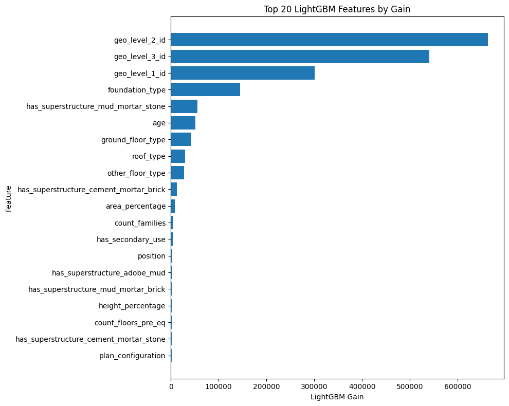

```python
top_n = 20

plot_df = (
    importance_df
    .head(top_n)
    .sort_values("gain")
)

plt.figure(figsize=(10, 8))

plt.barh(
    plot_df["feature"],
    plot_df["gain"]
)

plt.xlabel("LightGBM Gain")
plt.ylabel("Feature")
plt.title("Top 20 LightGBM Features by Gain")

plt.tight_layout()
plt.show()
```

## Hierarchical Geographic Identifiers

The feature-importance analysis shows that the three geographic IDs account for most of the LightGBM gain.

The geographic variables form a strict nested hierarchy:

geo_level_1 → geo_level_2 → geo_level_3

We therefore test whether explicitly representing combinations of the hierarchical IDs provides additional predictive information.

The following categorical identifiers will be created:

- geo1_geo2
- geo2_geo3
- geo1_geo2_geo3

These features are constructed only from existing geographic IDs and do not use the target, so they cannot introduce target leakage.

The original geographic IDs are retained for comparison.

```python
def add_geo_hierarchy_features(X_data):
    X_result = X_data.copy()

    X_result["geo1_geo2"] = (
        X_result["geo_level_1_id"].astype(str)
        + "_"
        + X_result["geo_level_2_id"].astype(str)
    )

    X_result["geo2_geo3"] = (
        X_result["geo_level_2_id"].astype(str)
        + "_"
        + X_result["geo_level_3_id"].astype(str)
    )

    X_result["geo1_geo2_geo3"] = (
        X_result["geo_level_1_id"].astype(str)
        + "_"
        + X_result["geo_level_2_id"].astype(str)
        + "_"
        + X_result["geo_level_3_id"].astype(str)
    )

    return X_result
```

```python
X_train_geo_hier = add_geo_hierarchy_features(
    X_train_lgb
)

X_valid_geo_hier = add_geo_hierarchy_features(
    X_valid_lgb
)

GEO_HIER_COLS = [
    "geo1_geo2",
    "geo2_geo3",
    "geo1_geo2_geo3"
]

print("Training shape:", X_train_geo_hier.shape)
print("Validation shape:", X_valid_geo_hier.shape)

print("\nHierarchy feature cardinality:")
for col in GEO_HIER_COLS:
    print(
        f"{col}: "
        f"{X_train_geo_hier[col].nunique():,} unique values"
    )
```

```
Training shape: (208480, 41)
Validation shape: (52121, 41)

Hierarchy feature cardinality:
geo1_geo2: 1,409 unique values
geo2_geo3: 11,380 unique values
geo1_geo2_geo3: 11,380 unique values
```

## Evaluate Hierarchical Geographic Features

The geographic hierarchy features have relatively high cardinality, but their cardinalities show that they are largely equivalent to the existing geographic IDs.

We nevertheless perform one controlled LightGBM experiment to verify whether explicitly representing the hierarchy provides any additional predictive signal.

The original geographic IDs are retained, and the three new hierarchy features are treated as categorical variables.

All other model hyperparameters remain unchanged from the current best LightGBM configuration.

```python
LGB_CATEGORICAL_COLS_HIER = (
    LGB_CATEGORICAL_COLS + GEO_HIER_COLS
)

X_train_geo_hier_lgb = X_train_geo_hier.copy()
X_valid_geo_hier_lgb = X_valid_geo_hier.copy()

for col in GEO_HIER_COLS:
    X_train_geo_hier_lgb[col] = (
        X_train_geo_hier_lgb[col]
        .astype("category")
    )

    X_valid_geo_hier_lgb[col] = (
        X_valid_geo_hier_lgb[col]
        .astype("category")
    )

print("Categorical hierarchy columns:")

for col in GEO_HIER_COLS:
    print(
        f"{col}: "
        f"{X_train_geo_hier_lgb[col].dtype}"
    )
```

```
Categorical hierarchy columns:
geo1_geo2: category
geo2_geo3: category
geo1_geo2_geo3: category
```

```python
lgb_geo_hier_model = lgb.LGBMClassifier(
    objective="multiclass",
    num_class=3,
    n_estimators=1000,
    learning_rate=0.03,
    num_leaves=15,
    min_child_samples=200,
    colsample_bytree=0.8,
    random_state=RANDOM_STATE,
    n_jobs=-1,
    force_col_wise=True
)

lgb_geo_hier_model.fit(
    X_train_geo_hier_lgb,
    y_train,
    categorical_feature=LGB_CATEGORICAL_COLS_HIER,
    eval_set=[(X_valid_geo_hier_lgb, y_valid)],
    callbacks=[
        lgb.early_stopping(
            stopping_rounds=50,
            verbose=True
        )
    ]
)
```

```
c:\Users\rakes\OneDrive\ITC Docs\Learning\Course Work\Earthquake_damage\course_work_use_case\.venv\Lib\site-packages\lightgbm\sklearn.py:1106: LGBMDeprecationWarning: The argument 'eval_set' is deprecated, use 'eval_X' and 'eval_y' instead.
  eval_set = _validate_eval_set_Xy(eval_set=eval_set, eval_X=eval_X, eval_y=eval_y)
```

```
[LightGBM] [Warning] Categorical features with more bins than the configured maximum bin number found.
[LightGBM] [Warning] For categorical features, max_bin and max_bin_by_feature may be ignored with a large number of categories.
[LightGBM] [Info] Total Bins 30676
[LightGBM] [Info] Number of data points in the train set: 208480, number of used features: 36
[LightGBM] [Info] Start training from score -2.339173
[LightGBM] [Info] Start training from score -0.564028
[LightGBM] [Info] Start training from score -1.094582
Training until validation scores don't improve for 50 rounds
Early stopping, best iteration is:
[747]	valid_0's multi_logloss: 0.553081
```

```
LGBMClassifier(colsample_bytree=0.8, force_col_wise=True, learning_rate=0.03,
               min_child_samples=200, n_estimators=1000, n_jobs=-1, num_class=3,
               num_leaves=15, objective='multiclass', random_state=42)
```

```python
y_valid_pred_geo_hier = (
    lgb_geo_hier_model.predict(
        X_valid_geo_hier_lgb
    )
)

geo_hier_micro_f1 = f1_score(
    y_valid,
    y_valid_pred_geo_hier,
    average="micro"
)

print(
    f"Validation Micro-F1: "
    f"{geo_hier_micro_f1:.4f}"
)

print(
    f"Best iteration: "
    f"{lgb_geo_hier_model.best_iteration_}"
)

print("\nClassification Report:")
print(
    classification_report(
        y_valid,
        y_valid_pred_geo_hier
    )
)

print("\nConfusion Matrix:")
print(
    confusion_matrix(
        y_valid,
        y_valid_pred_geo_hier
    )
)
```

```
Validation Micro-F1: 0.7520
Best iteration: 747

Classification Report:
              precision    recall  f1-score   support

           1       0.67      0.56      0.61      5025
           2       0.76      0.84      0.80     29652
           3       0.77      0.65      0.70     17444

    accuracy                           0.75     52121
   macro avg       0.73      0.69      0.70     52121
weighted avg       0.75      0.75      0.75     52121


Confusion Matrix:
[[ 2834  2098    93]
 [ 1243 25018  3391]
 [  127  5975 11342]]
```

## Analyze Foundation Type

Foundation type is the strongest non-geographic feature in the current LightGBM model, accounting for approximately 7.6% of total gain.

We examine the damage-grade distribution across foundation types to understand how strongly foundation construction is associated with building damage.

This is exploratory analysis only. The target is used for analysis, not for creating model features, so there is no target leakage.

```python
foundation_eda = (
    pd.crosstab(
        X_train_lgb["foundation_type"],
        y_train,
        normalize="index"
    )
    .rename(columns={
        1: "grade_1_pct",
        2: "grade_2_pct",
        3: "grade_3_pct"
    })
)

foundation_counts = (
    X_train_lgb["foundation_type"]
    .value_counts()
    .rename("n_buildings")
)

foundation_eda = (
    foundation_eda
    .join(foundation_counts)
    .sort_values("grade_3_pct", ascending=False)
)

print(foundation_eda)

print("\nFoundation type counts:")
print(
    X_train_lgb["foundation_type"]
    .value_counts()
)
```

```
                 grade_1_pct  grade_2_pct  grade_3_pct  n_buildings
foundation_type
r                   0.049056     0.572426     0.378518       175413
h                   0.259356     0.389904     0.350740         1149
u                   0.256244     0.603015     0.140741        11411
w                   0.288183     0.612930     0.098886        12034
i                   0.566977     0.412015     0.021008         8473

Foundation type counts:
foundation_type
r    175413
w     12034
u     11411
i      8473
h      1149
Name: count, dtype: int64
```

## Step 46 — Analyze Foundation and Superstructure Relationships

Foundation type is the strongest non-geographic predictor in the current LightGBM model.

We now investigate whether foundation categories are associated with different structural-material compositions.

The superstructure variables are binary indicators describing construction materials. We calculate the proportion of buildings within each foundation category that have each superstructure type.

This is exploratory analysis only and does not use these relationships to construct target-derived features.

```python
foundation_superstructure = (
    X_train_lgb
    .groupby("foundation_type")[SUPERSTRUCTURE_COLS]
    .mean()
    .multiply(100)
    .round(2)
)

print(
    "Superstructure percentage within each foundation type:"
)

display(foundation_superstructure)
```

```
Superstructure percentage within each foundation type:
```

| foundation_type | has_superstructure_adobe_mud | has_superstructure_mud_mortar_stone | has_superstructure_stone_flag | has_superstructure_cement_mortar_stone | has_superstructure_mud_mortar_brick | has_superstructure_cement_mortar_brick | has_superstructure_timber | has_superstructure_bamboo | has_superstructure_rc_non_engineered | has_superstructure_rc_engineered | has_superstructure_other |
| --- | --- | --- | --- | --- | --- | --- | --- | --- | --- | --- | --- |
| h | 15.58 | 14.36 | 36.12 | 1.31 | 3.13 | 9.40 | 52.48 | 13.32 | 2.00 | 0.35 | 20.10 |
| i | 0.32 | 1.91 | 0.38 | 6.16 | 1.50 | 39.12 | 2.29 | 0.39 | 53.19 | 34.57 | 0.35 |
| r | 10.07 | 86.21 | 3.55 | 1.01 | 7.56 | 2.87 | 23.10 | 6.83 | 1.72 | 0.05 | 1.34 |
| u | 2.87 | 29.92 | 2.24 | 12.48 | 5.30 | 54.80 | 16.78 | 4.00 | 8.79 | 2.61 | 1.93 |
| w | 2.24 | 33.16 | 1.82 | 1.06 | 1.25 | 7.91 | 81.93 | 41.86 | 2.71 | 0.04 | 2.93 |

```python
# Damage distribution for foundation × selected superstructure combinations

selected_superstructures = [
    "has_superstructure_mud_mortar_stone",
    "has_superstructure_timber",
    "has_superstructure_rc_non_engineered",
]

for super_col in selected_superstructures:
    print(f"\n{'=' * 80}")
    print(super_col)
    print(f"{'=' * 80}")

    subset = X_train_lgb[[ID_COL] if ID_COL in X_train_lgb.columns else []].copy()

    # Add the required columns
    subset["foundation_type"] = X_train_lgb["foundation_type"].values
    subset[super_col] = X_train_lgb[super_col].values
    subset["damage_grade"] = y_train.values

    # Only buildings where this superstructure is present
    subset = subset[subset[super_col] == 1]

    damage_distribution = pd.crosstab(
        subset["foundation_type"],
        subset["damage_grade"],
        normalize="index"
    ).mul(100).round(2)

    counts = subset["foundation_type"].value_counts().sort_index()

    damage_distribution["n_buildings"] = counts

    display(damage_distribution)
```

```
================================================================================
has_superstructure_mud_mortar_stone
================================================================================
```

| damage_grade foundation_type | 1 | 2 | 3 | n_buildings |
| --- | --- | --- | --- | --- |
| h | 24.85 | 44.24 | 30.91 | 165 |
| i | 22.22 | 64.81 | 12.96 | 162 |
| r | 4.10 | 56.82 | 39.08 | 151226 |
| u | 6.71 | 62.65 | 30.64 | 3414 |
| w | 13.88 | 73.37 | 12.75 | 3991 |

```
================================================================================
has_superstructure_timber
================================================================================
```

| damage_grade foundation_type | 1 | 2 | 3 | n_buildings |
| --- | --- | --- | --- | --- |
| h | 22.89 | 33.67 | 43.45 | 603 |
| i | 36.60 | 55.67 | 7.73 | 194 |
| r | 6.53 | 60.41 | 33.06 | 40521 |
| u | 19.11 | 66.06 | 14.83 | 1915 |
| w | 29.67 | 61.28 | 9.05 | 9859 |

```
================================================================================
has_superstructure_rc_non_engineered
================================================================================
```

| damage_grade foundation_type | 1 | 2 | 3 | n_buildings |
| --- | --- | --- | --- | --- |
| h | 43.48 | 26.09 | 30.43 | 23 |
| i | 53.47 | 44.42 | 2.11 | 4507 |
| r | 8.63 | 61.15 | 30.23 | 3014 |
| u | 32.10 | 60.42 | 7.48 | 1003 |
| w | 21.47 | 69.94 | 8.59 | 326 |

```python
selected_superstructures = [
    "has_superstructure_mud_mortar_stone",
    "has_superstructure_timber",
    "has_superstructure_rc_non_engineered",
]

for super_col in selected_superstructures:
    print(f"\n{'=' * 80}")
    print(super_col)
    print(f"{'=' * 80}")

    subset = pd.DataFrame({
        "foundation_type": X_train_lgb["foundation_type"].values,
        "superstructure": X_train_lgb[super_col].values,
        "damage_grade": y_train.values
    })

    # Keep only buildings with this superstructure
    subset = subset[subset["superstructure"] == 1]

    damage_distribution = (
        pd.crosstab(
            subset["foundation_type"],
            subset["damage_grade"],
            normalize="index"
        )
        .mul(100)
        .round(2)
    )

    counts = (
        subset["foundation_type"]
        .value_counts()
        .sort_index()
        .rename("n_buildings")
    )

    result = damage_distribution.join(counts)

    display(result)
```

```
================================================================================
has_superstructure_mud_mortar_stone
================================================================================
```

| foundation_type | 1 | 2 | 3 | n_buildings |
| --- | --- | --- | --- | --- |
| h | 24.85 | 44.24 | 30.91 | 165 |
| i | 22.22 | 64.81 | 12.96 | 162 |
| r | 4.10 | 56.82 | 39.08 | 151226 |
| u | 6.71 | 62.65 | 30.64 | 3414 |
| w | 13.88 | 73.37 | 12.75 | 3991 |

```
================================================================================
has_superstructure_timber
================================================================================
```

| foundation_type | 1 | 2 | 3 | n_buildings |
| --- | --- | --- | --- | --- |
| h | 22.89 | 33.67 | 43.45 | 603 |
| i | 36.60 | 55.67 | 7.73 | 194 |
| r | 6.53 | 60.41 | 33.06 | 40521 |
| u | 19.11 | 66.06 | 14.83 | 1915 |
| w | 29.67 | 61.28 | 9.05 | 9859 |

```
================================================================================
has_superstructure_rc_non_engineered
================================================================================
```

| foundation_type | 1 | 2 | 3 | n_buildings |
| --- | --- | --- | --- | --- |
| h | 43.48 | 26.09 | 30.43 | 23 |
| i | 53.47 | 44.42 | 2.11 | 4507 |
| r | 8.63 | 61.15 | 30.23 | 3014 |
| u | 32.10 | 60.42 | 7.48 | 1003 |
| w | 21.47 | 69.94 | 8.59 | 326 |

## Step 47 — Measure Categorical Association with Cramér's V

Cramér's V measures the strength of association between two categorical variables.

We use it to quantify relationships between:

- `foundation_type` and `damage_grade`
- superstructure types and `damage_grade`
- `foundation_type` and individual superstructure types

This helps distinguish features that are genuinely associated with damage from features that are mainly redundant with other structural variables.

Cramér's V ranges from 0 to 1:

- 0 = no association
- 1 = perfect association

This is an exploratory analysis and does not by itself determine which features should be removed from the model.

```python
from scipy.stats import chi2_contingency
import pandas as pd
import numpy as np


def cramers_v(x, y):
    """
    Calculate Cramér's V for two categorical variables.
    """
    contingency_table = pd.crosstab(x, y)

    chi2 = chi2_contingency(contingency_table)[0]
    n = contingency_table.to_numpy().sum()

    r, k = contingency_table.shape

    phi2 = chi2 / n

    # Bias correction
    phi2_corrected = max(
        0,
        phi2 - ((k - 1) * (r - 1)) / (n - 1)
    )

    r_corrected = r - ((r - 1) ** 2) / (n - 1)
    k_corrected = k - ((k - 1) ** 2) / (n - 1)

    denominator = min(k_corrected - 1, r_corrected - 1)

    if denominator <= 0:
        return np.nan

    return np.sqrt(phi2_corrected / denominator)


# ---------------------------------------------------------
# 1. Foundation type vs damage grade
# ---------------------------------------------------------

foundation_damage_v = cramers_v(
    X_train_lgb["foundation_type"],
    y_train
)

print(
    f"Foundation type vs damage grade: "
    f"Cramér's V = {foundation_damage_v:.4f}"
)


# ---------------------------------------------------------
# 2. Superstructure features vs damage grade
# ---------------------------------------------------------

superstructure_damage_results = []

for col in SUPERSTRUCTURE_COLS:
    value = cramers_v(
        X_train_lgb[col],
        y_train
    )

    superstructure_damage_results.append({
        "feature": col,
        "cramers_v": value
    })

superstructure_damage_results = (
    pd.DataFrame(superstructure_damage_results)
    .sort_values("cramers_v", ascending=False)
    .reset_index(drop=True)
)

display(superstructure_damage_results)


# ---------------------------------------------------------
# 3. Foundation type vs each superstructure feature
# ---------------------------------------------------------

foundation_superstructure_results = []

for col in SUPERSTRUCTURE_COLS:
    value = cramers_v(
        X_train_lgb["foundation_type"],
        X_train_lgb[col]
    )

    foundation_superstructure_results.append({
        "superstructure": col,
        "cramers_v": value
    })

foundation_superstructure_results = (
    pd.DataFrame(foundation_superstructure_results)
    .sort_values("cramers_v", ascending=False)
    .reset_index(drop=True)
)

display(foundation_superstructure_results)
```

```
Foundation type vs damage grade: Cramér's V = 0.3048
```

|  | feature | cramers_v |
| --- | --- | --- |
| 0 | has_superstructure_mud_mortar_stone | 0.334272 |
| 1 | has_superstructure_cement_mortar_brick | 0.277465 |
| 2 | has_superstructure_rc_engineered | 0.236977 |
| 3 | has_superstructure_rc_non_engineered | 0.186259 |
| 4 | has_superstructure_adobe_mud | 0.075179 |
| 5 | has_superstructure_timber | 0.071885 |
| 6 | has_superstructure_stone_flag | 0.064561 |
| 7 | has_superstructure_bamboo | 0.063788 |
| 8 | has_superstructure_mud_mortar_brick | 0.062858 |
| 9 | has_superstructure_cement_mortar_stone | 0.062784 |
| 10 | has_superstructure_other | 0.034793 |

|  | superstructure | cramers_v |
| --- | --- | --- |
| 0 | has_superstructure_mud_mortar_stone | 0.552973 |
| 1 | has_superstructure_rc_engineered | 0.543980 |
| 2 | has_superstructure_cement_mortar_brick | 0.510623 |
| 3 | has_superstructure_rc_non_engineered | 0.505269 |
| 4 | has_superstructure_timber | 0.339410 |
| 5 | has_superstructure_bamboo | 0.301486 |
| 6 | has_superstructure_cement_mortar_stone | 0.203805 |
| 7 | has_superstructure_stone_flag | 0.140161 |
| 8 | has_superstructure_other | 0.118268 |
| 9 | has_superstructure_adobe_mud | 0.105147 |
| 10 | has_superstructure_mud_mortar_brick | 0.075195 |

## Step 48 — Robust Cross-Validation Benchmark

The previous experiments used a single stratified validation split. Since we have now used that validation set repeatedly for model selection, its score is no longer an unbiased estimate of final generalization performance.

We will now evaluate the selected LightGBM configuration using Stratified K-Fold cross-validation.

Why Stratified K-Fold?

- The target has three damage grades with substantial class imbalance.
- Stratification preserves approximately the same class proportions in every fold.
- Multiple validation folds provide a more stable estimate than a single split.
- We will report the Micro-F1 score for every fold as well as the mean and standard deviation.

For this benchmark we will use the best configuration found so far rather than performing another expensive hyperparameter search.

Important: Micro-F1 is equal to accuracy for this single-label multiclass problem, so both metrics will have the same value.

```python
from sklearn.model_selection import StratifiedKFold
from sklearn.metrics import f1_score, accuracy_score
import lightgbm as lgb
import numpy as np
import pandas as pd
import time


# Best configuration found during our previous experiments
cv_model_params = {
    "objective": "multiclass",
    "num_class": 3,
    "n_estimators": 1200,
    "learning_rate": 0.03,
    "num_leaves": 15,
    "min_child_samples": 200,
    "colsample_bytree": 0.8,
    "subsample": 0.8,
    "subsample_freq": 1,
    "max_depth": -1,
    "random_state": RANDOM_STATE,
    "n_jobs": -1,
    "force_col_wise": True
}


# Stratified 5-fold cross-validation
skf = StratifiedKFold(
    n_splits=5,
    shuffle=True,
    random_state=RANDOM_STATE
)


cv_results = []

start_time = time.time()

for fold, (train_idx, valid_idx) in enumerate(
    skf.split(X, y),
    start=1
):
    print(f"\n{'=' * 60}")
    print(f"Fold {fold}/5")
    print(f"{'=' * 60}")

    X_fold_train = X.iloc[train_idx].copy()
    X_fold_valid = X.iloc[valid_idx].copy()

    y_fold_train = y.iloc[train_idx]
    y_fold_valid = y.iloc[valid_idx]

    # Convert categorical columns to pandas category dtype
    for col in LGB_CATEGORICAL_COLS:
        X_fold_train[col] = X_fold_train[col].astype("category")
        X_fold_valid[col] = X_fold_valid[col].astype("category")

    model = lgb.LGBMClassifier(**cv_model_params)

    model.fit(
        X_fold_train,
        y_fold_train,
        categorical_feature=LGB_CATEGORICAL_COLS
    )

    y_fold_pred = model.predict(X_fold_valid)

    accuracy = accuracy_score(
        y_fold_valid,
        y_fold_pred
    )

    micro_f1 = f1_score(
        y_fold_valid,
        y_fold_pred,
        average="micro"
    )

    macro_f1 = f1_score(
        y_fold_valid,
        y_fold_pred,
        average="macro"
    )

    weighted_f1 = f1_score(
        y_fold_valid,
        y_fold_pred,
        average="weighted"
    )

    cv_results.append({
        "fold": fold,
        "accuracy": accuracy,
        "micro_f1": micro_f1,
        "macro_f1": macro_f1,
        "weighted_f1": weighted_f1
    })

    print(f"Accuracy:    {accuracy:.4f}")
    print(f"Micro-F1:    {micro_f1:.4f}")
    print(f"Macro-F1:    {macro_f1:.4f}")
    print(f"Weighted-F1: {weighted_f1:.4f}")


cv_results_df = pd.DataFrame(cv_results)

elapsed_minutes = (time.time() - start_time) / 60

print(f"\nTotal CV time: {elapsed_minutes:.2f} minutes")

display(cv_results_df)


print("\nCross-validation summary:")
print(
    f"Mean Micro-F1: {cv_results_df['micro_f1'].mean():.4f}"
)
print(
    f"Std Micro-F1:  {cv_results_df['micro_f1'].std():.4f}"
)
print(
    f"Min Micro-F1:  {cv_results_df['micro_f1'].min():.4f}"
)
print(
    f"Max Micro-F1:  {cv_results_df['micro_f1'].max():.4f}"
)
```

```
============================================================
Fold 1/5
============================================================
[LightGBM] [Warning] Categorical features with more bins than the configured maximum bin number found.
[LightGBM] [Warning] For categorical features, max_bin and max_bin_by_feature may be ignored with a large number of categories.
[LightGBM] [Info] Total Bins 10806
[LightGBM] [Info] Number of data points in the train set: 208480, number of used features: 33
[LightGBM] [Info] Start training from score -2.339173
[LightGBM] [Info] Start training from score -0.564028
[LightGBM] [Info] Start training from score -1.094582
Accuracy:    0.7476
Micro-F1:    0.7476
Macro-F1:    0.7001
Weighted-F1: 0.7439

============================================================
Fold 2/5
============================================================
[LightGBM] [Warning] Categorical features with more bins than the configured maximum bin number found.
[LightGBM] [Warning] For categorical features, max_bin and max_bin_by_feature may be ignored with a large number of categories.
[LightGBM] [Info] Total Bins 10778
[LightGBM] [Info] Number of data points in the train set: 208481, number of used features: 33
[LightGBM] [Info] Start training from score -2.339128
[LightGBM] [Info] Start training from score -0.564032
[LightGBM] [Info] Start training from score -1.094586
Accuracy:    0.7489
Micro-F1:    0.7489
Macro-F1:    0.7020
Weighted-F1: 0.7449

============================================================
Fold 3/5
============================================================
[LightGBM] [Warning] Categorical features with more bins than the configured maximum bin number found.
[LightGBM] [Warning] For categorical features, max_bin and max_bin_by_feature may be ignored with a large number of categories.
[LightGBM] [Info] Total Bins 10774
[LightGBM] [Info] Number of data points in the train set: 208481, number of used features: 34
[LightGBM] [Info] Start training from score -2.339178
[LightGBM] [Info] Start training from score -0.564024
[LightGBM] [Info] Start training from score -1.094586
```

[output cut: 21 more lines]

```
Fold 5/5
============================================================
[LightGBM] [Warning] Categorical features with more bins than the configured maximum bin number found.
[LightGBM] [Warning] For categorical features, max_bin and max_bin_by_feature may be ignored with a large number of categories.
[LightGBM] [Info] Total Bins 10748
[LightGBM] [Info] Number of data points in the train set: 208481, number of used features: 33
[LightGBM] [Info] Start training from score -2.339178
[LightGBM] [Info] Start training from score -0.564032
[LightGBM] [Info] Start training from score -1.094572
Accuracy:    0.7475
Micro-F1:    0.7475
Macro-F1:    0.7007
Weighted-F1: 0.7435

Total CV time: 5.87 minutes
```

|  | fold | accuracy | micro_f1 | macro_f1 | weighted_f1 |
| --- | --- | --- | --- | --- | --- |
| 0 | 1 | 0.747568 | 0.747568 | 0.700063 | 0.743873 |
| 1 | 2 | 0.748868 | 0.748868 | 0.701952 | 0.744894 |
| 2 | 3 | 0.750096 | 0.750096 | 0.702546 | 0.746162 |
| 3 | 4 | 0.749693 | 0.749693 | 0.702883 | 0.745935 |
| 4 | 5 | 0.747487 | 0.747487 | 0.700655 | 0.743499 |

```
Cross-validation summary:
Mean Micro-F1: 0.7487
Std Micro-F1:  0.0012
Min Micro-F1:  0.7475
Max Micro-F1:  0.7501
```

## Step 49 — Cross-Validation Error Analysis

The target `damage_grade` is ordinal:

1 = low damage 2 = medium damage 3 = severe damage

Therefore, not all classification errors are equally informative.

For example:

- predicting Grade 2 for a true Grade 1 is an adjacent error;
- predicting Grade 3 for a true Grade 1 is a two-level error.

We will examine the cross-validation predictions to determine:

1. Which damage grades are hardest to predict.
2. Which grade pairs are most commonly confused.
3. Whether errors are predominantly adjacent ordinal errors.
4. Whether the model systematically underpredicts or overpredicts damage severity.

This will guide the next modeling decision.

```python
from sklearn.metrics import (
    confusion_matrix,
    classification_report,
    f1_score,
    accuracy_score
)

# Store out-of-fold predictions
oof_predictions = np.empty(len(y), dtype=int)

for fold, (train_idx, valid_idx) in enumerate(
    skf.split(X, y),
    start=1
):
    X_fold_train = X.iloc[train_idx].copy()
    X_fold_valid = X.iloc[valid_idx].copy()

    y_fold_train = y.iloc[train_idx]
    y_fold_valid = y.iloc[valid_idx]

    for col in LGB_CATEGORICAL_COLS:
        X_fold_train[col] = X_fold_train[col].astype("category")
        X_fold_valid[col] = X_fold_valid[col].astype("category")

    model = lgb.LGBMClassifier(**cv_model_params)

    model.fit(
        X_fold_train,
        y_fold_train,
        categorical_feature=LGB_CATEGORICAL_COLS
    )

    oof_predictions[valid_idx] = model.predict(
        X_fold_valid
    ).astype(int)


# ---------------------------------------------------------
# Overall metrics
# ---------------------------------------------------------

print("OOF Accuracy:", accuracy_score(y, oof_predictions))
print(
    "OOF Micro-F1:",
    f1_score(y, oof_predictions, average="micro")
)
print(
    "OOF Macro-F1:",
    f1_score(y, oof_predictions, average="macro")
)
print(
    "OOF Weighted-F1:",
    f1_score(y, oof_predictions, average="weighted")
)


# ---------------------------------------------------------
# Confusion matrix
# ---------------------------------------------------------

cm = confusion_matrix(
    y,
    oof_predictions,
    labels=[1, 2, 3]
)

cm_df = pd.DataFrame(
    cm,
    index=["True 1", "True 2", "True 3"],
    columns=["Pred 1", "Pred 2", "Pred 3"]
)

display(cm_df)


# ---------------------------------------------------------
# Per-class classification report
# ---------------------------------------------------------

report = classification_report(
    y,
    oof_predictions,
    labels=[1, 2, 3],
    target_names=[
        "Grade 1",
        "Grade 2",
        "Grade 3"
    ],
    output_dict=True
)

report_df = pd.DataFrame(report).T

display(
    report_df.loc[
        ["Grade 1", "Grade 2", "Grade 3"],
        ["precision", "recall", "f1-score", "support"]
    ]
)


# ---------------------------------------------------------
# Ordinal error analysis
# ---------------------------------------------------------

y_array = y.to_numpy()

error_mask = y_array != oof_predictions

ordinal_distance = np.abs(
    y_array - oof_predictions
)

adjacent_errors = np.sum(
    error_mask & (ordinal_distance == 1)
)

two_level_errors = np.sum(
    error_mask & (ordinal_distance == 2)
)

total_errors = np.sum(error_mask)

print(f"Total errors:              {total_errors:,}")
print(f"Adjacent errors:           {adjacent_errors:,}")
print(f"Two-level errors:          {two_level_errors:,}")

if total_errors > 0:
    print(
        f"Adjacent error percentage: "
        f"{adjacent_errors / total_errors:.2%}"
    )
    print(
        f"Two-level error percentage: "
        f"{two_level_errors / total_errors:.2%}"
    )


# ---------------------------------------------------------
# Error rate by true grade
# ---------------------------------------------------------

error_by_grade = []

for grade in [1, 2, 3]:
    mask = y_array == grade

    total = mask.sum()
    errors = np.sum(
        mask & (oof_predictions != grade)
    )

    error_by_grade.append({
        "true_grade": grade,
        "n_samples": total,
        "n_errors": errors,
        "error_rate": errors / total
    })

error_by_grade_df = pd.DataFrame(error_by_grade)

display(error_by_grade_df)
```

```
[LightGBM] [Warning] Categorical features with more bins than the configured maximum bin number found.
[LightGBM] [Warning] For categorical features, max_bin and max_bin_by_feature may be ignored with a large number of categories.
[LightGBM] [Info] Total Bins 10806
[LightGBM] [Info] Number of data points in the train set: 208480, number of used features: 33
[LightGBM] [Info] Start training from score -2.339173
[LightGBM] [Info] Start training from score -0.564028
[LightGBM] [Info] Start training from score -1.094582
[LightGBM] [Warning] Categorical features with more bins than the configured maximum bin number found.
[LightGBM] [Warning] For categorical features, max_bin and max_bin_by_feature may be ignored with a large number of categories.
[LightGBM] [Info] Total Bins 10778
[LightGBM] [Info] Number of data points in the train set: 208481, number of used features: 33
[LightGBM] [Info] Start training from score -2.339128
[LightGBM] [Info] Start training from score -0.564032
[LightGBM] [Info] Start training from score -1.094586
[LightGBM] [Warning] Categorical features with more bins than the configured maximum bin number found.
[LightGBM] [Warning] For categorical features, max_bin and max_bin_by_feature may be ignored with a large number of categories.
[LightGBM] [Info] Total Bins 10774
[LightGBM] [Info] Number of data points in the train set: 208481, number of used features: 34
[LightGBM] [Info] Start training from score -2.339178
[LightGBM] [Info] Start training from score -0.564024
[LightGBM] [Info] Start training from score -1.094586
[LightGBM] [Warning] Categorical features with more bins than the configured maximum bin number found.
[LightGBM] [Warning] For categorical features, max_bin and max_bin_by_feature may be ignored with a large number of categories.
[LightGBM] [Info] Total Bins 10791
[LightGBM] [Info] Number of data points in the train set: 208481, number of used features: 34
[LightGBM] [Info] Start training from score -2.339178
[LightGBM] [Info] Start training from score -0.564032
[LightGBM] [Info] Start training from score -1.094572
[LightGBM] [Warning] Categorical features with more bins than the configured maximum bin number found.
[LightGBM] [Warning] For categorical features, max_bin and max_bin_by_feature may be ignored with a large number of categories.
[LightGBM] [Info] Total Bins 10748
[LightGBM] [Info] Number of data points in the train set: 208481, number of used features: 33
[LightGBM] [Info] Start training from score -2.339178
[LightGBM] [Info] Start training from score -0.564032
[LightGBM] [Info] Start training from score -1.094572
OOF Accuracy: 0.7487423302289707
OOF Micro-F1: 0.7487423302289707
OOF Macro-F1: 0.7016182439751679
OOF Weighted-F1: 0.7448725198493501
```

|  | Pred 1 | Pred 2 | Pred 3 |
| --- | --- | --- | --- |
| True 1 | 14060 | 10635 | 429 |
| True 2 | 6131 | 124623 | 17505 |
| True 3 | 663 | 30115 | 56440 |

|  | precision | recall | f1-score | support |
| --- | --- | --- | --- | --- |
| Grade 1 | 0.674211 | 0.559624 | 0.611597 | 25124.0 |
| Grade 2 | 0.753587 | 0.840576 | 0.794708 | 148259.0 |
| Grade 3 | 0.758867 | 0.647114 | 0.698549 | 87218.0 |

```
Total errors:              65,478
Adjacent errors:           64,386
Two-level errors:          1,092
Adjacent error percentage: 98.33%
Two-level error percentage: 1.67%
```

|  | true_grade | n_samples | n_errors | error_rate |
| --- | --- | --- | --- | --- |
| 0 | 1 | 25124 | 11064 | 0.440376 |
| 1 | 2 | 148259 | 23636 | 0.159424 |
| 2 | 3 | 87218 | 30778 | 0.352886 |

## Step 51 — XGBoost Multiclass Baseline

We now move from LightGBM to XGBoost.

The purpose of this experiment is to establish a comparable XGBoost benchmark using the same training/validation framework.

We will:

- use the original structural and geographic features;
- one-hot encode the low-cardinality categorical variables;
- retain the geographic IDs as numeric features;
- use the same Stratified K-Fold strategy;
- evaluate using Micro-F1;
- report Macro-F1 as a secondary metric.

We will initially avoid:

- target encoding;
- additional feature engineering;
- another expensive grid search.

This gives us a clean comparison between LightGBM and XGBoost.

Reference: LightGBM 5-fold CV Micro-F1 = approximately 0.7487 ± 0.0012.

```python
from sklearn.compose import ColumnTransformer
from sklearn.preprocessing import OneHotEncoder
from sklearn.model_selection import StratifiedKFold
from sklearn.metrics import (
    f1_score,
    accuracy_score,
    classification_report
)
from xgboost import XGBClassifier

import numpy as np
import pandas as pd
import time


# ---------------------------------------------------------
# Features
# ---------------------------------------------------------

X_xgb = X.copy()
y_xgb = y.copy()



# Categorical columns
XGB_CATEGORICAL_COLS = CATEGORICAL_COLS.copy()


# Numeric columns
XGB_NUMERIC_COLS = [
    col for col in X_xgb.columns
    if col not in XGB_CATEGORICAL_COLS
]


print("XGBoost numeric columns:", len(XGB_NUMERIC_COLS))
print("XGBoost categorical columns:", len(XGB_CATEGORICAL_COLS))
print("Total input columns:", X_xgb.shape[1])


# ---------------------------------------------------------
# One-hot encoding
# ---------------------------------------------------------

xgb_preprocessor = ColumnTransformer(
    transformers=[
        (
            "categorical",
            OneHotEncoder(
                handle_unknown="ignore",
                sparse_output=True
            ),
            XGB_CATEGORICAL_COLS
        ),
        (
            "numeric",
            "passthrough",
            XGB_NUMERIC_COLS
        )
    ]
)


X_xgb_encoded = xgb_preprocessor.fit_transform(X_xgb)


print("\nEncoded feature matrix shape:")
print(X_xgb_encoded.shape)
```

```
XGBoost numeric columns: 30
XGBoost categorical columns: 8
Total input columns: 38

Encoded feature matrix shape:
(260601, 68)
```

## Step 51B — Train the XGBoost Baseline

The baseline uses the histogram-based tree algorithm (`tree_method="hist"`) because the dataset contains approximately 260K training observations.

We use multiclass soft probabilities internally and convert them into the predicted damage grade.

The first objective is not to optimize every XGBoost parameter. It is to establish a reliable baseline that can be compared against LightGBM.

```python
# ---------------------------------------------------------
# XGBoost baseline parameters
# ---------------------------------------------------------

xgb_params = {
    "objective": "multi:softprob",
    "num_class": 3,

    "n_estimators": 800,
    "learning_rate": 0.05,

    "max_depth": 6,
    "min_child_weight": 1,

    "subsample": 0.8,
    "colsample_bytree": 0.8,

    "gamma": 0,

    "reg_alpha": 0,
    "reg_lambda": 1,

    "tree_method": "hist",

    "eval_metric": "mlogloss",

    "random_state": RANDOM_STATE,
    "n_jobs": -1
}


# ---------------------------------------------------------
# Stratified 5-fold CV
# ---------------------------------------------------------

skf_xgb = StratifiedKFold(
    n_splits=5,
    shuffle=True,
    random_state=RANDOM_STATE
)


xgb_cv_results = []

start_time = time.time()


for fold, (train_idx, valid_idx) in enumerate(
    skf_xgb.split(X_xgb_encoded, y_xgb),
    start=1
):

    print(f"\n{'=' * 60}")
    print(f"XGBoost Fold {fold}/5")
    print(f"{'=' * 60}")

    X_fold_train = X_xgb_encoded[train_idx]
    X_fold_valid = X_xgb_encoded[valid_idx]

    y_fold_train = y_xgb.iloc[train_idx]
    y_fold_valid = y_xgb.iloc[valid_idx]

    model = XGBClassifier(**xgb_params)

    model.fit(
        X_fold_train,
        y_fold_train - 1
    )

    y_pred = model.predict(
        X_fold_valid
    ).astype(int) + 1

    accuracy = accuracy_score(
        y_fold_valid,
        y_pred
    )

    micro_f1 = f1_score(
        y_fold_valid,
        y_pred,
        average="micro"
    )

    macro_f1 = f1_score(
        y_fold_valid,
        y_pred,
        average="macro"
    )

    weighted_f1 = f1_score(
        y_fold_valid,
        y_pred,
        average="weighted"
    )

    xgb_cv_results.append({
        "fold": fold,
        "accuracy": accuracy,
        "micro_f1": micro_f1,
        "macro_f1": macro_f1,
        "weighted_f1": weighted_f1
    })

    print(f"Accuracy:    {accuracy:.4f}")
    print(f"Micro-F1:    {micro_f1:.4f}")
    print(f"Macro-F1:    {macro_f1:.4f}")
    print(f"Weighted-F1: {weighted_f1:.4f}")


xgb_cv_results_df = pd.DataFrame(
    xgb_cv_results
)


elapsed_minutes = (
    time.time() - start_time
) / 60


print(f"\nTotal XGBoost CV time: {elapsed_minutes:.2f} minutes")

display(xgb_cv_results_df)


print("\nXGBoost Cross-validation summary:")

print(
    f"Mean Micro-F1: "
    f"{xgb_cv_results_df['micro_f1'].mean():.4f}"
)

print(
    f"Std Micro-F1:  "
    f"{xgb_cv_results_df['micro_f1'].std():.4f}"
)

print(
    f"Min Micro-F1:  "
    f"{xgb_cv_results_df['micro_f1'].min():.4f}"
)

print(
    f"Max Micro-F1:  "
    f"{xgb_cv_results_df['micro_f1'].max():.4f}"
)
```

```
============================================================
XGBoost Fold 1/5
============================================================
Accuracy:    0.7322
Micro-F1:    0.7322
Macro-F1:    0.6723
Weighted-F1: 0.7250

============================================================
XGBoost Fold 2/5
============================================================
Accuracy:    0.7323
Micro-F1:    0.7323
Macro-F1:    0.6716
Weighted-F1: 0.7245

============================================================
XGBoost Fold 3/5
============================================================
Accuracy:    0.7308
Micro-F1:    0.7308
Macro-F1:    0.6689
Weighted-F1: 0.7231

============================================================
XGBoost Fold 4/5
============================================================
Accuracy:    0.7338
Micro-F1:    0.7338
Macro-F1:    0.6761
Weighted-F1: 0.7264

============================================================
XGBoost Fold 5/5
============================================================
Accuracy:    0.7317
Micro-F1:    0.7317
Macro-F1:    0.6723
Weighted-F1: 0.7241

Total XGBoost CV time: 2.82 minutes
```

|  | fold | accuracy | micro_f1 | macro_f1 | weighted_f1 |
| --- | --- | --- | --- | --- | --- |
| 0 | 1 | 0.732162 | 0.732162 | 0.672251 | 0.725023 |
| 1 | 2 | 0.732272 | 0.732272 | 0.671612 | 0.724532 |
| 2 | 3 | 0.730833 | 0.730833 | 0.668950 | 0.723077 |
| 3 | 4 | 0.733807 | 0.733807 | 0.676125 | 0.726392 |
| 4 | 5 | 0.731677 | 0.731677 | 0.672280 | 0.724147 |

```
XGBoost Cross-validation summary:
Mean Micro-F1: 0.7321
Std Micro-F1:  0.0011
Min Micro-F1:  0.7308
Max Micro-F1:  0.7338
```

## Step 52 — SHAP Model Explainability

We have now compared the main candidate models:

- Logistic Regression
- Random Forest
- XGBoost
- LightGBM

LightGBM is the strongest model based on cross-validation Micro-F1.

We will therefore use SHAP (SHapley Additive exPlanations) to interpret the selected LightGBM model.

The analysis will focus on:

1. Global feature importance.
2. Which features most strongly influence severe damage (Grade 3).
3. The direction of important feature effects where possible.
4. Whether geographic variables dominate the model.
5. Whether structural characteristics such as foundation type, superstructure and building age remain important after geographic information is considered.

SHAP is being used for interpretation rather than feature selection. A feature with high SHAP importance is not automatically a feature that should be removed or retained without considering model performance and domain meaning.

```python
# ---------------------------------------------------------
# Identify the LightGBM training/validation objects
# ---------------------------------------------------------

print("Available objects:")
for name in [
    "X_train",
    "X_valid",
    "X_train_geo",
    "X_valid_geo",
    "X_train_features",
    "X_valid_features"
]:
    if name in globals():
        obj = globals()[name]
        print(f"{name}: {obj.shape}")
```

```
Available objects:
X_train: (208480, 38)
X_valid: (52121, 38)
X_train_geo: (208480, 41)
X_valid_geo: (52121, 41)
```

```python
# Train the LGB model for SHAP

import lightgbm as lgb
import numpy as np
import pandas as pd

# ---------------------------------------------------------
# Use the validated 41-feature geographic model
# ---------------------------------------------------------

X_shap_train = X_train_geo.copy()
X_shap_valid = X_valid_geo.copy()

y_shap_train = y_train.copy()
y_shap_valid = y_valid.copy()


print("Training shape:", X_shap_train.shape)
print("Validation shape:", X_shap_valid.shape)


# ---------------------------------------------------------
# Identify categorical columns actually present
# ---------------------------------------------------------

LGBM_CATEGORICAL_COLS = [
    col for col in CATEGORICAL_COLS
    if col in X_shap_train.columns
]

print("\nCategorical columns:")
print(LGBM_CATEGORICAL_COLS)


# ---------------------------------------------------------
# Make categorical columns explicit
# ---------------------------------------------------------

for col in LGBM_CATEGORICAL_COLS:
    X_shap_train[col] = X_shap_train[col].astype("category")
    X_shap_valid[col] = X_shap_valid[col].astype("category")

    # Make validation categories identical to training categories
    X_shap_valid[col] = X_shap_valid[col].cat.set_categories(
        X_shap_train[col].cat.categories
    )


# ---------------------------------------------------------
# LightGBM model
#
# Parameters based on our previous experiments.
# num_leaves = 15
# min_child_samples = 200
# subsample = 0.8
# colsample_bytree = 0.8
# ---------------------------------------------------------

shap_lgbm = lgb.LGBMClassifier(
    objective="multiclass",
    num_class=3,

    n_estimators=1000,
    learning_rate=0.05,

    num_leaves=15,
    min_child_samples=200,

    subsample=0.8,
    colsample_bytree=0.8,

    reg_alpha=0,
    reg_lambda=0,

    random_state=RANDOM_STATE,
    n_jobs=-1,

    verbosity=-1
)


# ---------------------------------------------------------
# Train with early stopping
# ---------------------------------------------------------

shap_lgbm.fit(
    X_shap_train,
    y_shap_train,

    categorical_feature=LGBM_CATEGORICAL_COLS,

    eval_set=[
        (X_shap_valid, y_shap_valid)
    ],

    callbacks=[
        lgb.early_stopping(
            stopping_rounds=100,
            verbose=False
        )
    ]
)


print("\nBest iteration:", shap_lgbm.best_iteration_)
```

```
Training shape: (208480, 41)
Validation shape: (52121, 41)

Categorical columns:
['land_surface_condition', 'foundation_type', 'roof_type', 'ground_floor_type', 'other_floor_type', 'position', 'plan_configuration', 'legal_ownership_status']
```

```
c:\Users\rakes\OneDrive\ITC Docs\Learning\Course Work\Earthquake_damage\course_work_use_case\.venv\Lib\site-packages\lightgbm\sklearn.py:1106: LGBMDeprecationWarning: The argument 'eval_set' is deprecated, use 'eval_X' and 'eval_y' instead.
  eval_set = _validate_eval_set_Xy(eval_set=eval_set, eval_X=eval_X, eval_y=eval_y)
```

```
Best iteration: 1000
```

```python
#Verify the model before SHAP
from sklearn.metrics import f1_score, accuracy_score

y_shap_pred = shap_lgbm.predict(X_shap_valid)

print("Validation Accuracy:",
      accuracy_score(y_shap_valid, y_shap_pred))

print("Validation Micro-F1:",
      f1_score(
          y_shap_valid,
          y_shap_pred,
          average="micro"
      ))

print("Validation Macro-F1:",
      f1_score(
          y_shap_valid,
          y_shap_pred,
          average="macro"
      ))
```

```
Validation Accuracy: 0.7439995395330097
Validation Micro-F1: 0.7439995395330097
Validation Macro-F1: 0.6854983899002338
```

```python
# ---------------------------------------------------------
# LightGBM model for SHAP
# Original 38-feature dataset
# ---------------------------------------------------------

X_shap_train = X_train.copy()
X_shap_valid = X_valid.copy()

y_shap_train = y_train.copy()
y_shap_valid = y_valid.copy()


# Convert categorical columns
for col in CATEGORICAL_COLS:
    X_shap_train[col] = X_shap_train[col].astype("category")
    X_shap_valid[col] = X_shap_valid[col].astype("category")

    # Ensure identical category definitions
    X_shap_valid[col] = X_shap_valid[col].cat.set_categories(
        X_shap_train[col].cat.categories
    )


# All categorical features, including geographic IDs
LGBM_SHAP_CATEGORICAL_COLS = [
    col for col in GEO_COLS + CATEGORICAL_COLS
    if col in X_shap_train.columns
]


shap_lgbm = lgb.LGBMClassifier(
    objective="multiclass",
    num_class=3,

    n_estimators=1200,
    learning_rate=0.03,

    num_leaves=15,
    min_child_samples=200,

    colsample_bytree=0.8,

    # Explicitly activate row subsampling
    subsample=0.8,
    subsample_freq=1,

    max_depth=-1,

    random_state=RANDOM_STATE,
    n_jobs=-1,

    force_col_wise=True,
    verbosity=-1
)


shap_lgbm.fit(
    X_shap_train,
    y_shap_train,

    categorical_feature=LGBM_SHAP_CATEGORICAL_COLS,

    eval_set=[
        (X_shap_valid, y_shap_valid)
    ],

    callbacks=[
        lgb.early_stopping(
            stopping_rounds=100,
            verbose=False
        )
    ]
)


print("Best iteration:", shap_lgbm.best_iteration_)
```

```
c:\Users\rakes\OneDrive\ITC Docs\Learning\Course Work\Earthquake_damage\course_work_use_case\.venv\Lib\site-packages\lightgbm\sklearn.py:1106: LGBMDeprecationWarning: The argument 'eval_set' is deprecated, use 'eval_X' and 'eval_y' instead.
  eval_set = _validate_eval_set_Xy(eval_set=eval_set, eval_X=eval_X, eval_y=eval_y)
```

```
Best iteration: 1044
```

```python
from sklearn.metrics import accuracy_score, f1_score

y_shap_pred = shap_lgbm.predict(X_shap_valid)

print(
    "Validation Accuracy:",
    accuracy_score(y_shap_valid, y_shap_pred)
)

print(
    "Validation Micro-F1:",
    f1_score(
        y_shap_valid,
        y_shap_pred,
        average="micro"
    )
)

print(
    "Validation Macro-F1:",
    f1_score(
        y_shap_valid,
        y_shap_pred,
        average="macro"
    )
)
```

```
Validation Accuracy: 0.7523455037317013
Validation Micro-F1: 0.7523455037317013
Validation Macro-F1: 0.7058482925043575
```

### SHAP analysis sample

SHAP explanations can be computationally expensive, especially for a multiclass tree model. To keep the analysis practical while retaining a representative sample, we use 5,000 randomly selected validation observations.

The validation set is used only for explanation here; the model itself was trained on the training split.

```python
# ---------------------------------------------------------
# SHAP analysis sample
# ---------------------------------------------------------

SHAP_SAMPLE_SIZE = 5000

X_shap_sample = X_shap_valid.sample(
    n=min(SHAP_SAMPLE_SIZE, len(X_shap_valid)),
    random_state=RANDOM_STATE
)

print("SHAP sample shape:", X_shap_sample.shape)
```

```
SHAP sample shape: (5000, 38)
```

### Calculate SHAP values

We use TreeExplainer because LightGBM is a tree-based model.

For each building and each feature, the SHAP value represents that feature's contribution to the model's output relative to the model's baseline prediction.

Since damage grade is multiclass, SHAP values are calculated separately for grades 1, 2, and 3.

```python
import shap
import numpy as np

# Create TreeExplainer for the trained LightGBM model
explainer = shap.TreeExplainer(shap_lgbm)

# Calculate SHAP values
shap_values = explainer.shap_values(X_shap_sample)

print("SHAP output type:", type(shap_values))

if isinstance(shap_values, list):
    print("Number of class outputs:", len(shap_values))
    for i, values in enumerate(shap_values):
        print(f"Class {i + 1} SHAP shape:", values.shape)
else:
    print("SHAP array shape:", np.asarray(shap_values).shape)
```

```
SHAP output type: <class 'numpy.ndarray'>
SHAP array shape: (5000, 38, 3)
```

### Global SHAP feature importance

Mean absolute SHAP value measures how strongly each feature influences the model's predictions, regardless of whether the feature pushes the prediction toward a higher or lower damage grade.

For the multiclass model, we aggregate the absolute SHAP values across all three damage-grade outputs.

This measures model reliance, not causal importance.

Which building features does the model rely on most overall?

```python
# ---------------------------------------------------------
# Global SHAP feature importance
# ---------------------------------------------------------

# SHAP shape:
# (n_samples, n_features, n_classes)

global_shap_importance = np.mean(
    np.abs(shap_values),
    axis=(0, 2)
)

global_shap_importance_df = (
    pd.DataFrame({
        "feature": X_shap_sample.columns,
        "mean_abs_shap": global_shap_importance
    })
    .sort_values("mean_abs_shap", ascending=False)
    .reset_index(drop=True)
)

global_shap_importance_df["rank"] = (
    np.arange(1, len(global_shap_importance_df) + 1)
)

global_shap_importance_df = global_shap_importance_df[
    ["rank", "feature", "mean_abs_shap"]
]

display(global_shap_importance_df)
```

|  | rank | feature | mean_abs_shap |
| --- | --- | --- | --- |
| 0 | 1 | geo_level_2_id | 0.434077 |
| 1 | 2 | geo_level_1_id | 0.419828 |
| 2 | 3 | geo_level_3_id | 0.335928 |
| 3 | 4 | age | 0.188779 |
| 4 | 5 | has_superstructure_mud_mortar_stone | 0.127702 |
| 5 | 6 | foundation_type | 0.124186 |
| 6 | 7 | other_floor_type | 0.080503 |
| 7 | 8 | ground_floor_type | 0.074183 |
| 8 | 9 | area_percentage | 0.053764 |
| 9 | 10 | count_families | 0.033430 |
| 10 | 11 | has_superstructure_cement_mortar_brick | 0.033177 |
| 11 | 12 | roof_type | 0.031779 |
| 12 | 13 | position | 0.026277 |
| 13 | 14 | has_secondary_use | 0.024796 |
| 14 | 15 | has_superstructure_timber | 0.015251 |
| 15 | 16 | has_superstructure_adobe_mud | 0.013386 |
| 16 | 17 | count_floors_pre_eq | 0.012291 |
| 17 | 18 | has_superstructure_stone_flag | 0.010114 |
| 18 | 19 | has_superstructure_mud_mortar_brick | 0.008853 |
| 19 | 20 | height_percentage | 0.006398 |
| 20 | 21 | plan_configuration | 0.006081 |
| 21 | 22 | land_surface_condition | 0.005504 |
| 22 | 23 | has_superstructure_cement_mortar_stone | 0.005444 |
| 23 | 24 | has_superstructure_other | 0.002636 |
| 24 | 25 | has_superstructure_rc_engineered | 0.002498 |
| 25 | 26 | has_secondary_use_agriculture | 0.001142 |
| 26 | 27 | has_superstructure_bamboo | 0.000463 |
| 27 | 28 | has_secondary_use_rental | 0.000427 |
| 28 | 29 | legal_ownership_status | 0.000249 |
| 29 | 30 | has_superstructure_rc_non_engineered | 0.000155 |
| 30 | 31 | has_secondary_use_hotel | 0.000057 |
| 31 | 32 | has_secondary_use_other | 0.000008 |
| 32 | 33 | has_secondary_use_industry | 0.000007 |
| 33 | 34 | has_secondary_use_institution | 0.000000 |
| 34 | 35 | has_secondary_use_school | 0.000000 |
| 35 | 36 | has_secondary_use_health_post | 0.000000 |
| 36 | 37 | has_secondary_use_gov_office | 0.000000 |
| 37 | 38 | has_secondary_use_use_police | 0.000000 |

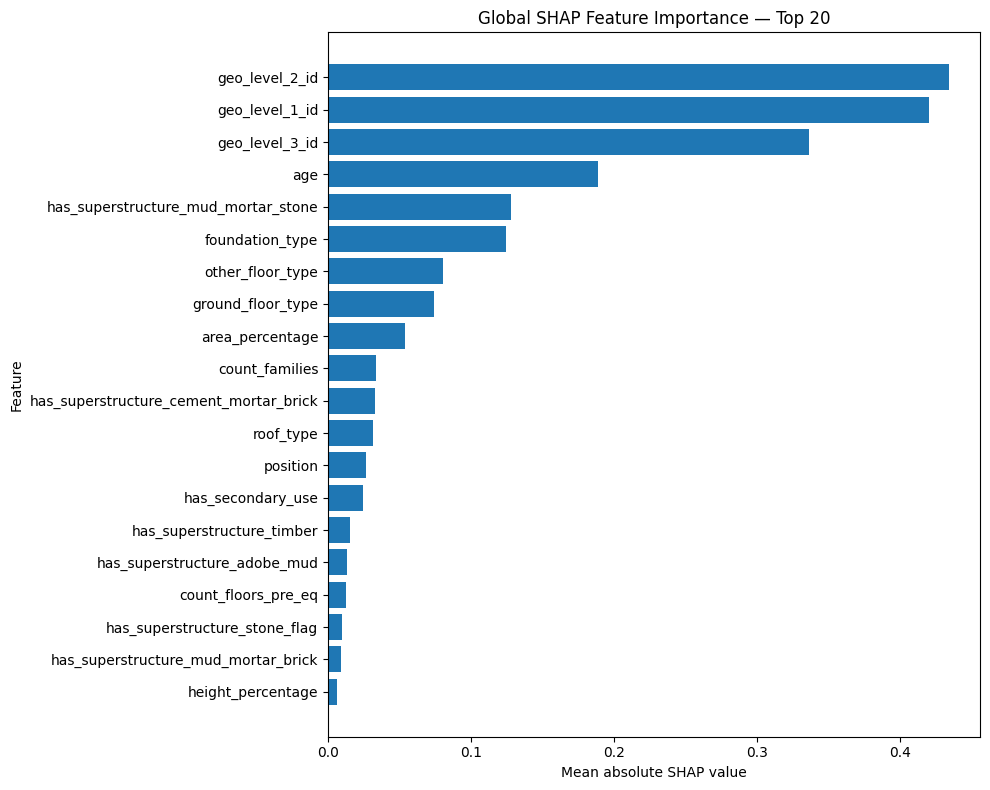

```python
# ---------------------------------------------------------
# Plot top 20 global SHAP features
# ---------------------------------------------------------

top_n = 20

plot_df = global_shap_importance_df.head(top_n).sort_values(
    "mean_abs_shap",
    ascending=True
)

plt.figure(figsize=(10, 8))

plt.barh(
    plot_df["feature"],
    plot_df["mean_abs_shap"]
)

plt.xlabel("Mean absolute SHAP value")
plt.ylabel("Feature")
plt.title("Global SHAP Feature Importance — Top 20")

plt.tight_layout()
plt.show()
```

### SHAP analysis for damage grade 3

We now isolate the SHAP values for damage grade 3, representing near-total building destruction.

Positive SHAP values indicate that a feature pushes the model toward the grade-3 output, while negative SHAP values push the model away from grade 3.

Mean absolute SHAP values measure the strength of the contribution, while the signed values allow us to investigate its direction.

```python
# ---------------------------------------------------------
# Grade 3 SHAP values
# ---------------------------------------------------------

GRADE_3_INDEX = 2

shap_values_grade3 = shap_values[:, :, GRADE_3_INDEX]

print("Grade 3 SHAP shape:", shap_values_grade3.shape)
```

```
Grade 3 SHAP shape: (5000, 38)
```

```python
# ---------------------------------------------------------
# Grade 3-specific SHAP importance
# ---------------------------------------------------------

grade3_shap_importance = np.mean(
    np.abs(shap_values_grade3),
    axis=0
)

grade3_shap_importance_df = (
    pd.DataFrame({
        "feature": X_shap_sample.columns,
        "mean_abs_shap": grade3_shap_importance
    })
    .sort_values("mean_abs_shap", ascending=False)
    .reset_index(drop=True)
)

grade3_shap_importance_df["rank"] = (
    np.arange(1, len(grade3_shap_importance_df) + 1)
)

grade3_shap_importance_df = grade3_shap_importance_df[
    ["rank", "feature", "mean_abs_shap"]
]

display(grade3_shap_importance_df)
```

|  | rank | feature | mean_abs_shap |
| --- | --- | --- | --- |
| 0 | 1 | geo_level_1_id | 0.449070 |
| 1 | 2 | geo_level_2_id | 0.429545 |
| 2 | 3 | geo_level_3_id | 0.303199 |
| 3 | 4 | ground_floor_type | 0.172225 |
| 4 | 5 | age | 0.136574 |
| 5 | 6 | foundation_type | 0.114652 |
| 6 | 7 | has_superstructure_cement_mortar_brick | 0.094069 |
| 7 | 8 | area_percentage | 0.089870 |
| 8 | 9 | has_superstructure_mud_mortar_stone | 0.087983 |
| 9 | 10 | has_secondary_use | 0.067975 |
| 10 | 11 | roof_type | 0.055519 |
| 11 | 12 | position | 0.030601 |
| 12 | 13 | has_superstructure_timber | 0.028274 |
| 13 | 14 | plan_configuration | 0.016585 |
| 14 | 15 | other_floor_type | 0.012190 |
| 15 | 16 | has_superstructure_cement_mortar_stone | 0.011528 |
| 16 | 17 | height_percentage | 0.005887 |
| 17 | 18 | count_floors_pre_eq | 0.003004 |
| 18 | 19 | has_superstructure_mud_mortar_brick | 0.002010 |
| 19 | 20 | count_families | 0.000833 |
| 20 | 21 | has_superstructure_other | 0.000466 |
| 21 | 22 | has_superstructure_bamboo | 0.000463 |
| 22 | 23 | has_superstructure_adobe_mud | 0.000429 |
| 23 | 24 | legal_ownership_status | 0.000414 |
| 24 | 25 | has_superstructure_rc_non_engineered | 0.000312 |
| 25 | 26 | has_superstructure_rc_engineered | 0.000207 |
| 26 | 27 | has_superstructure_stone_flag | 0.000113 |
| 27 | 28 | land_surface_condition | 0.000108 |
| 28 | 29 | has_secondary_use_agriculture | 0.000044 |
| 29 | 30 | has_secondary_use_hotel | 0.000000 |
| 30 | 31 | has_secondary_use_rental | 0.000000 |
| 31 | 32 | has_secondary_use_institution | 0.000000 |
| 32 | 33 | has_secondary_use_school | 0.000000 |
| 33 | 34 | has_secondary_use_industry | 0.000000 |
| 34 | 35 | has_secondary_use_health_post | 0.000000 |
| 35 | 36 | has_secondary_use_gov_office | 0.000000 |
| 36 | 37 | has_secondary_use_use_police | 0.000000 |
| 37 | 38 | has_secondary_use_other | 0.000000 |

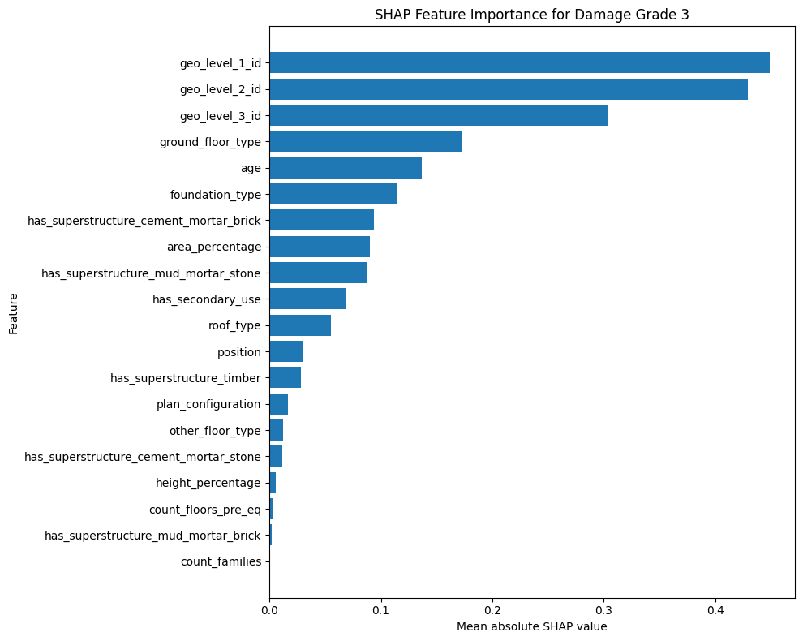

```python
# ---------------------------------------------------------
# Grade 3 SHAP feature importance
# ---------------------------------------------------------

top_n = 20

plot_df = grade3_shap_importance_df.head(top_n).sort_values(
    "mean_abs_shap",
    ascending=True
)

plt.figure(figsize=(10, 8))

plt.barh(
    plot_df["feature"],
    plot_df["mean_abs_shap"]
)

plt.xlabel("Mean absolute SHAP value")
plt.ylabel("Feature")
plt.title("SHAP Feature Importance for Damage Grade 3")

plt.tight_layout()
plt.show()
```

### Direction of feature effects on damage grade 3

Mean absolute SHAP values tell us which features matter most, but not the direction of their effect.

Here we examine signed SHAP values for the grade-3 output.

Positive SHAP values indicate that a feature pushes a prediction toward near-total destruction (grade 3), while negative values push it away from grade 3.

For categorical variables, the relationship must be interpreted by category rather than treating the category codes as ordered numerical values.

```python
# ---------------------------------------------------------
# Signed SHAP analysis for important numerical features
# ---------------------------------------------------------

NUMERIC_FEATURES_FOR_SHAP = [
    col for col in NUMERIC_COLS
    if col in X_shap_sample.columns
]

for feature in NUMERIC_FEATURES_FOR_SHAP:
    feature_idx = X_shap_sample.columns.get_loc(feature)

    temp = pd.DataFrame({
        "feature_value": X_shap_sample[feature].to_numpy(),
        "shap_value": shap_values_grade3[:, feature_idx]
    })

    print(f"\n{'=' * 70}")
    print(f"{feature}")
    print(f"{'=' * 70}")

    print(
        temp.groupby("feature_value")["shap_value"]
        .agg(["mean", "median", "count"])
        .sort_index()
        .to_string()
    )
```

```
======================================================================
count_floors_pre_eq
======================================================================
                   mean    median  count
feature_value
1              0.006614  0.007393    775
2             -0.001035 -0.001177   3015
3             -0.002174 -0.002575   1056
4              0.010145  0.007688    101
5              0.013777  0.007500     47
6              0.007670  0.009288      3
7              0.013890  0.009288      3

======================================================================
age
```

[output cut: 112 more lines]

```python
# ---------------------------------------------------------
# Grade 3 SHAP contribution by age
# ---------------------------------------------------------

age_shap_df = pd.DataFrame({
    "age": X_shap_sample["age"].to_numpy(),
    "grade3_shap": shap_values_grade3[
        :,
        X_shap_sample.columns.get_loc("age")
    ]
})

age_summary = (
    age_shap_df
    .groupby("age")["grade3_shap"]
    .agg(
        mean_shap="mean",
        median_shap="median",
        mean_abs_shap=lambda x: np.mean(np.abs(x)),
        count="count"
    )
    .sort_index()
)

display(age_summary)
```

| age | mean_shap | median_shap | mean_abs_shap | count |
| --- | --- | --- | --- | --- |
| 0 | -0.283552 | -0.287573 | 0.284710 | 466 |
| 5 | -0.225032 | -0.219102 | 0.225170 | 634 |
| 10 | -0.079911 | -0.076101 | 0.080784 | 772 |
| 15 | -0.012495 | -0.011975 | 0.022016 | 695 |
| 20 | 0.038118 | 0.038916 | 0.040032 | 625 |
| 25 | 0.111297 | 0.108202 | 0.112474 | 457 |
| 30 | 0.132601 | 0.131044 | 0.134027 | 338 |
| 35 | 0.150224 | 0.146871 | 0.151089 | 227 |
| 40 | 0.177326 | 0.172243 | 0.177594 | 186 |
| 45 | 0.179593 | 0.169809 | 0.179593 | 104 |
| 50 | 0.233318 | 0.230216 | 0.233729 | 163 |
| 55 | 0.229916 | 0.220875 | 0.229916 | 38 |
| 60 | 0.245127 | 0.242174 | 0.245166 | 74 |
| 65 | 0.238161 | 0.247334 | 0.240011 | 31 |
| 70 | 0.228974 | 0.223373 | 0.229433 | 34 |
| 75 | 0.235865 | 0.231727 | 0.235865 | 11 |
| 80 | 0.289629 | 0.284784 | 0.289629 | 38 |
| 85 | 0.264060 | 0.240660 | 0.264060 | 23 |
| 90 | 0.277505 | 0.282642 | 0.277505 | 22 |
| 95 | 0.296671 | 0.305528 | 0.296671 | 6 |
| 100 | 0.256928 | 0.279983 | 0.256928 | 23 |
| 105 | 0.323629 | 0.311741 | 0.323629 | 3 |
| 120 | 0.279152 | 0.316058 | 0.279152 | 5 |
| 125 | 0.348668 | 0.348668 | 0.348668 | 1 |
| 130 | 0.224302 | 0.224302 | 0.224302 | 1 |
| 150 | 0.197230 | 0.182859 | 0.197230 | 5 |
| 200 | 0.437420 | 0.437420 | 0.437420 | 1 |
| 995 | 0.234690 | 0.240028 | 0.234690 | 17 |

### Categorical feature effects on grade 3

For categorical features, we calculate the mean signed Grade-3 SHAP value within each category.

This allows us to identify which observed categories tend to push the model toward grade 3 and which tend to push it away.

These are model associations rather than causal effects.

```python
# ---------------------------------------------------------
# Categorical feature -> Grade 3 SHAP direction
# ---------------------------------------------------------

categorical_features_for_shap = [
    col for col in CATEGORICAL_COLS
    if col in X_shap_sample.columns
]

categorical_shap_results = {}

for feature in categorical_features_for_shap:

    feature_idx = X_shap_sample.columns.get_loc(feature)

    temp = pd.DataFrame({
        "category": X_shap_sample[feature].astype(str).to_numpy(),
        "grade3_shap": shap_values_grade3[:, feature_idx]
    })

    summary = (
        temp
        .groupby("category")["grade3_shap"]
        .agg(
            mean_shap="mean",
            median_shap="median",
            mean_abs_shap=lambda x: np.mean(np.abs(x)),
            count="count"
        )
        .sort_values("mean_shap", ascending=False)
    )

    categorical_shap_results[feature] = summary

    print(f"\n{'=' * 80}")
    print(f"{feature}")
    print(f"{'=' * 80}")

    display(summary)
```

```
================================================================================
land_surface_condition
================================================================================
```

| category | mean_shap | median_shap | mean_abs_shap | count |
| --- | --- | --- | --- | --- |
| o | 0.000297 | 0.000208 | 0.000297 | 156 |
| n | 0.000172 | 0.000096 | 0.000288 | 684 |
| t | -0.000051 | -0.000036 | 0.000071 | 4160 |

```
================================================================================
foundation_type
================================================================================
```

| category | mean_shap | median_shap | mean_abs_shap | count |
| --- | --- | --- | --- | --- |
| r | 0.071809 | 0.070769 | 0.071809 | 4213 |
| h | -0.119946 | -0.133404 | 0.132926 | 30 |
| u | -0.149703 | -0.143569 | 0.149703 | 276 |
| w | -0.240573 | -0.235673 | 0.240573 | 291 |
| i | -0.817980 | -0.824350 | 0.817980 | 190 |

```
================================================================================
roof_type
================================================================================
```

| category | mean_shap | median_shap | mean_abs_shap | count |
| --- | --- | --- | --- | --- |
| n | 0.033989 | 0.033011 | 0.033989 | 3493 |
| q | 0.024542 | 0.023961 | 0.024583 | 1210 |
| x | -0.434769 | -0.422112 | 0.434769 | 297 |

```
================================================================================
ground_floor_type
================================================================================
```

| category | mean_shap | median_shap | mean_abs_shap | count |
| --- | --- | --- | --- | --- |
| f | 0.106793 | 0.105069 | 0.106793 | 4031 |
| x | -0.056753 | -0.056222 | 0.067986 | 460 |
| z | -0.195727 | -0.188891 | 0.195727 | 20 |
| m | -0.240212 | -0.273846 | 0.240212 | 13 |
| v | -0.824231 | -0.808121 | 0.824231 | 476 |

```
================================================================================
other_floor_type
================================================================================
```

| category | mean_shap | median_shap | mean_abs_shap | count |
| --- | --- | --- | --- | --- |
| j | 0.040721 | 0.039401 | 0.040906 | 765 |
| x | -0.005024 | -0.005330 | 0.005148 | 853 |
| q | -0.005913 | -0.006146 | 0.006020 | 3178 |
| s | -0.030063 | -0.025720 | 0.030063 | 204 |

```
================================================================================
position
================================================================================
```

| category | mean_shap | median_shap | mean_abs_shap | count |
| --- | --- | --- | --- | --- |
| s | 0.019600 | 0.019524 | 0.019715 | 3864 |
| t | -0.048448 | -0.048245 | 0.049906 | 841 |
| o | -0.070009 | -0.073305 | 0.072020 | 42 |
| j | -0.124445 | -0.125492 | 0.125818 | 253 |

```
================================================================================
plan_configuration
================================================================================
```

| category | mean_shap | median_shap | mean_abs_shap | count |
| --- | --- | --- | --- | --- |
| q | 0.016394 | 0.016198 | 0.016394 | 103 |
| d | 0.007664 | 0.007835 | 0.007664 | 4790 |
| s | -0.099421 | -0.093474 | 0.099421 | 5 |
| a | -0.267137 | -0.271887 | 0.267137 | 11 |
| o | -0.284148 | -0.284148 | 0.284148 | 2 |
| f | -0.383013 | -0.383013 | 0.383013 | 1 |
| c | -0.418201 | -0.412537 | 0.418201 | 5 |
| m | -0.454060 | -0.454060 | 0.454060 | 1 |
| u | -0.458478 | -0.464500 | 0.458478 | 82 |

```
================================================================================
legal_ownership_status
================================================================================
```

| category | mean_shap | median_shap | mean_abs_shap | count |
| --- | --- | --- | --- | --- |
| a | 0.007786 | 0.006092 | 0.007786 | 95 |
| r | 0.003986 | 0.002712 | 0.003986 | 21 |
| w | 0.003408 | 0.002469 | 0.003408 | 52 |
| v | -0.000222 | -0.000179 | 0.000222 | 4832 |

### Grade 3 SHAP summary plot

The SHAP beeswarm plot combines feature importance and direction.

Features are ordered by mean absolute SHAP value. Each point represents one building in the SHAP sample.

The horizontal position represents the signed SHAP contribution:

- positive values push the model toward damage grade 3
- negative values push the model away from damage grade 3

For numerical features, point position also shows how the feature value relates to the model contribution.

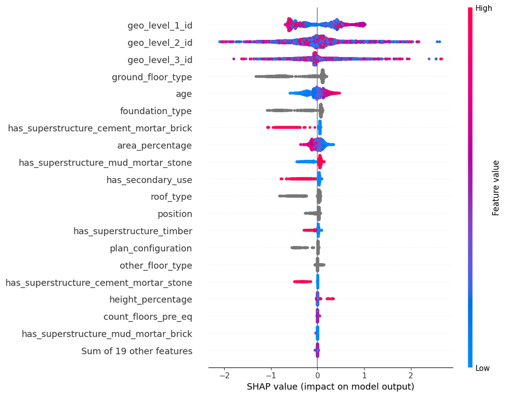

```python
# ---------------------------------------------------------
# Grade 3 SHAP beeswarm plot
# ---------------------------------------------------------

shap_grade3_explanation = shap.Explanation(
    values=shap_values_grade3,
    base_values=explainer.expected_value[GRADE_3_INDEX],
    data=X_shap_sample,
    feature_names=X_shap_sample.columns
)

shap.plots.beeswarm(
    shap_grade3_explanation,
    max_display=20,
    show=True
)
```

## Step 53 — Train the final LightGBM model

The final model uses the original 38 features.

Feature-engineering experiments involving:

- geographic target encoding,
- geographic hierarchy combinations,
- structural interaction features,
- and age bands

did not improve validation performance, so they are excluded.

The final model is trained using all available labelled training observations before generating predictions for the test dataset.

```python
# ---------------------------------------------------------
# Final LightGBM model
# ---------------------------------------------------------

X_final = X.copy()
X_test_final = X_test.copy()

# Convert categorical features to pandas category
for col in CATEGORICAL_COLS:
    X_final[col] = X_final[col].astype("category")
    X_test_final[col] = X_test_final[col].astype("category")

    # Ensure train/test use identical category definitions
    X_test_final[col] = X_test_final[col].cat.set_categories(
        X_final[col].cat.categories
    )

FINAL_LGB_CATEGORICAL_COLS = [
    col for col in GEO_COLS + CATEGORICAL_COLS
    if col in X_final.columns
]

final_lgbm = lgb.LGBMClassifier(
    objective="multiclass",
    num_class=3,

    n_estimators=870,
    learning_rate=0.03,

    num_leaves=15,
    min_child_samples=200,

    colsample_bytree=0.8,

    subsample=0.8,
    subsample_freq=1,

    max_depth=-1,

    random_state=RANDOM_STATE,
    n_jobs=-1,

    force_col_wise=True,
    verbosity=-1
)

final_lgbm.fit(
    X_final,
    y,

    categorical_feature=FINAL_LGB_CATEGORICAL_COLS
)

print("Final model trained.")
print("Number of features:", X_final.shape[1])
print("Number of training rows:", X_final.shape[0])
```

```
Final model trained.
Number of features: 38
Number of training rows: 260601
```

## Step 54 — Generate test-set predictions

The final LightGBM model is used to predict the damage grade for every building in the test dataset.

The predictions are converted back to the original damage-grade labels: 1 = low damage 2 = medium damage 3 = near-total destruction.

```python
# ---------------------------------------------------------
# Test predictions
# ---------------------------------------------------------

test_predictions = final_lgbm.predict(X_test_final)

test_predictions = np.asarray(test_predictions).astype(int)

print("Prediction shape:", test_predictions.shape)
print("Unique predictions:", np.unique(test_predictions))
```

```
Prediction shape: (86868,)
Unique predictions: [1 2 3]
```

## Step 55 — Check test prediction distribution

We compare the distribution of predicted damage grades in the test set with the training target distribution.

This is a sanity check for obvious prediction anomalies such as a model predicting almost entirely one class.

```python
# ---------------------------------------------------------
# Test prediction distribution
# ---------------------------------------------------------

test_prediction_distribution = (
    pd.Series(test_predictions)
    .value_counts(normalize=True)
    .sort_index()
    .mul(100)
    .rename("predicted_percentage")
    .to_frame()
)

test_prediction_distribution["predicted_count"] = (
    pd.Series(test_predictions)
    .value_counts()
    .sort_index()
)

display(test_prediction_distribution)
```

|  | predicted_percentage | predicted_count |
| --- | --- | --- |
| 1 | 7.962656 | 6917 |
| 2 | 63.658655 | 55299 |
| 3 | 28.378690 | 24652 |

```python
# ---------------------------------------------------------
# Compare training and test distributions
# ---------------------------------------------------------

train_distribution = (
    y.value_counts(normalize=True)
    .sort_index()
    .mul(100)
    .rename("train_percentage")
)

test_distribution = (
    pd.Series(test_predictions)
    .value_counts(normalize=True)
    .sort_index()
    .mul(100)
    .rename("test_prediction_percentage")
)

distribution_comparison = pd.concat(
    [train_distribution, test_distribution],
    axis=1
)

display(distribution_comparison)
```

|  | train_percentage | test_prediction_percentage |
| --- | --- | --- |
| 1 | 9.640792 | 7.962656 |
| 2 | 56.891186 | 63.658655 |
| 3 | 33.468022 | 28.378690 |

## Step 56 — Create the final submission

The submission contains the original building identifier and the predicted damage grade.

Before saving, we verify:

- the number of rows matches the test dataset,
- `building_id` is preserved from the original test data,
- `damage_grade` contains only valid classes {1, 2, 3},
- and there are no missing predictions.

```python
# ---------------------------------------------------------
# Create submission
# ---------------------------------------------------------

submission = pd.DataFrame({
    ID_COL: test_values[ID_COL].to_numpy(),
    TARGET_COL: test_predictions
})

print("Submission shape:", submission.shape)
print("\nColumns:")
print(submission.columns.tolist())

print("\nMissing values:")
print(submission.isna().sum())

print("\nUnique damage grades:")
print(sorted(submission[TARGET_COL].unique()))

print("\nFirst 5 rows:")
display(submission.head())

# ---------------------------------------------------------
# Save submission
# ---------------------------------------------------------

submission_path = "submission_lightgbm.csv"

submission.to_csv(
    submission_path,
    index=False
)

print(f"Submission saved to: {submission_path}")
```

```
Submission shape: (86868, 2)

Columns:
['building_id', 'damage_grade']

Missing values:
building_id     0
damage_grade    0
dtype: int64

Unique damage grades:
[np.int64(1), np.int64(2), np.int64(3)]

First 5 rows:
```

|  | building_id | damage_grade |
| --- | --- | --- |
| 0 | 300051 | 3 |
| 1 | 99355 | 2 |
| 2 | 890251 | 2 |
| 3 | 745817 | 1 |
| 4 | 421793 | 3 |

```
Submission saved to: submission_lightgbm.csv
```

## Feature Engineering

```python
def engineer_features(df):
    df = df.copy()

    # age is retained raw (Data Retention Decision) -- flag the 995 sentinel explicitly
    # so the model can separate it from genuinely old buildings.
    df["age_is_placeholder"] = (df["age"] == 995).astype(int)

    # Coarse life-stage buckets -- captures non-linear age thresholds a single continuous
    # term can't, and gives age==995 its own category ("unknown") instead of forcing it
    # into "very_old" alongside genuinely long-lived buildings. The max age in this dataset
    # is exactly 995 (EDA Section 6), so the (994, inf) bin only ever catches the sentinel.
    df["age_bucket"] = pd.cut(
        df["age"], bins=[-1, 5, 15, 30, 994, 10_000],
        labels=["new", "moderate", "old", "very_old", "unknown"],
    ).astype(str)

    # Older AND taller compounds risk; both are individually weak predictors (Section 9).
    df["age_x_floors"] = df["age"] * df["count_floors_pre_eq"]

    # Slenderness proxy -- height_percentage correlates +0.05 with damage, area_percentage
    # correlates -0.13 (Section 9); a tall/narrow footprint should combine both signals.
    df["height_area_ratio"] = df["height_percentage"] / df["area_percentage"].clip(lower=1)

    # Occupants per floor.
    df["family_density"] = df["count_families"] / df["count_floors_pre_eq"].clip(lower=1)

    # Count of distinct superstructure materials reported (Section 8: 68% of buildings
    # report exactly one -- mixed-material construction may behave differently).
    df["superstructure_material_count"] = df[SUPERSTRUCTURE_COLS].sum(axis=1)

    # Count of secondary uses (sub-flags only -- excludes the has_secondary_use umbrella,
    # which is a pure OR of these and would just duplicate the same information).
    df["secondary_use_count"] = df[SECONDARY_USE_SUB_COLS].sum(axis=1)

    # foundation_type was the strongest single categorical predictor in the EDA (Section 9);
    # position split the target more modestly. Their interaction may capture combined
    # structural-vulnerability patterns neither column shows alone.
    df["foundation_position"] = df["foundation_type"] + "_" + df["position"]

    return df


# geo_level_2_id frequency map -- fit on train only. This is a row count, not target-based,
# so (unlike KFoldTargetEncoder) no out-of-fold split is needed to avoid leakage.
geo2_freq_map = train_values_clean["geo_level_2_id"].value_counts()

train_values_fe = engineer_features(train_values_clean)
test_values_fe = engineer_features(test_values_clean)

train_values_fe["geo2_freq"] = train_values_fe["geo_level_2_id"].map(geo2_freq_map).fillna(0).astype(int)
test_values_fe["geo2_freq"] = test_values_fe["geo_level_2_id"].map(geo2_freq_map).fillna(0).astype(int)

new_cols = [c for c in train_values_fe.columns if c not in train_values_clean.columns]
print("New engineered columns:", new_cols)
train_values_fe[new_cols].head()
```

```
New engineered columns: ['age_is_placeholder', 'age_bucket', 'age_x_floors', 'height_area_ratio', 'family_density', 'superstructure_material_count', 'secondary_use_count', 'foundation_position', 'geo2_freq']
```

|  | age_is_placeholder | age_bucket | age_x_floors | height_area_ratio | family_density | superstructure_material_count | secondary_use_count | foundation_position | geo2_freq |
| --- | --- | --- | --- | --- | --- | --- | --- | --- | --- |
| 0 | 0 | old | 60 | 0.833333 | 0.500000 | 2 | 0 | r_t | 270 |
| 1 | 0 | moderate | 20 | 0.875000 | 0.500000 | 1 | 0 | r_s | 199 |
| 2 | 0 | moderate | 20 | 1.000000 | 0.500000 | 1 | 0 | r_t | 1760 |
| 3 | 0 | moderate | 20 | 0.833333 | 0.500000 | 3 | 0 | r_s | 205 |
| 4 | 0 | old | 90 | 1.125000 | 0.333333 | 1 | 0 | r_s | 1038 |

#### Encoder Classes

Two custom `BaseEstimator`/`TransformerMixin` transformers, both designed to sit inside a `ColumnTransformer`:

- **`KFoldTargetEncoder`** -- out-of-fold smoothed target mean. `fit_transform(X, y)` (called when the pipeline is fit on train) returns leakage-safe out-of-fold encodings via `StratifiedKFold`; `transform(X)` (called on test) applies a mapping fit on the full training data, falling back to the global train mean for anything unseen.
- **`GeoFrequencyEncoder`** -- plain row-count frequency. Since it never touches the target, ordinary `fit`/`transform` is already leakage-safe -- no out-of-fold split needed.

```python
class KFoldTargetEncoder(BaseEstimator, TransformerMixin):
    """
    Out-of-fold smoothed target encoding for one or more categorical
    columns, fit inside a ColumnTransformer/Pipeline.
    """

    def __init__(self, n_splits=N_SPLITS_TARGET_ENCODING,
                 smoothing=TARGET_ENCODING_SMOOTHING, random_state=RANDOM_STATE):
        self.n_splits = n_splits
        self.smoothing = smoothing
        self.random_state = random_state

    @staticmethod
    def _smoothed_means(y, groups, global_mean, smoothing):
        tmp = pd.DataFrame({"_y": np.asarray(y, dtype=float), "_grp": np.asarray(groups)})
        agg = tmp.groupby("_grp")["_y"].agg(["mean", "count"])
        return (agg["count"] * agg["mean"] + smoothing * global_mean) / (agg["count"] + smoothing)

    def fit(self, X, y):
        X = pd.DataFrame(X)
        y = pd.Series(np.asarray(y, dtype=float), index=X.index)
        self.feature_names_in_ = list(X.columns)
        self.global_mean_ = float(y.mean())
        self.full_maps_ = {
            col: self._smoothed_means(y, X[col], self.global_mean_, self.smoothing)
            for col in self.feature_names_in_
        }
        return self

    def transform(self, X):
        check_is_fitted(self, "full_maps_")
        X = pd.DataFrame(X, columns=self.feature_names_in_)
        out = pd.DataFrame(index=X.index)
        for col in self.feature_names_in_:
            out[col] = X[col].map(self.full_maps_[col]).fillna(self.global_mean_)
        return out.astype(float)

    def fit_transform(self, X, y=None):
        # Overridden (rather than relying on TransformerMixin's default
        # fit(X, y).transform(X)) so TRAIN gets leakage-safe out-of-fold
        # encodings instead of each row seeing a mapping fit on itself.
        X = pd.DataFrame(X)
        y = pd.Series(np.asarray(y, dtype=float), index=X.index)
        self.feature_names_in_ = list(X.columns)
        self.global_mean_ = float(y.mean())

        oof = pd.DataFrame(index=X.index, columns=self.feature_names_in_, dtype=float)
        skf = StratifiedKFold(n_splits=self.n_splits, shuffle=True, random_state=self.random_state)
        for train_idx, val_idx in skf.split(X, y):
            X_tr, y_tr = X.iloc[train_idx], y.iloc[train_idx]
            X_val = X.iloc[val_idx]
            for col in self.feature_names_in_:
                fold_map = self._smoothed_means(y_tr, X_tr[col], self.global_mean_, self.smoothing)
                oof.loc[X_val.index, col] = X_val[col].map(fold_map).fillna(self.global_mean_)

        self.full_maps_ = {
            col: self._smoothed_means(y, X[col], self.global_mean_, self.smoothing)
            for col in self.feature_names_in_
        }
        return oof.astype(float)

    def get_feature_names_out(self, input_features=None):
        names = self.feature_names_in_ if input_features is None else input_features
        return np.array([c.replace("_id", "_te") for c in names])


class GeoFrequencyEncoder(BaseEstimator, TransformerMixin):
    """Frequency (row-count) encoding for one or more categorical columns."""

    def fit(self, X, y=None):
        X = pd.DataFrame(X)
        self.feature_names_in_ = list(X.columns)
        self.freq_maps_ = {col: X[col].value_counts() for col in self.feature_names_in_}
        return self

    def transform(self, X):
        check_is_fitted(self, "freq_maps_")
        X = pd.DataFrame(X, columns=self.feature_names_in_)
        out = pd.DataFrame(index=X.index)
        for col in self.feature_names_in_:
            out[col] = X[col].map(self.freq_maps_[col]).fillna(0)
        return out.astype(float)

    def get_feature_names_out(self, input_features=None):
        names = self.feature_names_in_ if input_features is None else input_features
        return np.array([c.replace("_id", "_freq") for c in names])
```

## Geo Encoding Strategy Comparison

The EDA (Section 5) argued for target encoding over one-hot for the geo columns, based on cardinality and unseen test-set categories. This checks that argument empirically instead of taking it on faith: three full preprocessing-pipeline variants -- differing only in how `geo_level_1/2/3_id` are encoded -- are each cross-validated with the same fast proxy classifier (`LogisticRegression`), and whichever wins (`GEO_ENCODING_STRATEGY`) is what the real pipeline below actually uses.

| Strategy | `geo_level_1_id` (31 levels) | `geo_level_2_id` (1,418) | `geo_level_3_id` (11,861) |
| --- | --- | --- | --- |
| `target` | out-of-fold smoothed target mean | out-of-fold smoothed target mean | out-of-fold smoothed target mean |
| `frequency` | row-count frequency | row-count frequency | row-count frequency |
| `onehot_geo1_freq_rest` | one-hot (31 dummies -- feasible at this cardinality) | row-count frequency | row-count frequency |

Full one-hot for `geo_level_2_id` / `geo_level_3_id` is deliberately excluded -- at 1,418 / 11,861 levels it would blow up the feature space and can't generalize to the unseen test-set categories the EDA flagged there.

```python
from sklearn.linear_model import LogisticRegression
from sklearn.model_selection import cross_val_score


def get_geo_transformers(strategy):
    """ColumnTransformer transformer-tuples handling the 3 geo columns for a given
    strategy -- lets Stage 1 below be built generically off GEO_ENCODING_STRATEGY."""
    if strategy == "target":
        return [("geo_te", KFoldTargetEncoder(), GEO_TARGET_ENCODE_COLS)]
    if strategy == "frequency":
        return [("geo_freq", GeoFrequencyEncoder(), GEO_TARGET_ENCODE_COLS)]
    if strategy == "onehot_geo1_freq_rest":
        return [
            ("geo1_ohe", OneHotEncoder(handle_unknown="ignore", sparse_output=False), ["geo_level_1_id"]),
            ("geo23_freq", GeoFrequencyEncoder(), ["geo_level_2_id", "geo_level_3_id"]),
        ]
    raise ValueError(f"Unknown geo encoding strategy: {strategy!r}")


def get_geo_scale_cols(strategy):
    """Names of the geo-derived columns that need MinMax scaling in Stage 2 (one-hot
    dummies are already 0/1 and are left alone)."""
    if strategy == "target":
        return [c.replace("_id", "_te") for c in GEO_TARGET_ENCODE_COLS]
    if strategy == "frequency":
        return [c.replace("_id", "_freq") for c in GEO_TARGET_ENCODE_COLS]
    if strategy == "onehot_geo1_freq_rest":
        return [c.replace("_id", "_freq") for c in ["geo_level_2_id", "geo_level_3_id"]]
    raise ValueError(f"Unknown geo encoding strategy: {strategy!r}")


def build_geo_comparison_pipeline(strategy):
    fe = ColumnTransformer(
        transformers=get_geo_transformers(strategy) + [
            ("cont", "passthrough", CONTINUOUS_NUMERIC_COLS),
            ("ohe", OneHotEncoder(handle_unknown="ignore", sparse_output=False), ONE_HOT_COLS),
            ("binary", "passthrough", BINARY_COLS),
        ],
        remainder="drop",
        verbose_feature_names_out=False,
    ).set_output(transform="pandas")

    scale_cols = CONTINUOUS_NUMERIC_COLS + get_geo_scale_cols(strategy)
    scale = ColumnTransformer(
        transformers=[("minmax", MinMaxScaler(), scale_cols)],
        remainder="passthrough",
        verbose_feature_names_out=False,
    ).set_output(transform="pandas")

    return Pipeline([
        ("feature_engineering", fe),
        ("scaling", scale),
        ("model", LogisticRegression(max_iter=1000, class_weight="balanced", random_state=RANDOM_STATE)),
    ])


geo_cv = StratifiedKFold(n_splits=5, shuffle=True, random_state=RANDOM_STATE)
geo_strategy_scores = {}
for strategy in ["target", "frequency", "onehot_geo1_freq_rest"]:
    pipe = build_geo_comparison_pipeline(strategy)
    scores = cross_val_score(
        pipe, train_values_fe, train_labels_clean[TARGET_COL],
        cv=geo_cv, scoring="f1_micro", n_jobs=-1,
    )
    geo_strategy_scores[strategy] = scores
    print(f"{strategy:25s}  f1_micro = {scores.mean():.4f} +/- {scores.std():.4f}")

GEO_ENCODING_STRATEGY = max(geo_strategy_scores, key=lambda s: geo_strategy_scores[s].mean())
print(f"\nSelected geo encoding strategy: {GEO_ENCODING_STRATEGY!r}")
```

```
target                     f1_micro = 0.6751 +/- 0.0009
frequency                  f1_micro = 0.5194 +/- 0.0013
onehot_geo1_freq_rest      f1_micro = 0.5932 +/- 0.0020

Selected geo encoding strategy: 'target'
```

#### Preprocessing Pipeline (ColumnTransformer)

One-hot encoding, geo encoding (whichever strategy won above), and scaling are expressed below as a single `sklearn.pipeline.Pipeline` of two `ColumnTransformer` stages. The pipeline is `fit_transform`'d once on train (using `y_train`) and `transform`'d on test, so both sets go through exactly the same fitted encoders/scaler -- and the whole thing is one object that can be dropped straight into cross-validation later.

#### Stage 1 -- Encode

One `ColumnTransformer` fit on `train_values_fe` (needs `y_train` only if `GEO_ENCODING_STRATEGY == "target"`, since that's the only geo option that touches the target):

- geo columns: whichever strategy won the comparison above (`get_geo_transformers`)
- `cont`: passthrough for the continuous numeric columns, including the engineered numeric features (scaled in Stage 2)
- `ohe`: `OneHotEncoder(handle_unknown="ignore")` on the 8 categorical columns plus the engineered `foundation_position` and `age_bucket` columns
- `binary`: passthrough for the superstructure / secondary-use flags plus the engineered `age_is_placeholder` flag

`verbose_feature_names_out=False` keeps the readable original/encoded column names instead of `transformername__colname` prefixes.

```python
feature_engineering = ColumnTransformer(
    transformers=get_geo_transformers(GEO_ENCODING_STRATEGY) + [
        ("cont", "passthrough", CONTINUOUS_NUMERIC_COLS),
        ("ohe", OneHotEncoder(handle_unknown="ignore", sparse_output=False), ONE_HOT_COLS),
        ("binary", "passthrough", BINARY_COLS),
    ],
    remainder="drop",
    verbose_feature_names_out=False,
).set_output(transform="pandas")

feature_engineering
```

```
ColumnTransformer(transformers=[('geo_te', KFoldTargetEncoder(),
                                 ['geo_level_1_id', 'geo_level_2_id',
                                  'geo_level_3_id']),
                                ('cont', 'passthrough',
                                 ['age', 'area_percentage', 'height_percentage',
                                  'count_floors_pre_eq', 'count_families',
                                  'age_x_floors', 'height_area_ratio',
                                  'family_density',
                                  'superstructure_material_count',
                                  'secondary_use_count', 'geo2_freq']),
                                ('ohe',...
                                  'has_secondary_use',
                                  'has_secondary_use_agriculture',
                                  'has_secondary_use_hotel',
                                  'has_secondary_use_rental',
                                  'has_secondary_use_institution',
                                  'has_secondary_use_school',
                                  'has_secondary_use_industry',
                                  'has_secondary_use_health_post',
                                  'has_secondary_use_gov_office',
                                  'has_secondary_use_use_police',
                                  'has_secondary_use_other',
                                  'age_is_placeholder'])],
                  verbose_feature_names_out=False)
```

#### Stage 2 -- Scale

A second `ColumnTransformer`, chained after Stage 1 by column name, applies `MinMaxScaler` to the continuous numeric + geo-encoded columns and passes every other column (one-hot + binary flags, already 0/1) straight through unscaled. The two stages are combined into a single `Pipeline` so `fit_transform`/`transform` run both stages in sequence.

```python
SCALE_COLS = CONTINUOUS_NUMERIC_COLS + get_geo_scale_cols(GEO_ENCODING_STRATEGY)

scaling = ColumnTransformer(
    transformers=[("minmax", MinMaxScaler(), SCALE_COLS)],
    remainder="passthrough",
    verbose_feature_names_out=False,
).set_output(transform="pandas")

preprocessing_pipeline = Pipeline([
    ("feature_engineering", feature_engineering),
    ("scaling", scaling),
])

preprocessing_pipeline
```

```
Pipeline(steps=[('feature_engineering',
                 ColumnTransformer(transformers=[('geo_te',
                                                  KFoldTargetEncoder(),
                                                  ['geo_level_1_id',
                                                   'geo_level_2_id',
                                                   'geo_level_3_id']),
                                                 ('cont', 'passthrough',
                                                  ['age', 'area_percentage',
                                                   'height_percentage',
                                                   'count_floors_pre_eq',
                                                   'count_families',
                                                   'age_x_floors',
                                                   'height_area_ratio',
                                                   'family_density',
                                                   'superstructure_material_count',
                                                   'sec...
                 ColumnTransformer(remainder='passthrough',
                                   transformers=[('minmax', MinMaxScaler(),
                                                  ['age', 'area_percentage',
                                                   'height_percentage',
                                                   'count_floors_pre_eq',
                                                   'count_families',
                                                   'age_x_floors',
                                                   'height_area_ratio',
                                                   'family_density',
                                                   'superstructure_material_count',
                                                   'secondary_use_count',
                                                   'geo2_freq',
                                                   'geo_level_1_te',
                                                   'geo_level_2_te',
                                                   'geo_level_3_te'])],
                                   verbose_feature_names_out=False))])
```

#### Fit on Train, Transform Test

Fit on `train_values_fe` + `y_train` only. Test (`test_values_fe`) only ever sees `.transform` -- the target-encoding fallback (global train mean) and `OneHotEncoder(handle_unknown="ignore")` cover any category unseen during fit.

```python
y_train = train_labels_clean[TARGET_COL]

train_engineered = preprocessing_pipeline.fit_transform(train_values_fe, y_train)
test_engineered = preprocessing_pipeline.transform(test_values_fe)

print(f"[preprocessing_pipeline] train_engineered shape: {train_engineered.shape}")
print(f"[preprocessing_pipeline] test_engineered shape : {test_engineered.shape}")
train_engineered.head()
```

```
[preprocessing_pipeline] train_engineered shape: (260601, 100)
[preprocessing_pipeline] test_engineered shape : (86868, 100)
```

|  | age | area_percentage | height_percentage | count_floors_pre_eq | count_families | age_x_floors | height_area_ratio | family_density | superstructure_material_count | secondary_use_count | geo2_freq | geo_level_1_te | geo_level_2_te | geo_level_3_te | land_surface_condition_n | land_surface_condition_o | land_surface_condition_t | foundation_type_h | foundation_type_i | foundation_type_r | foundation_type_u | foundation_type_w | roof_type_n | roof_type_q | roof_type_x | ground_floor_type_f | ground_floor_type_m | ground_floor_type_v | ground_floor_type_x | … |
| --- | --- | --- | --- | --- | --- | --- | --- | --- | --- | --- | --- | --- | --- | --- | --- | --- | --- | --- | --- | --- | --- | --- | --- | --- | --- | --- | --- | --- | --- | --- |
| 0 | 0.030151 | 0.050505 | 0.100000 | 0.125 | 0.111111 | 0.010050 | 0.050137 | 0.055556 | 0.142857 | 0.0 | 0.066634 | 0.403759 | 0.858965 | 0.856344 | 0.0 | 0.0 | 1.0 | 0.0 | 0.0 | 1.0 | 0.0 | 0.0 | 1.0 | 0.0 | 0.0 | 1.0 | 0.0 | 0.0 | 0.0 | … |
| 1 | 0.010050 | 0.070707 | 0.166667 | 0.125 | 0.111111 | 0.003350 | 0.052746 | 0.055556 | 0.000000 | 0.0 | 0.049046 | 0.709197 | 0.710913 | 0.553678 | 0.0 | 1.0 | 0.0 | 0.0 | 0.0 | 1.0 | 0.0 | 0.0 | 1.0 | 0.0 | 0.0 | 0.0 | 0.0 | 0.0 | 1.0 | … |
| 2 | 0.010050 | 0.040404 | 0.100000 | 0.125 | 0.111111 | 0.003350 | 0.060575 | 0.055556 | 0.000000 | 0.0 | 0.435720 | 0.783041 | 0.744013 | 0.793943 | 0.0 | 0.0 | 1.0 | 0.0 | 0.0 | 1.0 | 0.0 | 0.0 | 1.0 | 0.0 | 0.0 | 1.0 | 0.0 | 0.0 | 0.0 | … |
| 3 | 0.010050 | 0.050505 | 0.100000 | 0.125 | 0.111111 | 0.003350 | 0.050137 | 0.055556 | 0.285714 | 0.0 | 0.050533 | 0.256529 | 0.494048 | 0.562044 | 0.0 | 0.0 | 1.0 | 0.0 | 0.0 | 1.0 | 0.0 | 0.0 | 1.0 | 0.0 | 0.0 | 1.0 | 0.0 | 0.0 | 0.0 | … |
| 4 | 0.030151 | 0.070707 | 0.233333 | 0.250 | 0.111111 | 0.015075 | 0.068403 | 0.037037 | 0.000000 | 0.0 | 0.256874 | 0.568032 | 0.628969 | 0.650294 | 0.0 | 0.0 | 1.0 | 0.0 | 0.0 | 1.0 | 0.0 | 0.0 | 1.0 | 0.0 | 0.0 | 1.0 | 0.0 | 0.0 | 0.0 | … |

#### Assemble Final Feature Tables

```python
train_final = pd.concat(
    [
        train_values_fe[[ID_COL]].reset_index(drop=True),
        train_engineered.reset_index(drop=True),
    ],
    axis=1,
)
train_final[TARGET_COL] = train_labels_clean[TARGET_COL].reset_index(drop=True)

test_final = pd.concat(
    [
        test_values_fe[[ID_COL]].reset_index(drop=True),
        test_engineered.reset_index(drop=True),
    ],
    axis=1,
)

print("train_final shape:", train_final.shape)
print("test_final shape :", test_final.shape)
train_final.head()
```

```
train_final shape: (260601, 102)
test_final shape : (86868, 101)
```

|  | building_id | age | area_percentage | height_percentage | count_floors_pre_eq | count_families | age_x_floors | height_area_ratio | family_density | superstructure_material_count | secondary_use_count | geo2_freq | geo_level_1_te | geo_level_2_te | geo_level_3_te | land_surface_condition_n | land_surface_condition_o | land_surface_condition_t | foundation_type_h | foundation_type_i | foundation_type_r | foundation_type_u | foundation_type_w | roof_type_n | roof_type_q | roof_type_x | ground_floor_type_f | ground_floor_type_m | ground_floor_type_v | … |
| --- | --- | --- | --- | --- | --- | --- | --- | --- | --- | --- | --- | --- | --- | --- | --- | --- | --- | --- | --- | --- | --- | --- | --- | --- | --- | --- | --- | --- | --- | --- |
| 0 | 802906 | 0.030151 | 0.050505 | 0.100000 | 0.125 | 0.111111 | 0.010050 | 0.050137 | 0.055556 | 0.142857 | 0.0 | 0.066634 | 0.403759 | 0.858965 | 0.856344 | 0.0 | 0.0 | 1.0 | 0.0 | 0.0 | 1.0 | 0.0 | 0.0 | 1.0 | 0.0 | 0.0 | 1.0 | 0.0 | 0.0 | … |
| 1 | 28830 | 0.010050 | 0.070707 | 0.166667 | 0.125 | 0.111111 | 0.003350 | 0.052746 | 0.055556 | 0.000000 | 0.0 | 0.049046 | 0.709197 | 0.710913 | 0.553678 | 0.0 | 1.0 | 0.0 | 0.0 | 0.0 | 1.0 | 0.0 | 0.0 | 1.0 | 0.0 | 0.0 | 0.0 | 0.0 | 0.0 | … |
| 2 | 94947 | 0.010050 | 0.040404 | 0.100000 | 0.125 | 0.111111 | 0.003350 | 0.060575 | 0.055556 | 0.000000 | 0.0 | 0.435720 | 0.783041 | 0.744013 | 0.793943 | 0.0 | 0.0 | 1.0 | 0.0 | 0.0 | 1.0 | 0.0 | 0.0 | 1.0 | 0.0 | 0.0 | 1.0 | 0.0 | 0.0 | … |
| 3 | 590882 | 0.010050 | 0.050505 | 0.100000 | 0.125 | 0.111111 | 0.003350 | 0.050137 | 0.055556 | 0.285714 | 0.0 | 0.050533 | 0.256529 | 0.494048 | 0.562044 | 0.0 | 0.0 | 1.0 | 0.0 | 0.0 | 1.0 | 0.0 | 0.0 | 1.0 | 0.0 | 0.0 | 1.0 | 0.0 | 0.0 | … |
| 4 | 201944 | 0.030151 | 0.070707 | 0.233333 | 0.250 | 0.111111 | 0.015075 | 0.068403 | 0.037037 | 0.000000 | 0.0 | 0.256874 | 0.568032 | 0.628969 | 0.650294 | 0.0 | 0.0 | 1.0 | 0.0 | 0.0 | 1.0 | 0.0 | 0.0 | 1.0 | 0.0 | 0.0 | 1.0 | 0.0 | 0.0 | … |

#### Sanity Checks

```python
print("Any NaNs in train_final:", train_final.isnull().sum().sum())
print("Any NaNs in test_final :", test_final.isnull().sum().sum())

train_cols = set(train_final.columns) - {TARGET_COL}
test_cols = set(test_final.columns)
print(f'Train shape: {train_final.shape}')
print(f'Test shape: {test_final.shape}')
print("Train/test column sets match (excl target):", train_cols == test_cols)

print("test_final row count matches required 86,868:", len(test_final) == 86868)
```

```
Any NaNs in train_final: 0
Any NaNs in test_final : 0
Train shape: (260601, 102)
Test shape: (86868, 101)
Train/test column sets match (excl target): True
test_final row count matches required 86,868: True
```

#### Save Processed Data

```python
os.makedirs(OUTPUT_DIR, exist_ok=True)

train_path = os.path.join(OUTPUT_DIR, "train_processed.csv")
test_path = os.path.join(OUTPUT_DIR, "test_processed.csv")

train_final.to_csv(train_path, index=False)
test_final.to_csv(test_path, index=False)

print("Saved:", train_path)
print("Saved:", test_path)
```

```
Saved: ..\outputs\train_processed.csv
Saved: ..\outputs\test_processed.csv
```

## Feature Selection

`train_final` now has more columns than the model strictly needs after one-hot encoding, geo encoding, and the engineered features above -- including at least one pair known to be redundant by construction (`age_bucket_unknown` and `age_is_placeholder` encode the same 995 sentinel). Two complementary checks trim it down:

1. **Redundancy check** -- flag any pair of numeric/encoded columns with `|Pearson r| > 0.85` (stricter than the 0.77 max correlation already logged in the EDA appendix), since near-duplicate columns add noise to linear/distance-based methods and dilute importance estimates without adding signal.
2. **Embedded importance** -- fit a quick `RandomForestClassifier` on the full feature set and keep only the columns at or above the median importance (`SelectFromModel(threshold="median")`), cross-checked against a mutual-information ranking so the selection isn't tied to one estimator's quirks.

The result, `SELECTED_FEATURES`, is the default feature set used for modeling below; `ALL_FEATURES` (the full engineered set) is kept alongside it so the choice can be compared directly.

#### Redundancy Check

```python
numeric_like_cols = [
    c for c in train_final.columns
    if c not in (ID_COL, TARGET_COL) and train_final[c].nunique() > 2
]

corr_matrix = train_final[numeric_like_cols].corr().abs()
upper = corr_matrix.where(np.triu(np.ones(corr_matrix.shape), k=1).astype(bool))

redundant_pairs = [
    (row, col, upper.loc[row, col])
    for col in upper.columns
    for row in upper.index
    if pd.notna(upper.loc[row, col]) and upper.loc[row, col] > 0.85
]

print(f"Pairs with |corr| > 0.85: {len(redundant_pairs)}")
for a, b, v in sorted(redundant_pairs, key=lambda t: -t[2]):
    print(f"  {a:35s} <-> {b:35s}  r = {v:.3f}")
```

```
Pairs with |corr| > 0.85: 2
  age                                 <-> age_x_floors                         r = 0.932
  geo_level_2_te                      <-> geo_level_3_te                       r = 0.887
```

#### Embedded Importance (Random Forest + SelectFromModel)

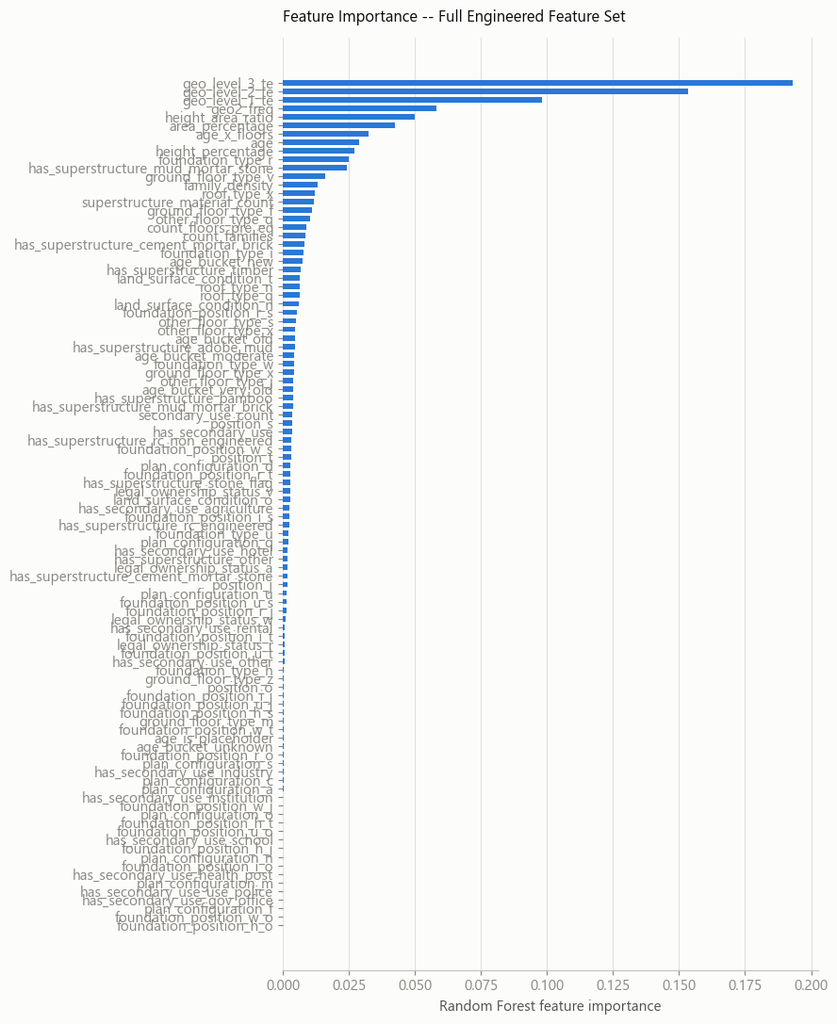

```
Kept 50 / 100 features (>= median importance):
['age', 'area_percentage', 'height_percentage', 'count_floors_pre_eq', 'count_families', 'age_x_floors', 'height_area_ratio', 'family_density', 'superstructure_material_count', 'secondary_use_count', 'geo2_freq', 'geo_level_1_te', 'geo_level_2_te', 'geo_level_3_te', 'land_surface_condition_n', 'land…
```

```python
from sklearn.ensemble import RandomForestClassifier
from sklearn.feature_selection import SelectFromModel

ALL_FEATURES = [c for c in train_final.columns if c not in (ID_COL, TARGET_COL)]
X_all = train_final[ALL_FEATURES]
y_all = train_final[TARGET_COL]

rf_selector = RandomForestClassifier(
    n_estimators=300, max_depth=None, class_weight="balanced_subsample",
    random_state=RANDOM_STATE, n_jobs=-1,
)
rf_selector.fit(X_all, y_all)

importances = pd.Series(rf_selector.feature_importances_, index=ALL_FEATURES).sort_values(ascending=False)

fig, ax = plt.subplots(figsize=(9, 11))
plot_imp = importances.sort_values(ascending=True)
ax.barh(plot_imp.index, plot_imp.values, color=CAT["blue"], height=0.65)
ax.set_xlabel("Random Forest feature importance")
ax.set_title("Feature Importance -- Full Engineered Feature Set", color=INK_PRIMARY, fontsize=12, loc="left", pad=12)
style_ax(ax, hide_spines=("top", "right", "left"))
ax.grid(axis="y", visible=False)
plt.tight_layout()
plt.savefig(OUT / "feature_selection_rf_importance.png", dpi=160)
plt.show()

selector = SelectFromModel(rf_selector, threshold="median", prefit=True)
SELECTED_FEATURES = list(X_all.columns[selector.get_support()])

print(f"\nKept {len(SELECTED_FEATURES)} / {len(ALL_FEATURES)} features (>= median importance):")
print(SELECTED_FEATURES)
```

#### Mutual Information Cross-Check

```python
discrete_mask = [X_all[c].nunique() <= 20 for c in ALL_FEATURES]
mi_scores = mutual_info_classif(X_all, y_all, discrete_features=discrete_mask, random_state=RANDOM_STATE)
mi_ranking = pd.Series(mi_scores, index=ALL_FEATURES).sort_values(ascending=False)

top_rf = set(importances.head(15).index)
top_mi = set(mi_ranking.head(15).index)
overlap = top_rf & top_mi

print(f"Top-15 overlap between RF importance and mutual information: {len(overlap)}/15")
print(sorted(overlap))
```

[output not shown]

```
Top-15 overlap between RF importance and mutual information: 12/15
['age', 'age_x_floors', 'family_density', 'foundation_type_r', 'geo2_freq', 'geo_level_1_te', 'geo_level_2_te', 'geo_level_3_te', 'ground_floor_type_v', 'has_superstructure_mud_mortar_stone', 'height_area_ratio', 'roof_type_x']
```

## Modeling

Following the roadmap (steps 20-25 above): a naive baseline, a cross-validated comparison of four candidate model families, hyperparameter tuning of the three tree ensembles, a held-out validation check, and a final refit used to produce the competition submission. All comparisons and tuning use **`f1_micro`**, the competition's actual metric (`performance_metric.md`), not accuracy.

```python
from sklearn.base import clone
from sklearn.model_selection import train_test_split, StratifiedKFold, cross_val_score, RandomizedSearchCV
from sklearn.dummy import DummyClassifier
from sklearn.linear_model import LogisticRegression
from sklearn.metrics import f1_score, classification_report, ConfusionMatrixDisplay
from scipy.stats import randint, uniform
from xgboost import XGBClassifier
from lightgbm import LGBMClassifier
```

#### Feature Set & Train/Validation Split

`FEATURE_SET` defaults to `SELECTED_FEATURES` from the Feature Selection section above -- set it to `ALL_FEATURES` to compare. A stratified 85/15 split carves out `X_val`/`y_val` as a final check (Step 24) that is never touched during cross-validation or tuning; the CV folds below (`cv`) are drawn only from `X_tr`/`y_tr`.

```python
FEATURE_SET = SELECTED_FEATURES  # swap to ALL_FEATURES to compare

X = train_final[FEATURE_SET]
y = train_final[TARGET_COL]
X_test_final = test_final[FEATURE_SET]

X_tr, X_val, y_tr, y_val = train_test_split(
    X, y, test_size=0.15, stratify=y, random_state=RANDOM_STATE
)
cv = StratifiedKFold(n_splits=5, shuffle=True, random_state=RANDOM_STATE)

print(f"X_tr : {X_tr.shape}   X_val: {X_val.shape}   X_test_final: {X_test_final.shape}")
```

```
X_tr : (221510, 50)   X_val: (39091, 50)   X_test_final: (86868, 50)
```

#### Step 20 -- Naive Baseline

```python
baseline = DummyClassifier(strategy="most_frequent", random_state=RANDOM_STATE)
baseline.fit(X_tr, y_tr)
baseline_f1 = f1_score(y_val, baseline.predict(X_val), average="micro")
print(f"Naive baseline (always predict the majority class) -- f1_micro: {baseline_f1:.4f}")
```

```
Naive baseline (always predict the majority class) -- f1_micro: 0.5689
```

#### Step 21 -- Candidate Model Comparison (Cross-Validation)

Four model families spanning the spectrum the EDA pointed toward: a linear baseline (`LogisticRegression`), then three tree ensembles (`RandomForestClassifier`, `XGBClassifier`, `LGBMClassifier`) that can capture the non-linear/interaction-driven signal noted in Section 9. XGBoost's sklearn wrapper requires 0-indexed class labels for `multi:softprob` (`damage_grade - 1`, shifted back by +1 on prediction); `LogisticRegression`, `RandomForestClassifier`, and `LGBMClassifier` all handle the raw 1/2/3 labels natively via their own internal label encoding.

```
logistic_regression   f1_micro = 0.6763 +/- 0.0017
random_forest         f1_micro = 0.7392 +/- 0.0019
xgboost               f1_micro = 0.7428 +/- 0.0031
lightgbm              f1_micro = 0.6870 +/- 0.0018
```

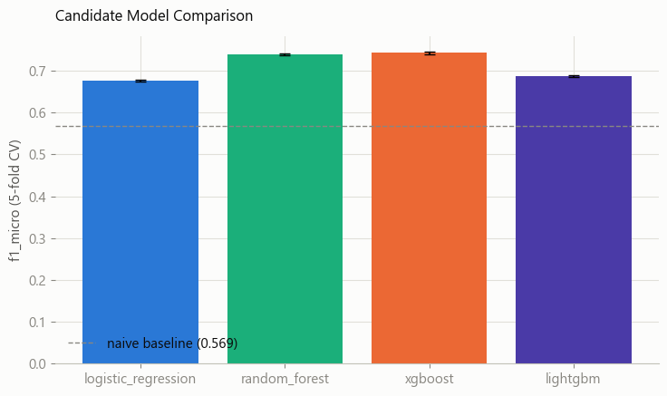

```python
candidates = {
    "logistic_regression": LogisticRegression(max_iter=2000, class_weight="balanced", random_state=RANDOM_STATE),
    "random_forest": RandomForestClassifier(
        n_estimators=300, class_weight="balanced_subsample", random_state=RANDOM_STATE, n_jobs=-1
    ),
    "xgboost": XGBClassifier(
        objective="multi:softprob", num_class=3, eval_metric="mlogloss",
        random_state=RANDOM_STATE, n_jobs=-1
    ),
    "lightgbm": LGBMClassifier(
        class_weight="balanced", random_state=RANDOM_STATE, n_jobs=-1, verbose=-1
    ),
}

cv_results = {}
for name, model in candidates.items():
    y_fit = (y_tr - 1) if name == "xgboost" else y_tr
    scores = cross_val_score(model, X_tr, y_fit, cv=cv, scoring="f1_micro", n_jobs=-1)
    cv_results[name] = scores
    print(f"{name:20s}  f1_micro = {scores.mean():.4f} +/- {scores.std():.4f}")

fig, ax = plt.subplots(figsize=(7.5, 4.5))
names = list(cv_results.keys())
means = [cv_results[n].mean() for n in names]
stds = [cv_results[n].std() for n in names]
bar_colors = [CAT["blue"], CAT["aqua"], CAT["orange"], CAT["violet"]]
ax.bar(names, means, yerr=stds, capsize=4, color=bar_colors)
ax.axhline(baseline_f1, color=INK_MUTED, linestyle="--", linewidth=1, label=f"naive baseline ({baseline_f1:.3f})")
ax.set_ylabel("f1_micro (5-fold CV)")
ax.set_title("Candidate Model Comparison", color=INK_PRIMARY, fontsize=12, loc="left", pad=12)
ax.legend(frameon=False)
style_ax(ax)
plt.tight_layout()
plt.savefig(OUT / "model_comparison_cv.png", dpi=160)
plt.show()
```

#### Step 22 -- Hyperparameter Tuning: Random Forest

`RandomizedSearchCV` (25 draws, 3-fold CV -- cheaper than the 5-fold comparison above given ~220K training rows) over the parameters that matter most for a `RandomForestClassifier`: ensemble size, tree depth/leaf constraints, and the fraction of features considered at each split. Reduce `n_iter` if this runs too slowly on your machine.

```python
rf_param_dist = {
    "n_estimators": randint(200, 600),
    "max_depth": [None] + list(range(8, 41, 4)),
    "min_samples_split": randint(2, 20),
    "min_samples_leaf": randint(1, 10),
    "max_features": ["sqrt", "log2", 0.3, 0.5],
}

rf_search = RandomizedSearchCV(
    RandomForestClassifier(class_weight="balanced_subsample", random_state=RANDOM_STATE, n_jobs=-1),
    param_distributions=rf_param_dist,
    n_iter=25,
    cv=StratifiedKFold(n_splits=3, shuffle=True, random_state=RANDOM_STATE),
    scoring="f1_micro",
    random_state=RANDOM_STATE,
    n_jobs=-1,
    verbose=1,
)
rf_search.fit(X_tr, y_tr)

print("Best RF params:", rf_search.best_params_)
print(f"Best RF CV f1_micro: {rf_search.best_score_:.4f}")
```

```
Fitting 3 folds for each of 25 candidates, totalling 75 fits
```

#### Step 22 -- Hyperparameter Tuning: XGBoost

Same `RandomizedSearchCV` setup, over XGBoost's core boosting parameters (tree count/depth, learning rate, subsampling, and the two regularization knobs -- `min_child_weight`, `gamma`). Labels are shifted to 0-indexed for XGBoost, as in the comparison above.

```python
xgb_param_dist = {
    "n_estimators": randint(200, 600),
    "max_depth": randint(3, 12),
    "learning_rate": uniform(0.01, 0.29),
    "subsample": uniform(0.6, 0.4),
    "colsample_bytree": uniform(0.6, 0.4),
    "min_child_weight": randint(1, 10),
    "gamma": uniform(0, 0.5),
}

xgb_search = RandomizedSearchCV(
    XGBClassifier(objective="multi:softprob", num_class=3, eval_metric="mlogloss",
                  random_state=RANDOM_STATE, n_jobs=-1),
    param_distributions=xgb_param_dist,
    n_iter=25,
    cv=StratifiedKFold(n_splits=3, shuffle=True, random_state=RANDOM_STATE),
    scoring="f1_micro",
    random_state=RANDOM_STATE,
    n_jobs=-1,
    verbose=1,
)
xgb_search.fit(X_tr, y_tr - 1)

print("Best XGB params:", xgb_search.best_params_)
print(f"Best XGB CV f1_micro: {xgb_search.best_score_:.4f}")
```

#### Step 22 -- Hyperparameter Tuning: LightGBM

Same `RandomizedSearchCV` setup again, over LightGBM's core boosting parameters (tree count/depth, leaf count, learning rate, subsampling, and L1/L2 regularization). Unlike XGBoost, `LGBMClassifier` handles the raw 1/2/3 labels directly -- no shifting needed.

```python
lgbm_param_dist = {
    "n_estimators": randint(200, 600),
    "num_leaves": randint(15, 127),
    "max_depth": [-1] + list(range(3, 13)),
    "learning_rate": uniform(0.01, 0.29),
    "subsample": uniform(0.6, 0.4),
    "colsample_bytree": uniform(0.6, 0.4),
    "min_child_samples": randint(5, 50),
    "reg_alpha": uniform(0, 1),
    "reg_lambda": uniform(0, 1),
}

lgbm_search = RandomizedSearchCV(
    LGBMClassifier(class_weight="balanced", random_state=RANDOM_STATE, n_jobs=-1, verbose=-1),
    param_distributions=lgbm_param_dist,
    n_iter=25,
    cv=StratifiedKFold(n_splits=3, shuffle=True, random_state=RANDOM_STATE),
    scoring="f1_micro",
    random_state=RANDOM_STATE,
    n_jobs=-1,
    verbose=1,
)
lgbm_search.fit(X_tr, y_tr)

print("Best LightGBM params:", lgbm_search.best_params_)
print(f"Best LightGBM CV f1_micro: {lgbm_search.best_score_:.4f}")
```

#### Step 23-24 -- Pick the Best Candidate & Evaluate on the Held-out Split

Whichever tuned search scored highest on CV is checked once against `X_val`/`y_val` -- the split neither cross-validation nor tuning ever saw.

```python
tuned_searches = {
    "random_forest": (rf_search, 0),
    "xgboost": (xgb_search, 1),
    "lightgbm": (lgbm_search, 0),
}
best_name, (best_search, label_offset) = max(tuned_searches.items(), key=lambda kv: kv[1][0].best_score_)

best_model = best_search.best_estimator_
print(f"Selected model: {best_name}  (tuned CV f1_micro = {best_search.best_score_:.4f})")
for name, (search, _) in tuned_searches.items():
    print(f"  {name:15s} best CV f1_micro = {search.best_score_:.4f}")

y_val_pred = best_model.predict(X_val) + label_offset
val_f1 = f1_score(y_val, y_val_pred, average="micro")
print(f"\nHeld-out validation f1_micro: {val_f1:.4f}")
print(classification_report(y_val, y_val_pred))

fig, ax = plt.subplots(figsize=(5, 5))
ConfusionMatrixDisplay.from_predictions(y_val, y_val_pred, ax=ax, cmap="Blues", colorbar=False)
ax.set_title(f"Held-out Validation Confusion Matrix ({best_name})", fontsize=11, loc="left")
plt.tight_layout()
plt.savefig(OUT / "final_model_confusion_matrix.png", dpi=160)
plt.show()
```

[output not shown]

#### Step 23 -- Refit on the Full Cleaned Training Set

The held-out check above used `X_tr` only. For the actual submission, the same tuned hyperparameters (`clone`d from `best_search.best_estimator_`) are refit on *all* of `train_final` (`X_tr` + `X_val` combined) so the final model sees every available labeled row.

```python
final_model = clone(best_search.best_estimator_)
if best_name == "xgboost":
    final_model.fit(X, y - 1)
else:
    final_model.fit(X, y)

print(f"Final {best_name} refit on the full training set: {X.shape[0]:,} rows.")
```

#### Step 25 -- Predict on Test & Build the Submission

Predictions are written as `building_id`, `damage_grade` (integer, per `submission_format.md`), and the predicted-class distribution is sanity-checked against the training distribution (Section 4: ~9.6% / 56.9% / 33.5% for grades 1/2/3) -- a wildly different split on test would flag a bug.

```python
test_pred = final_model.predict(X_test_final) + label_offset

submission = test_final[[ID_COL]].copy()
submission[TARGET_COL] = test_pred.astype(int)

print("Predicted damage_grade distribution (test):")
print(submission[TARGET_COL].value_counts(normalize=True).sort_index().round(4))
print("\nTrain damage_grade distribution (reference):")
print(y.value_counts(normalize=True).sort_index().round(4))

submission_path = OUTPUT_DIR / "submission.csv"
submission.to_csv(submission_path, index=False)
print(f"\nSaved: {submission_path}  ({len(submission):,} rows)")
assert len(submission) == 86868, "submission row count does not match test_values"
```

#### Final Model Feature Importance

```python
final_importances = pd.Series(final_model.feature_importances_, index=FEATURE_SET).sort_values()

fig, ax = plt.subplots(figsize=(8.5, max(4, 0.3 * len(FEATURE_SET))))
ax.barh(final_importances.index, final_importances.values, color=CAT["blue"], height=0.65)
ax.set_xlabel("Feature importance")
ax.set_title(f"Final Model ({best_name}) Feature Importance", color=INK_PRIMARY, fontsize=12, loc="left", pad=12)
style_ax(ax, hide_spines=("top", "right", "left"))
ax.grid(axis="y", visible=False)
plt.tight_layout()
plt.savefig(OUT / "final_model_feature_importance.png", dpi=160)
plt.show()
```

## Model Explainability (SHAP)

`shap.TreeExplainer` works natively on all three tuned tree ensembles (`RandomForestClassifier`, `XGBClassifier`, `LGBMClassifier`), so it applies directly to whichever `final_model` was selected above -- no special-casing needed. SHAP values are computed on a random sample of the held-out validation set (`X_val`): large enough to be representative, small enough to compute quickly. They're read *per class*: a **beeswarm plot for `damage_grade == 3`** (severe damage / near-total destruction) answers the question this analysis has been building toward -- which building characteristics push a prediction toward the worst damage outcome, and in which direction.

```python
import shap

SHAP_SAMPLE_SIZE = min(2000, len(X_val))
X_shap = X_val.sample(SHAP_SAMPLE_SIZE, random_state=RANDOM_STATE)

explainer = shap.TreeExplainer(final_model)
raw_shap_values = explainer.shap_values(X_shap)

# final_model.classes_ holds the model's *internal* labels -- 0/1/2 for XGBoost (labels were
# shifted at fit time, see Step 23), 1/2/3 for RandomForest/LightGBM. label_offset (from Step
# 23-24) maps these back to the real damage_grade values (1/2/3) used everywhere else, so
# shap_by_class can always be indexed by the real grade regardless of which model won.
if isinstance(raw_shap_values, list):
    per_class_values = {cls: raw_shap_values[i] for i, cls in enumerate(final_model.classes_)}
elif raw_shap_values.ndim == 3:
    per_class_values = {cls: raw_shap_values[:, :, i] for i, cls in enumerate(final_model.classes_)}
else:
    per_class_values = {final_model.classes_[0]: raw_shap_values}

shap_by_class = {int(cls) + label_offset: vals for cls, vals in per_class_values.items()}

print(f"SHAP values computed for {SHAP_SAMPLE_SIZE:,} validation rows, "
      f"damage_grade classes: {sorted(shap_by_class)}.")
```

#### Beeswarm: What Drives Each Damage-Grade Prediction (Grades 1-3)

```python
grade_labels = {1: "Low Damage", 2: "Medium Damage", 3: "Severe Damage (Near-Total Destruction)"}

for grade in sorted(shap_by_class):
    shap.summary_plot(shap_by_class[grade], X_shap, show=False, max_display=15)
    fig = plt.gcf()
    fig.set_size_inches(9, 7)
    plt.title(f"SHAP -- Feature Impact on Predicting {grade_labels[grade]} (grade {grade})", loc="left", fontsize=12)
    plt.tight_layout()
    plt.savefig(OUT / f"shap_summary_grade{grade}.png", dpi=160)
    plt.show()
```

[output not shown]

#### Overall Ranking: Strongest Predictors Across All Grades

```python
mean_abs_shap = pd.DataFrame(
    {f"grade_{cls}": np.abs(vals).mean(axis=0) for cls, vals in shap_by_class.items()},
    index=X_shap.columns,
)
mean_abs_shap["overall"] = mean_abs_shap.mean(axis=1)
top_shap = mean_abs_shap.sort_values("overall", ascending=False).head(15)

print("Top 15 features by mean |SHAP value| (averaged across all classes):")
print(top_shap.round(4))

fig, ax = plt.subplots(figsize=(8.5, 7))
plot_shap = top_shap["overall"].sort_values(ascending=True)
ax.barh(plot_shap.index, plot_shap.values, color=CAT["violet"], height=0.65)
ax.set_xlabel("Mean |SHAP value| (avg across classes)")
ax.set_title(f"Strongest Predictors of damage_grade -- SHAP ({best_name})", color=INK_PRIMARY, fontsize=12, loc="left", pad=12)
style_ax(ax, hide_spines=("top", "right", "left"))
ax.grid(axis="y", visible=False)
plt.tight_layout()
plt.savefig(OUT / "shap_overall_importance.png", dpi=160)
plt.show()
```

[output not shown]